# 1_numeric

## **Python for Data Analysis**

### **1. Numeric Computing and Data Analysis**

**Numpy, Pandas, Matplotlib, Seaborn, Datetime, Plotly**

```python
# -*- coding: utf-8 -*-
"""
Created on Fri May 28 12:13:00 2021

@author: Bradley

Slides for practicing data analysis
"""
```

#### **常见初始设置**

```python
import numpy as np
import pandas as pd
import matplotlib.pyplot as plt
import seaborn as sns
import scipy.stats as stats
from datetime import datetime
from functools import partial
import os

import plotly.graph_objects as go
from plotly.offline import init_notebook_mode, iplot
init_notebook_mode(connected=True)

import warnings
warnings.filterwarnings('ignore')  # 忽略一些warnings

# This allows multiple outputs from a single jupyter notebook cell:
from IPython.core.interactiveshell import InteractiveShell
InteractiveShell.ast_node_interactivity = "all"
from IPython.core.display import display, HTML
display(HTML("<style>.container{width:100% !important; }</style>"))

from IPython.display import display
pd.set_option('expand_frame_repr', True) # pycharm设置为False可以产生滑条，但vscode不能产生滑条所以会堆叠。因此vscode应该设置为True
pd.set_option('display.unicode.ambiguous_as_wide', True)
pd.set_option('display.unicode.east_asian_width', True)
pd.set_option('display.width', 180) # 每一行的宽度（避免换行）
# pd.set_option('display.max_rows', 100) # 显示的最大行数（避免只显示部分行数据）
# pd.set_option('display.max_columns', 1000) # 显示的最大列数（避免列显示不全）
# pd.set_option('display.float_format', lambda x: '%.3f' % x)    # 取消Pandas 科学计数法显示 + 可调节位数
plt.rcParams['font.family'] = ['sans-serif']
plt.rcParams['font.sans-serif'] = ['SimHei'] # 用来正常显示中文标签`
plt.rcParams['axes.unicode_minus'] = False
plt.rcParams['figure.figsize'] = (10, 6) # 设置全局图片形状大小
%config InlineBackend.figure_format = 'svg' # or 'retina'
%matplotlib inline
```

### **numpy**

**dtype数据类型**

```python
print(np.typeDict) # 查看所有的数据类型
print(np.typecodes) # 给出数据类型对应的代码，比如integer有bhilqp，代表从字节到long long int
# b: numpy.int8, h: numpy.int16, i: numpy.int32, l: numpy.int64, q: numpy.int64, p: numpy.int_大小取决于平台

# One np object can have only one dtype
a = np.array([2, 0, 9])
print(a.dtype) # int32
a = np.array([2, 0, 2.5])
print(a.dtype) # float64
a = np.array([2, 0, 'a'])
print(a.dtype) # <U11，代表11个unicode字符，即最长的字符长度
a = np.array([2, 0, ['a']])
print(a.dtype) # object

# float64 and int32 by default when creating new arrays
a = np.zeros(3)
print(a.dtype) # float64
a = np.arange(3)
print(a.dtype) # int32
a = np.array([2, 3, 5.5])
print(a.dtype) # float64

# dtype类型与类型转换
arr1 = np.array([1, 2, 3], dtype=np.float64) #默认是float型
arr2 = np.array([1, 2, 3], dtype=np.int32) #32位整型占用内存更少
arr = np.array([1, 2, 3, 4, 5])
float_arr = arr.astype(np.float64) #转型，会创建一个新数组
int_arr = arr.astype(np.int32)
print(int_arr.dtype)
numeric_strings = np.array([1.25, -9.6, 42], dtype=np.string_)
print(numeric_strings.astype(float))  # 等价于astype(np.float64)，转成string

# 类型强转type casting
# * int -> float -> complex -> string/unicode
# * small item size -> large item size


# nan的处理
print(np.inf == np.inf) # True
print(np.nan == np.nan) # False，很神奇

# When casting nan to integer, bool, str, datetime?
nan = np.array(np.nan)
print(nan.astype(int)) # -2147483648
print(nan.astype(np.bool)) # True
print(nan.astype(np.datetime64)) # NaT
print(nan.astype(np.dtype('U4')))  # nan, a datatype of 4-byte string
print(nan.astype(np.object)) # nan

# What if assign nan to a variable of integer / bool / str / datetime type?
a = np.zeros(1, dtype=int)
a[0] = np.nan # 这一步会报错, cannot convert float NaN to integer
a = np.zeros(1, dtype=bool)
a[0] = np.nan # 可以转
a = np.zeros(1, dtype='U4')
a[0] = np.nan # 可以转
```

**Basic Functions**

```python
### 使用np.set_printoptions可以指定array的输出格式，就不用每次都看那么多位小数
# 或者使用np.printoptions设置局部的输出格式
np.set_printoptions(precision=4, threshold=5, suppress=True) # precision是输出精度，threshold是长array的显示数目，suppress决定是否把很小的数显示为0
np.set_printoptions(formatter={'all':lambda x: 'int: '+str(-x)}) # formatter手动设定格式
action = 0
next_state, reward, done, info = env.step(action)
with np.printoptions(formatter={'float': '{:.3f}'.format}):
    print("Initial State:", initial_state)
    print("Action:", action)
    print("Next State:", next_state)
    print("Reward Received:", reward)
    print("Episode Terminated:", done)
    print("Info:", info)

### 随机数生成
np.ramdom.seed(0)
data = np.random.randn(2, 3) #正态分布，2*3矩阵
data = np.random.random((2, 3)) #U(0,1)的随机数，2*3矩阵
data = np.random.rand(2,3) #与上面等价
data = np.random.rand(1000)
data = np.random.randint(low=0, high=10, size=(5, 5))
samples = np.random.normal(size=(4, 4))
np.random.permutation(10) #随机shuffle的序列
a = np.random.normal(loc=3,scale=0.1,size=1000) #指定normal的mean和std和size，注意scale是std
a = np.random.exponential(scale=1/2, size=1000) #注意scale指明的是exp分布的mean

### 基础信息
print(data.ndim)
print(data.shape)
print(data.dtype)

arr1 = np.array([[1, 2, 3, 4], [5, 6, 7, 8]])
c = np.array(a) #与a不占用同一块内存
c = np.asarray(a) #与a占用同一块内存

# 初始化array的方式
print(np.zeros(3))
print(np.ones((2, 2)))
print(np.empty((2, 2, 2)))
# 非常好用的like初始化，模拟初始形状
arr = np.array([[1, 2, 3], [4, 5, 6]])
print(np.zeros_like(arr))
print(np.ones_like(arr))
print(np.empty_like(arr))
print(np.full_like(arr, fill_value=3))


print(np.arange(10))
print(np.arange(3, 9, 2))
# 线段取数
t1 = np.linespace(-5, 5, 50) # 等间隔取数
t2 = np.logspace(-1.5, 1, num=10, base=10) # 先等同与linespace去等间隔取数，然后使用base作为底求幂。base默认为10
arr = np.repeat(0.5,120) #生成一个长为120的全为0.5的numpy数组。

### sort, argsort, unique, append, index
arr.sort()
arr2d = np.arange(12).reshape((4, 3))
arr2d.sort(axis=1)  # 对每一行元素进行排序
print(np.unique(arr))
# array vs ndarray
l = [1, 2, 3]
a = np.array([1, 2, 3])
print(l == l)
print(a == l) # [ True  True  True]
print(np.all(a == l)) # True
print(np.array_equal(a, l))
l.append(a) # [1, 2, 3, array([1, 2, 3])]
a = np.append(a, 4) # [1, 2, 3, 4]
a = np.append(a, [5, 6]) # [1, 2, 3, 4, 5, 6]
a = np.hstack([a, [7, 8]]) # [1, 2, 3, 4, 5, 6, 7, 8] #  hstack是水平堆叠，vstack是垂直堆叠，这里相当于extend
l.index(3)
np.where(a == 3)[0][0] # ndarray没有直接index方法，用where比较直接

arr_slice = arr[2:5]
arr_slice = arr[2:5].copy() #列表切片会产生新的一块内存，但ndarray不会，所以最好copy

# numpy的运算都是element-wise的，取决于vector programming的本质，好比KDB+
arr1 = np.array([1, 2, 3])
arr2 = np.array([4, 5, 6])
arr3 = arr1 > arr2
print(arr3)
print(arr3.dtype) #bool

### reshape函数遵循row-major，row major代表much more rows than columns。在high performance computing下，
# row与col不一样，一般都是按照more row去存储，也就是n是row，也就是number of data records，然后p是column，
# 一般是number of features，然后row-major的存储方式是最高效的。
a = np.random.rand(2, 3, 4)
print(a.shape)
# a[1, 1, 1]
a[(1, 1, 1)] # 效果等价
a.reshape(2, 12)
a.reshape(3, -1)

# broatcasting
arr1 = np.array([[0, 0, 0], [1, 1, 1], [2, 2, 2], [3, 3, 3]])
arr2 = np.array([1, 2, 3])
arr3 = arr1 + arr2
print(arr3) #竖着扩展
arr1 = np.array([[0, 0, 0], [1, 1, 1], [2, 2, 2], [3, 3, 3]])
arr2 = np.array([[1], [2], [3], [4]])
arr3 = arr1 + arr2
print(arr3) #横着扩展


### reshape, ravel, flatten
arr2d = np.arange(12).reshape((4, 3))
arr2d = np.arange(12).reshape((4, 3), order='F') #默认order='C'先排行
arr2d = np.arange(12).reshape((4, -1)) #等价，自动推断
arr2d = np.arange(12).reshape(-1) #直接变成行向量
arr = arr2d.ravel() #不常用，因为arr和arr2d会同时变化
arr = arr2d.flatten() #arr和arr2d不会同时变化
arr = arr2d.flatten(order='F') #默认order='C'先排行


### numpy统计函数
print(np.sqrt(arr))  # 计算各元素的平方根
print(np.log(arr), np.mean(arr), np.argmax(arr), np.exp(arr), np.median(arr), np.quantile(arr,25), np.log2(arr,out=arr))
# 以上那些统计函数，前面加个nan，就可以在计算时自动忽略np.nan值
# nanmean, nanmax, nansum, nanmin, nanargmax, nanargmin, nanmedian, nanquantile, nanvar, nanstd
print(np.nanvar(arr, axis=0),np.log(arr, out=arr)) #out=arr参数指明原地操作
print(np.maximum(np.array([1, 2, 3, 4]), np.array([-5, 6, -7, 8])))

# 对于dataframe和array都是，axis=1跨列，axis=0跨行
print(arr.mean(axis=1))  # 计算每行的平均值
print(arr.sum(axis=0))
print(arr.cumsum()) #默认每行
print(arr.cumprod(axis=1))
bools = np.array([False, False, True, False])
print(bools.sum())
print(bools.any())
print(bools.all())

### 标准化操作
# 在深度学习大量矩阵运算中，经常涉及到类似标准化的操作，那么就是广播，整体需要利用好reshape、转置T等操作实现正确的broadcast
quotes = [frame1, frame2, frame3]
var = np.vstack(q['close'] for q in quotes) # 假设var是一个(56, 1200)的形状
var.mean(), var.std() # 直接使用统计函数得到的是一个值，也就是忽略维度计算了一个整体的值。所以如果标准化是针对整体进行的，那么这两个数有用
# 对于dataframe和array都是，axis=1跨列，axis=0跨行
var.mean(axis=1), var.std(axis=1) # 跨1200个列，得到的是形状为(56, )的一维array
var.mean(axis=0), var.std(axis=0) # 跨56个行，得到的是形状为(1200, )的一维array
# 如果需要标准化，就是每一行都减去对应的mean除以对应行的std，那么两种办法
# 法一，使用reshape
# 之所以使用reshape，因为按照广播机制，必须转成行数相同的列数为1的(56, 1)的形状，这样var的每一行才会和列向量中的对应行的元素运算
# 之前是(56, )，现在reshape就是(56, 1)
var = (var - var.mean(axis=1).reshape(-1,1))/var.std(axis=1).reshape(-1,1)
# 法二：使用转置，先转置后，一列就是我们研究的对象，列减去列的mean除以对应的std，最后转置回来
# 我也很好奇为什么转置后不用reshape就能计算，难道因为1200大于56所以不会造成confusing？
var = var.T
var = (var - var.mean(axis=0))/var.std(axis=0)
var = var.T


# dict转array的方法
# sorted()或者list()变成一个list里面套着一堆元组，然后取array变成一个array，是一个n * 2的数组，然后取转置，那么第一个元素就是字典的keys的集合，第二个元素就是字典的elements的集合！
symbols, names = np.array(sorted(symbol_dict.items())).T

### npy、npz型数组数据保存与读取
# 又叫做numpy array的序列化和反序列化（本身是数据库的概念）
# 什么时候用npy和npz格式？神经网络一般用h5或者tf格式储存model的config和weights，但是处理好的train和test的数据，一般都是np的array格式或者tensor的格式
# 这种处理后的数据集，高维的array，基本就最好以pickle或者npy、npz的形式储存。pickle可以存储任意格式，但npz和npy只能储存ndarray的格式
arr = np.arange(10)
np.save('./processed_data/numpy1.npy', arr) #numpy输出磁盘数组文件格式，未压缩的原始二进制格式
arr = np.load('./processed_data/numpy1.npy') #读取磁盘数组数据
arr1 = np.arange(4)
arr2 = np.arange(6)
np.savez('files/numpy2.npz', a=arr1, b=arr2) #很方便，npz格式就很像.h5格式的储存，也很像一个数据库，就是通过key去储存，然后通过key获取
arch = np.load('files/numpy2.npz')
print(arch['b'])

# savez_compressed是把several arrays saved in a compressed .npz format
# 不指明keys那么就没有名字，获取load的时候会自动按照arr_0，arr_1……的名字命名
np.savez_compressed('data_bw-embeddings.npz', newTrainX, trainy, newTestX, testy)
data = np.load('data_bw-embeddings.npz')
trainX, trainy, testX, testy = data['arr_0'], data['arr_1'], data['arr_2'], data['arr_3']
print('Dataset: train=%d, test=%d' % (trainX.shape[0], testX.shape[0]))

np.savetxt('/tmp/example.txt', a)
a = np.loadtxt('/tmp/example.txt')
# numpy可以直接从磁盘读
a.tofile('/tmp/example.txt')
np.fromfile('/tmp/example.txt')
```

**numpy ufunc与维度填充**

- universal function是numpy中重要的概念，代表一种能够以逐元素方式对数组进行操作的函数。这意味着ufunc可以对NumPy数组的每个元素执行相同的操作，而无需显式编写循环。也就是np进行向量化的本质。
- 逐元素操作，支持广播：ufunc可以处理不同形状的数组，高性能（ufunc底层由C语言实现），支持各种数学和逻辑操作

```python
# 一维运算
a = np.zeros((3, 3))
b = a + 1
print(b)
a = np.random.rand(3, 3)
print(a < 0.5)
a = np.random.rand(3, 3)
print((a < 0.2) | (a > 0.8))

# ufunc高维运算，broadcast，通过np.newaxis增加维度完成各种高维运算
a = np.arange(3)
b = np.arange(2)
ab = np.empty((3, 2))
for i in range(3):
    for j in range(2):
        ab[i, j] = a[i] * b[j]

# 以上的for循环可以用以下的broadcasting代替
ab = a[:, np.newaxis] * b
print(a[:, np.newaxis].shape) # (3, 1)
print(ab.shape) # (3, 2)
print((a[:, np.newaxis, np.newaxis] * b).shape) # (3, 1, 2)
# between arrays with different dimensions
# np unfun automatically patches enough "np.newaxis" at the leading axes
ab + b
# dimensions of tailing axes must match
ab + a
# dimensions of tailing axes must match
ab + a[np.newaxis, :]
# np.newaxis in the middle
c = np.zeros((3, 4, 2))
c + ab[:, np.newaxis, :]
print(ab[:, np.newaxis, :].shape)
# ufunc with list, tuple or iterables. Objects are converted to np objects first.
# np运算涉及到其他的数据结构，会自动先转换成ndarray
a = np.arange(3)
a + [1, 2, 1]
a + (1, 2, 1)
a + range(3, 6)
```

**dimension dilemma for scalars**

- 在需要对numpy array继承做subclassing的时候是潜在的问题
- https://numpy.org/doc/stable/user/basics.subclassing.html

```python
# should a scalar be a numpy array of dimension 0 or a python scalar?
res = np.arange(5).sum()
print(res)
print(res.ndim)
print(res.shape) # ()
print(res.dtype) # int32
print(res.strides) # ()，没有这个属性
print(isinstance(res, np.ndarray)) # False，说明不是ndarray

# 重大坑点！！单纯写一个np.array(3)返回的是array类型，是一个scalar，而使用np.array([3])得到才是真正的ndarray。
# 具体区分就是，如果是np.array(3)，你发现用a[0]会报错，因为他是scalar。但是很有趣的是numpy强行把这个也算作ndarray，
# 在调用isinstance(np.array(2), np.ndarray)的时候返回的是true。
np.array(2.0)

# 下面的代码会报错
a = np.array(3)
a[0]
# 这个代码不会报错
a = np.array([3])
a[0]

# np.array(2)类型是array(2)，不支持索引，但也是ndarray
isinstance(np.array(2), np.ndarray) # True
isinstance(np.array([2]), np.ndarray) # True
```

**numpy submodules**

- `numpy.linalg` and `scipy.linalg`
- `numpy.random`
- `numpy.polynomial`
- `numpy.fft`
- `numpy.ctypeslib` and `numpy.distutils`
- `scipy.stats`
- `scipy.optimize`
- `scipy.sparse`
- `scipy.special`

**numpy data structure**

```python
# strides
# stride函数返回在按照row方向移动时，需要移动的bytes数目。stride本意步长，(12,4)中，12代表col-wise移动需要跨越的bytes数目，
# 比如(0,0)到(1,0)，4代表row-wise移动需要跨过的bytes数（col-wise代表往row增加的方向移动）。这里12=4*3，
# 因为移动一个row需要跨过一整行的3个元素，而row-wise移动一个元素就是在这里是一个int，4 bytes。
a = np.arange(1, 10).astype(np.int32).reshape(3, 3)
a.strides # (12, 4) 12是每一行的字节数，4是每一个元素的字节数
a.T.strides # (4, 12)
b = a.diagonal()
b.strides # (16, )
a_sub = a[1:, 1:] # make a copy
print(a_sub)
a_sub.strides # (12, 4)
# 为什么transpose后，strides是(4,12)，但是transpose之后再copy那stride还是(12,4)？
# - 对于先transpose，本质上仍然使用的是previous block memory，但是reference is changed
# - 对于做了个copy，是一个new block memory
np.array([1, 5, 9]).astype(np.int32).strides # (4, )

# data和base函数
# `a=np.array([...]); b=a[...;...]`，一般b.data函数返回memory地址，但这个地址未必准确，有时候会有问题。
# 真正要求地址，使用b.ctypes_data方法返回真正的memory地址。
a = np.random.rand(3, 2, 4)
print(a.data, a.base is None)
print(a.itemsize)
print(a.ndim)
print(a.shape)
print(a.strides)
# <memory at 0x0000020E86179310> True
# 8
# 3
# (3, 2, 4)
# (64, 32, 8)
b = a[1:, 0, 2]
print(b.data, b.base is a)
print(b.itemsize) # 8, 64位系统，所以是8 bytes
print(b.ndim)
print(b.shape)
print(b.strides)

b = a[[1, 2]]
print(b.data, b.base is a)
print(b.itemsize)
print(b.ndim)
print(b.shape)
print(b.strides)

# <memory at 0x0000020E86222F40> True
# 8
# 1
# (2,)
# (64,)
# <memory at 0x0000020E86179310> False
# 8
# 3
# (2, 2, 4)
# (64, 32, 8)

# Transpose does not change the data in memory
b = a.transpose(2, 1, 0)
print(b.data, b.base is a) # True
print(b.strides) # (8, 32, 64)

"""
view vs copy
numpy中view代表same reference，也就是会一起变，不用到new memory。copy就是创建新的copy。
numpy中当你不确定自己是否是做了一个copy还是view的时候，就使用``base()``函数，如果是copy则base函数返回None，
否则不是。还有``.flags.owndata`函数，如果返回false说明是一个view，不是own data。如果是copy就是True。
* An array-view does not allocate new memory to hold data. It reuses the data buffer of original array with different array structure (strides, shape, ndim, etc).
* A numpy function returns the view of an array if the return array can be represented by the data buffer of the base (original) array with proper values of array structure.
* How to check
* The attribute `.base` of array view is not None
* The attribute `.flags.owndata` is False
"""

# 案例1：sliced array is view，切片产生的array是视图，不是copy
a = np.random.rand(3, 2, 4)
b = a[:2, 1:, 3:]
print(a.base is None) # True
print(a.flags.owndata) # base函数以及flags.owndata，True
print(b.base is not None, b.base is a) # True True
print(b.flags.owndata) # False

# 案例二：换轴产生view，转置本质也是换轴，对角线也是换轴
# Functions swapaxes, transpose, diagonal returns an array view
# 下面全都是True
np.swapaxes(a, 0, -1).base # 经典函数，换轴，在多维数组中重新排列轴的顺序，或者a.swapaxes(0, -1).base，-1代表最后一个轴
np.rollaxis(a, 2, 0).base # rollaxis滚动轴，把第2个轴滚动到第0个轴，或者a.rollaxis(2, 0).base
a.transpose(1, 2, 0).base
a[0].diagonal().base
a.T.base

# 使用 rollaxis 移动轴
arr = np.array([[[1, 2], [3, 4]], [[5, 6], [7, 8]]])
new_arr = np.rollaxis(arr, axis=1, start=0) # 把第1个轴滚动到第0个轴

# 案例三：reshape和ravel也返回view，ravel按指定顺序展平
# ravel, reshape returns an array view if possible
a.reshape(12, 2).base
a.ravel(order='C').base
flatten = a.flatten(order='C').base # flatten返回copy！！
a.transpose(1, 2, 0).reshape(12, 2).base
a.transpose(1, 2, 0).ravel().base
a.transpose(2, 1, 0).reshape(12, 2).base

# 案例四：fancy indexing和masking会返回copy，不是view
# 所谓fancy indexing就是使用array作为index，masking本质上也是fancy indexing
a[[1]].base
a[np.array([False, False, True])]

# rule of thumb
# 凡是不确定是不是返回copy，都使用base函数和flags.owndata函数，如果是copy，那么base函数返回None，flags.owndata返回True
# 如果不想check，全部都加上copy()函数
```

**fancy indexing，转置，换轴，mask array**

- fancy indexing和mask都返回一个copy

```python
### Slicing
print(arr2d[0][1])
print(arr2d[0, 1]) #等价的方式
print(arr2d[:2])  # 选取arr2d的前两行
print(arr2d[:2, -2:])  # 选取arr2d的前两行的后面2列
print(arr2d[[2, 0, 1]])  # 按顺序取出第3行、第1行和第2行
# 如果我们想要先取第3行、第1行和第2行，然后再取第1列、第3列和第2列
print(arr2d[[2, 0, 1]][:, [0, 2, 1]])
print(arr2d[:2, [2, 0]])  # 取前两行的第3列和第1列

# list/nparray works as a sequence of subscripts to index an array
a = np.arange(0, 70, 10)
idx = [1, 3, 5]
print(a[idx])
# tuple works like (element-wise) index subscripts
a = np.arange(0, 70, 10)
idx = (1, 3, 5)
print(a[idx])
# 常用场景
# 1. reorder elements
a = np.arange(5)
a[[4, 3, 2, 1, 0]]
# 2. get sub-block of an array
a = np.arange(125).reshape(5, 5, 5)
a[2:4, 1:4, 1:3]
# 3. take elements along axes，沿着某个轴取高维数组的元素
idx1 = np.array([1, 3, 2])
idx2 = np.array([0, 2])
idx3 = np.array([1, 3, 4])
result = np.empty([3, 2, 3])
for i, m in enumerate(idx1):
    for j, n in enumerate(idx2):
        for k, o in enumerate(idx3):
            result[i, j, k] = a[m, n, o]

# 替代方案1（不推荐）：重复fancy index（注意写法，第一步idx1取行完后占了一个维度，所以第二个要有:）
print(a[idx1][:, idx2][:, :, idx3])

# 替代方案2（推荐）：To construct high-dimension sub-block of an array
# 使用newaxis占位，否则直接a[idx1,xx]得到的是(3, )的一维数组，而不是(3, 1)等类似的高维度数组
# 使用view的写法，代码简洁，并且可以直接更改元素
print(a[idx1[:, np.newaxis, np.newaxis], idx2[:, np.newaxis], idx3])

# take-away：所有fancy index返回copy，永远use newaxis as much as possible
# 不要用一大堆括号，这样相当于做了多次的copy，performance很差

a[idx1[:, np.newaxis, np.newaxis], idx2[:, np.newaxis], idx3] = 0 # 可以直接更改
a[idx1][:, idx2][:, :, idx3] = 0 # incorrect，不能直接更改
print(idx1[:, np.newaxis, np.newaxis].shape, idx2[:, np.newaxis].shape)

# Index an array with multiple 1D indices
# Almost works like the code below
result = []
a = np.arange(216).reshape(6, 6, 6)
for i, j in zip([1, 3, 5], [4, 0, 0]):
    result.append(a[i, j])
print(np.array(result))
# 等价写法一
print(a[([1, 3, 5], [4, 0, 0])])
# 等价写法二
print(np.array([a[1, 4],
                a[3, 0],
                a[5, 0]]))

# Avoid to apply multiple indices on non-adjacent axes
# 这个的意思是，下面第一行索引是相邻的，相当于前两个维度不动，后两个维度挑选了(1,4),(3,0),(5,0)这三个元素
a = np.zeros((6, 6, 6, 6))
print(a[:, :, [1, 3, 5], [4, 0, 0]].shape) # (6,6,3)
# 这行代码有问题，由于对non-adjacent axes在索引，第二个轴选了3个，第四个轴的索引尝试对应第三个轴的三个位置
# 但是第三个轴是全选，没有对齐，因此numpy会做broadcast，结果会非常confusing
print(a[:, [1, 3, 5], :, [4, 0, 0]].shape) # (3,6,6)
# 同理，这行代码没问题
print(a[:, [1, 3, 5], [4, 0, 0], :].shape) # (6,3,6)
# Rule of thumb: If two or more indices are specified to reduce the dimension of a high-dimension array,
# first transpose the array and make the target axes adjacent then apply the indices to the adjcent axes.

# next rule: avoid to mix tuple and list when indexing

# next rule: shape of returned array with fancy index is determined by the shape of the index
a = np.arange(0, 70, 10)
idx = np.array([[1, 3, 5]])
print(a[idx]) # [[10 30 50]]

idx = np.array([[1],
                [3],
                [5]])
print(a[idx]) # [[10] [30] [50]]

idx = np.array([[1, 2, 3],
                [3, 4, 5],
                [5, 6, 0]])
print(a[idx])

idx = np.array([1, 3, 5])
print(a[idx[:, np.newaxis, np.newaxis]].shape) # (3, 1, 1)，newaxis就是给结果加维度的！

# 使用fancy index来赋值
a = np.zeros((3, 3))
a[1:3, 2] = 1
a[[1, 2], 2] = 1
a[[0, 2], [0, 2]] = 1
print(a)
idx = np.array([0, 2])
a[idx][:, idx] = 1
print(a)
a[idx[:, np.newaxis], idx] = 1
print(a)

# np.delete调整array shape
# np.delete(arr, obj, axis=None)，obj是删除的index，可以是int或切片，axis是删除的轴，如果不指定就是展平后删除
arr = np.array([[1, 2, 3], [4, 5, 6], [7, 8, 9]])
new_arr_row = np.delete(arr, 1, axis=0) # 删除第二行
new_arr_col = np.delete(arr, 2, axis=1) # 删除第三列
c = np.array([[1, 2, 3], [4, 5, 6]])
np.delete(c, 1) # [1,3,4,5,6]，不指定axis就是展平后删除


### mask array：numpy最强功能
arr_slice = arr[arr < 0]
print(arr[~arr < 0])  # 用~取反
print(arr[(arr < 0) & (arr > 0)])  # 与操作，这里的小括号必须有不然报错，不支持and关键字
print(arr[(arr < 0) | (arr > 0)])

mask = np.zeros(a.shape, dtype=bool)
mask[idx1][:, idx2][:, :, idx3] = 1
a[mask] = 0
a = np.arange(10)
a[3:6] = 8
# mask后返回的结果是1维度，无论original array是几维度
a = np.random.rand(3, 3, 3)
mask = (a < 0.2) | (a > 0.8)
print(mask)
print(a[mask])
# mask的维度必须小于等于原始array的维度
mask = np.random.rand(3, 3) < 0.5
print(a[mask].shape)
# 找到满足mask条件的index
mask = np.random.rand(3, 4) < 0.5
idx0, idx1 = np.where(mask)
# 相当于拆了两步，先找index，然后用fancy index赋值
a = np.zeros((4, 4, 4))
mask = np.zeros(a.shape, dtype=bool)
mask[idx0, idx1] = True

# 筛选掉nan
np.isnan(a) #返回布尔型的array
np.isfinite(a)
arr[np.isnan(arr)] = np.nanmean(arr) #使用平均值填充缺失值


### 转置
print(arr2d.T)
print(arr2d.transpose())
# 高维数据转置需要指明轴，这里常见的用途是图像数据RGB通道的轴对换，例如有些工具包要求的顺序是RGB，而有些是BGR等。
arr3d = np.arange(12).reshape((2, 3, 2))
print('before:')
print(arr3d)
print('after:')
arr3d = arr3d.transpose((1, 0, 2))
arr3d = arr3d.swapaxes(0, 1) #换轴，与上面等价
print(arr3d)
print(arr3d.shape)


### numpy实现数组条件筛选：where & select
result = np.where(cond, xarr, yarr)
result = np.where(arr > 0, 2, arr) #x if condition else y

x = np.arange(10)
condlist = [x<3, x>5]
choicelist = [x, x**2]
np.select(condlist, choicelist) # 结果是array([ 0,  1,  2, ..., 49, 64, 81])
# dataframe中可以使用select快速分组，效果等同pd.cut函数。而且select还远强于cut，cut只能分组，而np.select可以分组加运算
result["signum"] = np.select(condlist = [pd.Series(result["aj_midpx"]-result["price"]) < 0,
                                        pd.Series(result["aj_midpx"]-result["price"]) == 0,
                                        pd.Series(result["aj_midpx"]-result["price"]) > 0],
                                        choicelist = [-1, 0, 1])
```

**numpy矩阵运算：linalg**

```python
# 矩阵运算
np.dot(A,B) #矩阵直接相乘，与下面等价
A @ B #与上面等价
np.multiply(A, B) #元素对应相乘
A * B #与上一行等价

print(np.linalg.inv(A)) #求逆
ng = np.linalg.norm(g) #求norm

# covariance matrix转为correlation matrix的方法
cov = np.cov(a, b)
d = np.diag(np.sqrt(np.diag(cov)))
d_inv = np.linalg.inv(d)
corr = d_inv @ cov @ d_inv
print(corr)

np.outer(a, b) # 计算矩阵外积

# gauss-siedel，SOR等迭代算法经常用到的矩阵分解
np.tril(a, k=-1) # 下三角，k=-1代表对角线以下k条对角线开始，k=0代表包含对角线，k=1代表包含对角线以上k条对角线
np.triu(a, k=1) # 上三角，同理，SOR等算法就用k=-1
```

```python
# 计算eigenvalue-eigenvector分解
A = np.array([[2, 1], [2,3]])

# eig函数同时返回eigen values和eigen vectors
e_val, e_vec = np.linalg.eig(A)

# Find the index from largest to smallest eigen values
idx = np.argsort(e_val)[::-1]

# Sort the eigen_values and eigen vectors
e_val = e_val[idx]
e_vec = e_vec[:, idx]

print(f"Eigen values = {e_val}")
print(f"Eigen vectors = {e_vec}")
```

**numpy高级函数**

```python
# tile函数，第二个参数填写shape，把给定向量按照shape的形式横竖堆叠若干遍
v = np.array([1,2,3])
np.tile(v, (4, 2)) # 把[1,2,3]竖着堆叠4次，横着堆叠2次，因此shape是(4, 6)

# partition函数，用于对数组部分排序（类似quicksort中的分区操作）
# 对array进行分区，返回一个新的array，这个array的左边是小于等于分区值的，右边是大于等于分区值的，但两边的顺序是不确定的
arr = np.array([3, 4, 2, 1, 5, 6, 7])
np.partition(arr, 3) # 返回array([2, 1, 3, 4, 5, 6, 7])，分区值是3，左边是小于等于3的，右边是大于等于3的

### roll函数：把元素按指定axis滚动，也就是移动一定位移量，超出边界的从另一端重新进来
np.roll(arr, 2) # array([6, 7, 3, 4, 2, 1, 5])，把arr向右滚动2个位置，超出边界的从另一端进来，非常有用！
arr = np.arange(9).reshape((3, 3))
rolled_arr = np.roll(arr, 1, axis=0)
print(rolled_arr)
# [[6 7 8]
#  [0 1 2]
#  [3 4 5]]
# 多轴滚动
rolled_arr = np.roll(arr, shift=(1, 2), axis=(0, 1))
print(rolled_arr)
# 输出：
# [[7 5 6]
#  [1 2 0]
#  [4 8 3]]

### rot90：矩阵旋转90度
np.rot90(m, k=1, axes=(0, 1))
arr = np.array([[1, 2, 3],
                [4, 5, 6],
                [7, 8, 9]])
rotated_arr = np.rot90(arr)
print(rotated_arr)
# [[3, 6, 9],
#  [2, 5, 8],
#  [1, 4, 7]]



#  clip函数去除ndarray上下界以外的数值，极端值处理必用函数
x = np.clip(x, min_value, max_value)

# 纵向/横向堆叠的方法集合
quote = [frame1, frame2, frame3]
np.hstack([q['close'] for q in quote]) # 横向堆叠会直接压成一个大长条，还是一维度
np.vstack([q['close'] for q in quote]) # 纵向堆叠，就是变成一个二维的，在竖向堆叠dataframe

# 之前一直不知道的如何在numpy数组前面补充一个零的方法……
# 假设val是一个3 * 4的ndarray
# column_stack方法就是列向堆叠，row不变，col变多，横向变长
val = np.column_stack(np.zeros(3), val)
# np.c_是更为简洁的按列堆叠的方法，完全等价，注意语法，是中括号，上面的方法是小括号
val = np.c_[np.zeros(3), val]

# 横向堆叠，更符合我们Col-wise的高性能计算习惯，列不变，行增多，纵向变长
val = np.row_stack(np.zeros(4), val)
# np.r_是更为简洁的按行堆叠的方法，完全等价
val = np.r_[np.zeros(4), val]

# 有意思的细节区分：vstack()和row_stack()是完全等价的，但是hstack()和column_stack()在1D array上是不等价的，其他等价
# 一维度的时候，hstack直接横向串起来，column_stack会变成二维度，变成一个列向量
a = np.array([1, 2, 3])
b = np.array([4, 5, 6])
np.column_stack((a, b)) # array([[1, 4], [2, 5], [3, 6]])
np.hstack((a,b)) # array([1, 2, 3, 4, 5, 6])
# 如果此时1维度想实现一样的效果，要自己填充成2维度
np.hstack((a[:, np.newaxis], b[:, np.newaxis])) # array([[1, 4], [2, 5], [3, 6]])


# 以上堆叠在一些时候可以通过np.concatenate()来实现，指明了axis即可！


# meshgrid返回几个array在高维空间坐标系中交成的点，然后按row-based或者col based顺序输出的每个点的coordinate
arrays = ([1,2,3], [3,4], [5,6])
np.meshgrid(*arrays, indexing="ij") #indexing="xy"或者"ij"是两种排列方式


# argsort用于返回一个index序列，比如[2,1,3,0]，代表先取index2，然后index1，然后index3，然后index0的元素可以得到一个sorted array
# 也就是arr[np.argsort(arr)]等价于arr.sort()
idx = np.argsort([4,6,8,1,3])

# in1d非常有用，用于判断是否一个array在另一个array，得到一个boolean array，代表names中的每个元素是否在db中
# 当然这个函数可以被isin函数替代

names = np.arange(10000, 0, -20)
db = np.arange(1000, 20000, 5)
idx = np.in1d(names, db)
idx = np.isin(names, db)
names[idx] # 得到在db中的names的元素
print(np.in1d(arr, [2, 3, 6]))  # 判断arr的每一个元素是否是2,3,6中的某一个


# np.nonzero非常有用，返回所有非零元素的index
# 当然，如果array全部是boolean元素那么可以用np.where不加任何条件代替，默认筛除所有true的元素
np.nonzero(names)

np.correlate()

# allclose经常和assert搭配使用，如果两个序列元素差在很小的一个tolerance里面，那返回True
# absolute(a - b) <= (atol + rtol * absolute(b))
# 支持broadcast，也就是序列的长度不用相同
# 由于算法不对称，互换参数顺序得到的结果在一些极其特殊的情况是不一样的
assert np.allclose(model.predict(x), loaded_model.predict(x))

### 维度变换系列
# np.expand_dims函数用于在新的维度扩展原始的ndarray使得原array在新的维度上dim=1
# 这个函数极其有用，尤其是在时序做预测，比如使用LSTM或者其他网络的时候，input_shape往往需要扩展维度，
# 那最笨的办法是用一个list，然后不停的append一个比如2d的array，或者我们经常用reshape(-1,1)去升高一个维度，其实都可以用expand_dims()实现。
# axis=0就是在最前面加一个维度，axis=-1就是在最后面加一个维度
x = np.array([1, 2])
x.shape # (2, )
# The following is equivalent to x[np.newaxis, :] or x[np.newaxis]:
y = np.expand_dims(x, axis=0)
y # array([[1, 2]])
y.shape # (1, 2)
# The following is equivalent to x[:, np.newaxis]:
y = np.expand_dims(x, axis=1)
y
# array([[1],
#        [2]])
y.shape # (2, 1)
# axis may also be a tuple:
y = np.expand_dims(x, axis=(0, 1))
y # array([[[1, 2]]])
y = np.expand_dims(x, axis=(2, 0))
y
# array([[[1],
#         [2]]])

# squeeze函数极其有用，在处理各类机器学习和深度学习高维数组的时候，用于把高维里面维度=1的全部去掉
# 极其有用，我之前一直都是用什么索引[0][0]之类的取半天终于把维度降下来了，结果一个squeeze就秒了
pred_labels = np.squeeze(predictions)
x = np.array([[[1, 2, 3]]])  # x.shape is (1, 1, 3)
y = np.squeeze(x)  # y.shape is (3,)


# 卷积计算与滑动平均
data = np.array([1, 2, 3, 4, 5, 6, 7, 8, 9, 10])
window_size = 3
window = np.ones(window_size) / window_size
# valid模式输出只有满足window size有，保持相同长度可以使用full或same模式，但这会引入边界效应
rolling_average = np.convolve(data, window, 'valid')

# 最新版numpy中支持了np.ma系列，叫做masked array，非常有用，提供对带掩码的数组的支持
# 经常可以处理缺失值，或者比如说一个股票矩阵，我们想屏蔽掉一些运算，或者经常DL里面像dropout一样在矩阵运算中屏蔽掉一些元素
# 经常用于不想删除缺失值（比如要对齐index），但又不希望这些值参与运算的情况
# np.ma系列有np本身的绝大多数函数，各种stack，column_stack，row_stack，sort，clip，intersect1d，where都有
data = np.array([1, 2, 3, -1, 5])
mask = np.array([0, 0, 0, 1, 0])  # 1 表示掩码掉这个位置的数据
masked_array = np.ma.array(data, mask=mask)
# 可以进行各种运算，会自动忽略掩码的位置
mean_value = np.mean(masked_array)
# 修改掩码
masked_array.mask = masked_array.data == 2 # 忽略掉数组中等于 2 的元素
# 也可以直接用np.ma.masked_array(data, mask)来创建
masked_array = np.ma.masked_array(data, mask=mask)
# 还有一些其他的函数，比如np.ma.masked_where，np.ma.masked_greater等等，都是用来创建掩码的
masked_array = np.ma.masked_where(data == -1, data) # 忽略掉数组中等于 -1 的元素

a = np.ma.array([1., 2., 3., 4.], mask=[False, False, True, True])
np.ma.average(a, weights=[3, 1, 0, 0]) # 算一个array的加权平均
x = np.ma.arange(6.).reshape(3, 2)
avg, sumweights = np.ma.average(x, axis=0, weights=[1, 2, 3], returned=True)
np.ma.average(x, axis=1, keepdims=True) # keepdim=True则结果shape是(3, 1)
```

```python
import numpy as np
data = np.array([1, 2, 3, 4, 5, 6, 7, 8, 9, 10])
np.ma.average(data, weights=np.arange(1, 11)) # 7.0
```

```
7.0
```

**numpy其他有趣的机制**

```python
### numpy array的生命周期
# 一般来说，python自己处理垃圾回收，numpy array的data buffer也是同样，取决于reference counting和循环引用。
# 而在处理大型数据集或内存敏感的应用程序时，可能需要考虑显式释放引用
arr = np.array([1, 2, 3])
# 法一：手动释放引用
arr = None
# 法二：使用del关键字
del arr
# 法三：np.nditer上下文管理器，可以确保在使用完数组后释放其缓冲区
with np.nditer([arr], flags=['external_loop'], op_flags=['readwrite']) as it:
    for x in it:
        # 在这个上下文中使用数组
        pass


### numpy中a=a+1和a+=1的区别
# - a = a+1速度是慢的，因为not in place，很慢，主要问题在于system time很高
# - a += 1的速度是快的，因为是in-place操作，no system time
# Implicit array view: inplace operations
a = np.zeros((3, 2, 4))
a = a + 1
a += 1

# performance differences
%timeit a = a + 1
%timeit a += 1


### structured array
# 结构化数组是特殊的数组，可以把复杂数据结构（比如dataframe）表示成一个ndarray，和pandas类似但更快一点
# 定义结构
dtype = [('name', 'U10'), ('age', 'i4'), ('weight', 'f4')]
# 创建结构化数组
data = np.array([('Alice', 25, 55.0), ('Bob', 32, 64.5)], dtype=dtype)

# 访问数据
print(data['name'])   # 获取所有名字
print(data[0])        # 获取第一个元素
```

**案例：向量化计算**

```python
import numpy as np

### Given a set of points, find the largest 3 distances between points if either point is inside the circle with raidus r0
def py_max_distances(coordinates, r0):
    max_dists = [0, 0, 0]
    for i, r1 in enumerate(coordinates):
        for j, r2 in enumerate(coordinates):
            if i > j and ((np.linalg.norm(r1) < r0) ^ (np.linalg.norm(r2) < r0)):
                dist = np.linalg.norm(r1 - r2)
                if dist > max_dists[0]:
                    max_dists = sorted(max_dists[1:] + [dist])
    return max_dists

def np_max_distances(coordinates, r0):
    pair_dists = np.linalg.norm(coordinates[:, np.newaxis, :] - coordinates, axis=2)
    points_in_r0 = np.linalg.norm(coordinates, axis=1) < r0
    mask_r0 = points_in_r0[:, np.newaxis] ^ points_in_r0
    mask_uniq_dists = np.tril(np.ones_like(mask_r0), k=-1)
    uniq_dists = pair_dists[mask_r0 & mask_uniq_dists]
    return np.partition(uniq_dists, -3)[-3:]

coordinates = np.random.rand(10, 2)
print(py_max_distances(coordinates, 0.8))
print(np_max_distances(coordinates, 0.8))

%time py_max_distances(coordinates, 0.8) # 994ms
%time np_max_distances(coordinates, 0.8) # 8.15ms


# function to mimic nanmean
def mean_wo_nan(array: np.ndarray) -> np.ndarray:
    mask = np.isnan(array) # create a mask
    filtered_array = array[~mask]
    return filtered_array.mean()

a = np.array([[1,4,6,np.nan,2,np.nan,10,12]])

print(mean_wo_nan(a))

# calculate rank of each element in a numpy array
def rank(array: np.ndarray) -> np.ndarray:
    argsort_array = array.argsort() # get sorted index
    res = np.empty_like(argsort_array) # array with same shape and type
    res[argsort_array] = np.arange(len(array))
    return res

array = np.array([14, 20, 5, 8, 17])
ranks = rank(array)
print(ranks)

# use ufunc to mimic np.array(list(itertools.product(*arrays)))
def np_product(*arrays: np.ndarray) -> np.ndarray:
    meshgrid_mat = np.meshgrid(*arrays, indexing="xy")
    return np.column_stack([arr.ravel() for arr in meshgrid_mat])

array1 = np.array([1, 2, 3])
array2 = np.array([4, 5])
array3 = np.array([6,7])
np_product(array1, array2, array3)

# vectorize the code
# Original Python implementation
def func1_python(names, db):
    idx = []
    for i in names:
        if i in db:
            idx.append(db.index(i))
    return idx

# NumPy implementation
def func1_numpy(names, db):
    idx = np.where(np.isin(db, names))[0]
    return idx

# Given a group of points on a plain, write a program to find all 3-point
# subgroups that can form obtuse triangles. You should apply the vector-oriented
# paradigm in your implementation, i.e. avoiding the use of for loops.
def find_obtuse_triangles(points):
    import itertools
    # Create an array of all possible combinations of three points
    triangles = np.array(list(itertools.combinations(points, 3)))

    # Calculate the sides of each triangle
    a = np.hypot(triangles[:, 0, 0] - triangles[:, 1, 0], triangles[:, 0, 1] - triangles[:, 1, 1])
    b = np.hypot(triangles[:, 1, 0] - triangles[:, 2, 0], triangles[:, 1, 1] - triangles[:, 2, 1])
    c = np.hypot(triangles[:, 2, 0] - triangles[:, 0, 0], triangles[:, 2, 1] - triangles[:, 0, 1])

    # Calculate the cosine between the sides
    alpha = (a ** 2 + b ** 2 - c ** 2) / (2 * a * b)
    beta = (b ** 2 + c ** 2 - a ** 2) / (2 * b * c)
    gamma = (c ** 2 + a ** 2 - b ** 2) / (2 * c * a)
    # make sure it forms a triangle
    cond1 = np.all([abs(alpha)<1, abs(beta)<1, abs(gamma)<1], axis=0)
    # existing a cosine between -1 and 0 means obtuse triangle
    cond2 = np.any([alpha<-1e-7, beta<-1e-7, gamma<-1e-7], axis=0)

    # get obtuse triangle
    return triangles[cond1 & cond2]

coordinates = np.array([[0,0], [1,1], [2,0], [2,2], [5,4]])
print(find_obtuse_triangles(coordinates))

# 实现协方差矩阵计算，除以N-1实现无偏估计
def compute_covariance_matrix(data):
    num_samples, num_features = data.shape
    centered_data = data - np.mean(data, axis=0)
    covariance_matrix = np.dot(centered_data.T, centered_data) / (num_samples - 1)
    return covariance_matrix

# Create a sample numpy vector (5 samples, 2 features)
data = np.array([[1, 2], [2, 3], [3, 4], [4, 5], [5, 6]])

# Compute the covariance matrix
cov_matrix = compute_covariance_matrix(data)
print(cov_matrix)

# 协方差矩阵是semi-positive definite的，但是pandas的任何计算会默认跳过NAN值，因此比如下面计算a和b的covariance，
# 就仅仅当a和b都有值的时候才有用，也就是用前两个元素算的covariance，以此类推。我们可以检验下面的covariance matrix
# 会造成负的特征值，也就是NSD。因此核心的take away就是：always deal with nan values first. 而numpy和scipy计算中，
# 但凡遇到nan值，结果都返回nan，避免了这些问题发生
a = [2, 1, np.nan, np.nan, 1, 1]
b = [6, 1, -1, 1, np.nan, np.nan]
c = [np.nan, np.nan, -1, 1, -1, -1]
df = pd.DataFrame({'a': a, 'b': b, 'c': c})
print(df.cov())
print(np.linalg.eig(df.cov())[0]) # [10.00191619 -0.63090789  0.79565837]
```

### **pandas**

**读取文件与pandas初始化**

```python
#初始化：
pd.set_option('expand_frame_repr', False)  # 防止在terminal里面print的时候dataframe瞎换行难看的一批
pd.set_option("display.max_rows", 1000)  # 设定显示最大的行数，防止右侧进度条太长，如果None就是显示所有行
pd.set_option('precision', 5)  #显示小数点后的位数
pd.set_option('display.max_columns', None) #防止column太多中间变成省略号

#读文件
data = pd.read_csv('./examples/stock_px.csv', index_col=0, parse_dates=True) #一个./代表当前文件夹，index_col指明哪一列作为index，parse_dates=True代表默认index列为datatime类型。
df = pd.read_csv('examples/ex2.csv', header=None) #告诉pandas第一行不是列名，默认认为第一行是列名
df = pd.read_csv(filepath_or_buffer=r'C:\Users\Simons\Desktop\xbx_stock_2019\data\sh600000.csv',encoding='gbk') #encoding一般取gbk或utf8，都试试只要不报错就行，这里文件路径加r转义符号，或全部用\\
df = pd.read_csv('examples/ex2.csv', names=['a', 'b', 'c', 'd', 'message'])  # 直接告诉pandas我们要指明列名
df = pd.read_csv('examples/ex2.csv', names=['a', 'b', 'c', 'd', 'message'], index_col='message')
df = pd.read_csv('examples/ex1.csv', names=['a', 'b', 'c', 'd', 'e'], skiprows=[0]) #先跳过第一行，就是跳过有列名那一行，然后重新命名
df = pd.read_csv('examples/ex5.csv', na_values='NAN', usecols=['candle_begin_time', 'close']) #代表只使用csv文件的指定的几列
df = pd.read_csv('examples/ex5.csv', na_values=np.nan, parse_dates=['date']) #parse_dates指明时间列，这个操作可以让pandas自行识别，比如把一列2/20/2016转换成datatime时间对象。
df = pd.read_csv('stock_pingan.csv', dtype={'trade_date': str}) #很重要，比如有一列时间你想转成string方便to_datetime识别，就在这里以字典形式改变，免得下面再更改dtype。
# 高频data专用处理
df = pd.read_csv("trade.csv", parse_dates={'dt': ['date', 'time']}, infer_datetime_format=True, index_col='dt') # 新建一列时间列，合并日度数据和分秒的数据
index = pd.read_csv("./S&P500_Index_2021.csv", names=['dt', 'index'], parse_dates=['dt'], index_col='dt', skiprows=1)

df = pd.read_excel('examples/ex1.xlsx', 'Sheet1')
df = pd.read_excel('examples/ex1.xlsx', sheet_name='Sheet2', na_values='n/a') #na_values代表将n/a识别为空值。

#下面是一个合并一个Excel所有sheet到一个sheet的办法，for循环加concat
xls = pd.ExcelFile('listings.xlsx')
exchanges = xls.sheet_names #这就是所有表的名字列表，比如['Sheet1','Sheet2','Sheet3']，现在去合并一下
listings = pd.read_excel(xls, sheet_name=exchanges, na_values='n/a')#读取所有sheet表的数据，并存到字典当中
print(listings['sheet1'].info()) #下面进行合并
df1 = pd.read_excel('listings.xlsx',sheet_name='Sheet1', na_values='n/a')
df2 = pd.read_excel('listings.xlsx',sheet_name='Sheet2', na_values='n/a')
df1['exchange'] = 'Sheet1' #添加一列标记，来自哪张表的数据
df2['exchange'] = 'Sheet2'
combination = pd.concat([df1,df2])
combination.info()
listings = []
for exchange in exchanges:
    listing = pd.read_excel(xls, sheet_name=exchange, na_values='n/a')
    listing['exchange'] = exchange
    listings.append(listing)
listing_data = pd.concat(listings)
listing_data.info()
```

**Series**

```python
# series和什么数据结构相像？namedtuple and ordereddict
# series本质就是一个有序的字典，因此可以直接传入字典来创建series
obj = pd.Series([1, 2, 3, 4], index=['a', 'b', 'c', 'd'])
obj = pd.Series({'a': 1, 'b': 2, 'c': 3, 'd': 4}) #faster, using dict
obj.index = ['d', 'c', 'b', 'a'] # reset index

print(obj.values)
print(obj.index)
print(obj.value_counts()) #不同值的数目
print(obj['c'])
obj['d'] = 6
print(obj[['c', 'a', 'd']]) #索引，注意这里是两个括号，里面是一个list
print(obj.values[[1, 3]]) #fancy index
print(obj['b':'d'])
print(np.exp(obj)) #直接使用numpy的ufunc函数
print(obj.max())
# 负向索引注意
ser = pd.Series(np.arange(3.))
ser[-1] # 报错
ser2 = pd.Series(np.arange(3.), index=['a', 'b', 'c'])
ser2[-1] # 不报错，因为index是字符串，所以不会和负向索引冲突
# 因此建议索引全部使用loc和iloc
ser.iloc[-1] # 不报错

# series变字典的方法
# dict+zip是最快的两列数combine成为dict的方法，但是pandas直接可以to_dict
result = dict(zip(obj.index, obj.values))
result = dict(obj.value_counts())
res = obj.to_dict()
# dataframe也可以，但是要指明orient参数，'dict'代表列名是key，值是数据
# orient='list'代表列名是key，值是数据的list
# orient='records'生成list of dict，每个dict是一行，key是列名，值是数据
# orient='index'比较常用，生成dict，key是行index，值是数据

print(obj[obj > 2])
print(obj * 2)
print('a' in obj) #treat series as a dict

print(pd.isnull(obj))
print(np.isnan(obj)) #通常可以互用
print(pd.notnull(obj)) #也是布尔型数组

obj1 = pd.Series([1, 2, 3, 4], index=['a', 'b', 'c', 'd'])
obj2 = pd.Series([5, 6, 7, 8], index=['d', 'c', 'b', 'a'])
obj3 = obj1 + obj2 #设置index才能对应相加，否则是全nan
print((obj1+obj2).dropna()) #inner join，只保留两个series都有的index

# 更改name, index name，这些属性在dataframe的时候更有用
obj.name = 'test'
obj.index = ['d', 'c', 'b', 'a']
obj.index.name = 'key' #index name重要的是在合并为dataframe的时候会作为列名！
print(obj.name)  # 在我们指明之前，这些属性都是None
print(obj.index.name)

obj1 = obj.reindex(index=['c', 'b', 'a', 'd'])
print(obj.reindex(range(6), method='ffill')) #后面加个参数method，补充上缺失值。根据前一个数值填充缺失。
eth = eth.reindex(range(eth.index[0],eth.index[-1]+60,60),method='pad') # pad是ffill的别名，这里先把index补全，然后再ffill填充缺失值
print(obj.reindex(range(6), fill_value='red'))
obj1 = obj.drop('c')
del obj1['a']

# series索引
print(obj[1:3])
print(obj['b':'d']) # 这种索引是包含末端的，inclusive

# series排序
obj = pd.Series(range(4), index=['d', 'a', 'b', 'c'])
print(obj.sort_index()) #默认ascending=True，时间小的在最上面，按index排序
print(obj.sort_values(ascending=False)) #如果有np.nan，会被放到最后，不管升序还是降序
print(obj.sort_values().unique()) #unique函数

#series自带的求最小n个值的索引的办法
s = pd.Series([12,4,6,9,5])
print(s.nsmallest(2).index.values) #不过注意返回的是ndarray
print(s.nlargest(5).index.values)

# 计算值unique的数目
print(s.nunique())
# 查看index是否unique，很好用
obj = pd.Series(range(5), index = ["a", "a", "b", "b", "c"])
print(obj.index.is_unique) # False
print(obj['a']) # 返回两个record，因为index不是unique

# series快速转dataframe并加上列名
result = result.to_frame(name='values')

# 反向获取index
to_match = pd.Series(["c", "a", "b", "b", "c", "a", 'f'])
unique_vals = pd.Series(["c", "b", "a"])
pd.Index(unique_vals).get_indexer(to_match) ## index of non distinc values


# 其他各类函数
s = pd.Series([1, 2, 3, 4])
s.quantile(0.5) # 2.5
s.quantile([.25, .5, .75]) # 传入一个list，得到一个series
```

**Dataframe**

```python
# Dataframe
# 第一种产生dataframe的方法没有index的名称，只有column和value
data = {'state': ['Ohio', 'Ohio', 'Ohio', 'Nevada', 'Nevada', 'Nevada'],
        'year': [2000, 2001, 2002, 2001, 2002, 2003],
        'pop': [1.5, 1.7, 3.6, 2.4, 2.9, 3.2]}
frame = pd.DataFrame(data, index=['a','b','c','d','e','f'])
# nested dict的方式可以指明column和index，内层的key就是index，也可以直接指明columns和index
pop = {'Nevada': {2001: 2.4, 2002: 2.9}, 'Ohio': {2000: 1.5, 2001: 1.7, 2002: 3.6}}
frame = pd.DataFrame(pop, columns=['year', 'state', 'pop'],index=['a', 'b', 'c', 'd', 'e', 'f'])

# 查看数据摘要
print(frame.head())
print(frame.head(10))
print(frame.tail(3)) #显示末尾的几个
print(frame.sample(15)) #随机抽了15条数据展示
print(frame.info())
print(frame.values)
print(frame.values.dtype)
frame.index.name = 'key'
print(frame['state'])
print(frame.state)  #两种取列方法

#根据series新建一列，如果index非数值，那传入的series需要做index匹配
frame['pop'] = pd.Series(np.arange(5))

# 删除列
# axis=0代表跨全部的行，axis=1代表跨全部的列
frame = pd.DataFrame(np.arange(16).reshape((4, 4)),
                    index=['Ohio', 'Colorado', 'Utah', 'New York'],
                    columns=['one', 'two', 'three', 'four'])
# 对比删列的两种方法
del frame['state']
frame.drop(['state', 'state2'], axis=1, inplace=True) #更加好用，删列，axis=0是删行
frame1 = frame.drop(['Ohio', 'Utah']) #默认drop函数是删行
frame2 = frame.drop(['two', 'four'], axis=1) #指明axis=1才是删列
# 更方便：指明columns参数，就不用传入axis了
X_test = data.drop(columns=['HSI', 'EY', 'DTE', 'CFTP'])


frame1.add(frame2, fill_value=0)
frame1.sub(frame2, fill_value=0)
frame1.mul(frame2, fill_value=0)
frame1.div(frame2, fill_value=0)

# 重新命名index和columns的方法，尽管可以在read_csv的时候就可以调整好
frame.index = [....]
frame.columns = [....]
frame1 = frame.reindex(index=['a', 'b', 'c', 'd'], columns=['Texas', 'Utah', 'California'])
frame = frame.sort_index() #multi-index可以指定level=0或者level=1
frame1 = frame1.rename(columns={'代码':'code', '收盘价': 'close'},index={'幻方':'九坤','凯丰':'进化论'}) #更方便，只更改固定的column，写成字典形式
frame1.reset_index(drop=True, inplace=True) #dropna之后索引跟着一起扔掉了，列索引会变的乱七八糟，想重新从0开始连续索引，就用reset_index函数。drop=True则删除原来的旧索引。reset是重置的意思，很常用的操作
df = df.set_index('trade_date') #设置某一列为index
# reindex实际是很有用的方法，可以用于index对齐，例如
s1 = pd.Series([1, 2, 3], index=['a', 'b', 'c'])
s2 = pd.Series([4, 5, 6], index=['b', 'c', 'd'])
s1.reindex(s2.index, fill_value=0) #这样就可以把s1的index和s2的index对齐，没有的就填充为0
s1.reindex(s2.index, method='ffill') # 对齐index，缺失值填充，ffill, bfill, nearest
frame1.reindex(columns=frame2.columns, fill_value=0)

# align函数，对齐两个dataframe的index和columns，返回两个对齐好的dataframe
s1 = pd.Series([1, 2, 3], index=['a', 'b', 'c'])
s2 = pd.Series([4, 5, 6], index=['b', 'c', 'd'])

# 默认axis=0对齐index，join='outer'，也就是并集，缺失值填充为nan
s1_aligned, s2_aligned = s1.align(s2)
# 在train和valid这种场景下，以train为主，对齐列
X_train, X_valid = X_train.align(X_valid, join='left', axis=1)



# df和series运算的广播
frame.sub(s, axis='index') # axis='index' or axis=0，这样就可以把s的index和frame的index对齐，没有的就填充为0

# dataframe索引：loc，iloc，at，iat（ix是deprecated）
print(frame['Ohio':'Utah'])  # 同样要小心用整数和用行索引得到的结果相差一行
print(frame[['one', 'two']])  # 通过列索引，直接这样一列一列的逗号的就是列，但切片只能是行，那按列怎么切片呢？
print(frame.loc['Colorado', ['two', 'three']])

print(df.loc[['1999-11-11', '1999-11-25']])
print(df.loc['2000-03-30': '2000-04-30']) #与上行等价，什么时候用双层括号，什么时候单层括号？
print(df.loc['2000-03-30': '2000-07-31', '开盘价':'收盘价'])

print(frame.iloc[2, [3, 0, 1]])
print(df.iloc[:, :3]) # 按列选，选取前三列
print(df.at['2020-03-02 00:06:00', 'open']) #使用at与loc一样，但速度更快更高效，尤其是for循环的时候
print(df.iat[1, 3])  # 使用iat读取指定的某个元素。使用iloc也行，但是iat更高效

data.iloc[:, :3][data.three > 5] # 行列筛选 + 条件筛选

# query，eval
# query和eval函数都是模仿类似SQL的语法
print(frame.iloc[:, :3][frame.three > 5])  #多加一个括号就是条件选取
print(np.abs(frame))
frame = df.query('Ohio > Utah') #query函数实现快速筛选,不过要求把条件写在一个字符串里面，等价于：
frame = df[df['Ohio'] > df['Utah']]
print(df[df['symbol'] == 'BTC/USDT'])
print(df[df['symbol'].isin(['BTC/USDT', 'ETH/USDT', 'EOS/BTC'])])
frame['Ohio'].dropna() #这种丢掉空值的，可以用query：
frame = frame.query('Ohio > 0')
print(df[df['股票代码'].isin(['sh600000', 'sh600004', 'sz000001'])])  # 选取股票代码等于'sh600000'或'sh600004'或'sz000001'的都行
print(df[(df['收盘价'] < 10.0) & (df['股票代码'] == 'AIDUSD')]) #条件筛选

# 下面两个等价
data['m1'] / data['infl'] + data['realint']
data.eval('m1 / infl + realint')
data.eval('new_col = m1/infl', inplace=True) # 直接在原来df上生成一列叫做new_col
data.query('(quarter == 1) & (unemp >= 8)')
data[(data['quarter'] == 1) & (data['unemp'] >= 8)] # 两种写法等价

# 除了用query，isin，loc, iloc还有各种mask array做过滤筛选
# filter：只挑符合条件的行或者列，通常用于选择列
# stats的列是fold1_train_error-fold5_train_error，还有val_error
# 使用like参数，选择所有列名中包含train的列
for i in stats.filter(like='train', axis=1).columns.tolist():
    plt.plot(stats[i], label=str(i))
plt.title('Train RMSPE')
plt.legend()
# 支持更复杂的正则表达式
filtered_df = df.filter(regex='^b', axis=1) # 选择列名以b开头的列


# string方法
# 对整列进行string方法处理，先加一个.str
print(df['股票代码'].str.upper())
print(df['股票代码'].str.lower())
print(df['股票代码'].str.len())
df['股票代码'].str.strip()  # 把字符串两边的空格去掉
print(df['股票代码'])
print(df['股票代码'].str.contains('767'))  # 判断字符串中是否包含某些特定字符
print(df['股票代码'].str.replace('sz', 'sh'))  # 进行替换，将sz替换成sh
print(df['symbol'].str.contains('BTC'))
print(df['symbol'].str.replace('/', '-'))
# 经典的操作：直接使用string方法格式化，而不用再使用apply函数去调用匿名函数
df['股票代码'] = df['股票代码'].str[:8] #调用string的切片，比如把202105271230只取前八位成为20210527就是这样操作
#详细string方法见https://pandas.pydata.org/pandas-docs/stable/user_guide/text.html
# 对index序列格式化也是一样的
map_func = lambda x:x.upper()  # 例如我们要把索引值都改成大写，直接调用字符串的upper函数
df.index = df.index.map(map_func)
df.index = df.index.str.upper() #等价写法！！！
df['symbol'].str.split('/') #分割字符串

# mask array实现条件筛选，选出指定行做操作，很好用
mask = df['symbol'].str.contains('BTC')
df.loc[mask, 'symbol'] = df.loc[mask, 'symbol'].str.replace('/', '-')

### apply
# 注意：pandas的apply只是slightly faster than for loop，就是一个synthetic for loop，
# 本质上并没有加速很多。只是说相对来说比for和iterrows要快一点。真正要快速还是应该写numba function
# it is still a loop, not a vectorized implementation!
# axis=0代表跨全部的行，axis=1代表跨全部的列
print(frame.apply(lambda x: x.max() - x.min())) #直接apply每列是参数，因此函数必须设置series为对象
def f(x): #每一列传入后返回一个series
    return pd.Series([x.count(), x.min(), x.max(), x.std(), x.mean(), x.median(), x.ptp(), x.quantile(0.25), x.quantile(0.5), x.quantile(0.75)], index=['count', 'max', 'min', 'std', 'mean', 'median', 'max-min', '25%', '50%', '75%']) #series的count函数记录无缺失值的数据个数。注意series的统计函数和numpy有一些不同，尤其是百分位的部分，到时候调用可以np.mean(series), ser.mean()多种方法都尝试下。
print(frame.apply(f,axis=1)) #得到每行的函数值
print(frame.apply(f,axis="columns")) #得到每行的函数值
```

```python
#经典格式化，map和applymap是element-wise
format = lambda x: '%.2f' % x
print(frame['two'].map(format))  #这个时候参数是列，是series调用，那函数的参数就是每个单一元素
print(frame.applymap(format)) #全体元素使用

#经典处理，一整列同时除去空格和换行符
df['title'].apply(lambda x: [w.strip() for w in x.split()]) #经典操作：去除空格和换行符

# 取dataframe每一列不重复元素中的第二大的元素
result = df.apply(lambda x: x.sort_values().unique()[-2], axis=1)

# 一个有趣的案例
data = pd.DataFrame({'Qu1': [1, 3, 4, 3, 4],
'Qu2': [2, 3, 1, 2, 3],
'Qu3': [1, 5, 2, 4, 4]})
# apply可以使用各种内置函数，下面相当于对每列计算value_counts然后根据值匹配（series的key是值）
result = data.apply(pd.value_counts)  ## connecting series

### apply的一个奇技淫巧：如何在apply中使用groupby对象的key？
# 例如，我们groupby event的时候，需要在apply函数里面调用event，然后可能从其他的位置通过event编号做索引等等
# 这个时候，就可以通过lambda函数实现，通过group.name来调用groupby的key
def custom_function(group, event):
    return group['value'] + len(event)
result = df.groupby('event').apply(lambda group: custom_function(group, group.name))
df['custom_result'] = result.reset_index(level=0, drop=True) # 合并到原来的dataframe中



### rolling：可以rolling+统计函数，可以rolling+apply实现复杂功能
# center参数在时序问题中有用，代表每个点作为中心，左右各取一半的窗口，然后计算统计函数，只不过最前面和最后面的点会有一半的窗口不够，因此会有nan值
# 比如filter方法估计trend，就是前后取算平均
moving_average = df.rolling(
    window=365,       # 365-day window
    center=True,      # puts the average at the center of the window
    min_periods=183,  # choose about half the window size
).mean()              # compute the mean (could also do median, std, min, max, ...)
ax = df.plot(style=".", color="0.5")
moving_average.plot(
    ax=ax, linewidth=3, title="Tunnel Traffic - 365-Day Moving Average", legend=False,
)


# dataframe排序
frame = pd.DataFrame({'b': [4, 7, -3, 2], 'a': [0, 1, 0, 1]})
print(frame.sort_index())  # 默认按照行索引排序
print(frame.sort_index(axis=1,ascending=False)) #按行排序，默认ascending=True,axis=1就是跨列排序
print(frame.sort_values(by=['b'])) #按某一列sort
print(frame.sort_values(by=['a', 'b']),ascending=[False,True])  # 会优先按照a排序，然后当a相同时，再按照b排序

# 排序号，rank
obj = pd.Series([7, -5, 7, 4, 2, 0, 4])
print(obj.rank()) #就像 符号秩里面那种，骗一个rank出来
print(obj.rank(ascending=False, method='first')) #不会出现小数的情况
print(frame.rank(axis='rows'))  # frame的每一列进行了排名
df['收盘价_排名'] = df['收盘价'].rank(ascending=True, pct=False) #给一列数排名，如果pct=True就是百分比排名

# 常用统计函数，axis=0代表跨全部的行，axis=1代表跨全部的列
print(df.mean(axis=1, skipna=False)) # skipna=False代表遇到nan就返回nan，否则默认跳过nan
print(df.idxmax())
print(df.var())
print(df.sum())
print(df.sum(axis=0))
print(df.sum(axis=0, skipna=False)) #如果是skipna=False那遇到nan结果就是nan
print(df.cumsum())
print(df.describe(axis=0)) #都是默认按列进行汇总，axis=0，也就是跨行
print((df['return']+1).cumprod())
print(df.first())
print(df.last())
print(df.size())
print(df.skew())
print(df.kurtosis())#原来dataframe可以直接计算每列数据的偏度和峰度
print(df['one'].corr(df['two']))
print(df['one'].cov(df['two']))
# corrwith函数直接计算多列和某一列的相关系数
features = ["GarageArea","YearRemodAdd","TotalBsmtSF"]
print(df[features].corrwith(df.SalePrice))
print(df.corr()) #系数矩阵
print(df.cov()) #协方差矩阵


print(obj.pct_change(axis=1,periods=2)) #pct_change极其好用的函数，计算环比变化，比如有收盘价就直接可以得到收益率，periods代表隔多少单位算，比如这里是跳一位算一次
print(obj.pct_change(fill_method='pad')) #如果遇到空值，无法计算percent change，考虑填充，pad就是填充为向前寻找的最近的非空值，但更经常用的还是：
obj2 = obj.pct_change(fill_method=None) #直接填充成None, 防止报错。
#感想：其实像pandas，处理Excel很多时候遇到空值很恶心，光报错，都可以看看参数有没有fill_method这类东西，提前处理空缺值不好处理的话，实在不行就写个函数手动填充为np.nan

df['涨跌'] = df['收盘价'].diff(1)  # 求本行数据和上一行数据相减得到的值
df.drop(['涨跌'], axis=1, inplace=True)  # 删除某一列的另外一种方式，inplace参数指是否替代原来的df
df['涨跌幅'] = df['收盘价'].pct_change(1)  # 类似于diff，但是求的是两个数直接的比例减一，相当于求涨跌幅，这样第一个值空缺
df['累计成交量'] = df['成交量'].cumsum()  # 该列的累加值
print((df['涨跌幅'] + 1.0).cumprod())  # 该列的累乘值，此处计算的就是资金曲线，假设初始1元钱。因为这里假设了涨跌幅就是日收益率，因为你也不知道买入卖出价，然后(1+r1)(1+r2)...(1+rn)算return
print(df['收盘价'].value_counts())  # 计数。统计该列中每个元素出现的次数。返回的数据是Series

# 使用映射产生新列的方法
map_to_k3 = {'one': 1, 'two': 2}
df['k3'] = df['k1'].map(map_to_k3)
map_func = lambda x:map_to_k3[x]  # map_func的作用就是字典中按键取值的操作
df['k3'] = df['k1'].map(map_func) #此时函数的参数应该是每个单一数值
print(df.replace(np.nan, 0))
print(df.replace({np.nan:0, 1.0:-0.1}))

# 两种等价写法
df.index = df.index.map(lambda x:x.upper())
df.index = df.index.str.upper() #等价写法，前面讲过string方法就不赘述了，显然下面会更好

#离散化和面元划分
ages = [20, 22, 25, 27, 21, 23, 37, 31, 61, 45, 41, 32]
bins = [18, 25, 35, 60, 100]
cats = pd.cut(ages, bins) #返回的是一个categorical对象
cats = pd.cut(ages, bins, right=False) #左开右闭
cats = pd.qcut(ages, 4) #等分
print(cats.codes)  # 查看每个数据点究竟属于哪个区间
print(cats.categories)  # 查看所有区间
print(pd.value_counts(cats))  # 用pandas的value_counts函数统计每一个区间中的元素个数
pd.qcut(range(5), 4)
pd.qcut(range(5), 3, labels=["good", "medium", "bad"])

# dataframe随机抽样
df = pd.DataFrame([[1, 3, 2, 4], [1, 1, 1, 1], [-1, -2, -4, -4]])
print(df)
print()
sampler = np.random.permutation(3)
print(df.iloc[sampler])
print(df.take(sampler)) #等价写法
print(df.sample(3)) #等价写法
print(df.sample(10, replace=True)) #replace=True代表有放回的抽取
# print(df.sample(10))  # 如果不指明replace=True，并尝试采样的数量超过数据总量时会报错

### dataframe时间处理系列
# 以下介绍把时间变量里面的关键信息提取出的方法
# 尤其weekday非常有用，我们需要知道是否为交易日，不过这里面不包括节假日的情况，所以最保险的还是和index的时间对比
# 当然知道是一周的星期几很助于分析
print(df['candle_begin_time'].dt.year)  # 输出这个日期的年份。相应的month是月份，day是天数，还有hour, minute, second
print(df['candle_begin_time'].dt.week)  # 这一天是一年当中的第几周
print(df['candle_begin_time'].dt.dayofyear)  # 这一天是一年当中的第几天
print(df['candle_begin_time'].dt.dayofweek)  # 这一天是这一周当中的第几天，0代表星期一
print(df['candle_begin_time'].dt.weekday)  # 和上面函数相同，更加常用
print(df['candle_begin_time'].dt.days_in_month)  # 这一天所在月份有多少天
print(df['candle_begin_time'].dt.is_month_end)  # 这一天是否是该月的开头，是否存在is_month_end？
print(df['candle_begin_time'] + pd.Timedelta(days=1))  # 增加一天，Timedelta用于表示时间差数据，[weeks, days, hours, minutes, seconds, milliseconds, microseconds, nanoseconds]
print((df['candle_begin_time'] + pd.Timedelta(days=1)) - df['candle_begin_time'])  # 增加一天然后再减去今天的日期

# to_period, to_timestamp时间转换
# to_period函数作用是Convert Series from DatetimeIndex to PeriodIndex，可以作用与日期列或者我们经常见到的DatetimeIndex类型，会转成相应的period类型
# 表示一个时间段时，可以更方便groupby，resample等操作
# 作用于一列，会把datetime64[ns]类型的列转成period['M']类型的列（如果是to_period('M')）
performance_df['month'] = performance_df['date'].dt.to_period('M')
performance_df['year'] = performance_df['date'].dt.to_period('Y')
latest_date = performance_df['date'].max()
latest_month = performance_df['month'].max()
latest_year = performance_df['year'].max()
```

```python
rng = pd.date_range('2000-01-01', periods=3, freq='M')
dr1 = pd.date_range(start='1/1/18', end='1/9/18')
dr2 = pd.date_range(start='1/1/18', end='1/1/19', freq='M')
dr3 = pd.date_range(start='1/1/18', periods=8)
dr4 = pd.date_range(start='2013-04-24', end='2014-11-27', periods=3) # 从开始到结束，等分成3份

ts = pd.Series(np.random.randn(3), index=rng)
pts = ts.to_period() # 此时会直接保留value，把index变成period类型
p_new = pts.to_timestamp(how='end') # to_timestamp把period类型重新转回datetime类型，how默认是start，也就是转成period的开始，也可以是end

timestamp = pd.Timestamp(2017, 1, 1, 12, 13, 14) # 2017-01-01 12:13:14
period = pd.Period('2017-01-01')
print(period.start_time, period.end_time) # 2017-01-01 00:00:00 2017-01-01 23:59:59.999999999
new_period = timestamp.to_period(freq='H') # 2017-01-01 12:00，timestamp转period
new_timestamp = period.to_timestamp(freq='H', how='start')#  2017-01-01 00:00，period转timestamp



# asfreq函数，快速时间序列的重采样
humidity["Kansas City"].asfreq('M').plot(figsize=(12, 4), linestyle='-', marker='o', linewidth=1)


### agg函数，一次性计算多个统计量
# groupby+agg, resample+agg，很多时候可以替换apply，语法灵活
# 基础用法是agg({'列名1': ['sum', 'mean'], '列名2': ['mean', 'std']})，传入字典的模式
# 也可以传入自定义函数，比如agg({'列名1': lambda x: x.sum() / x.mean()})
# 如果要自己指定生成列名，可以使用agg({'列名1': [('自定义列名1', 'sum'), ('自定义列名2', 'mean')]})，传入元组的形式
# agg函数的返回值是一个dataframe，如果想要返回series，可以使用squeeze=True参数
# 下面是更灵活的用法，传入若干条，前面DTD_PnL是自定义列名，后面通过NamedAgg指定了列名和函数，其实和上面元组的写法等价
market_summary_df = performance_df.groupby('market').agg(
    DTD_PnL=pd.NamedAgg(column='pnl$', aggfunc=lambda x: x[performance_df['date'] == latest_date].sum()),
    MTD_PnL=pd.NamedAgg(column='pnl$', aggfunc=lambda x: x[performance_df['month'] == latest_month].sum()),
    YTD_PnL=pd.NamedAgg(column='pnl$', aggfunc=lambda x: x[performance_df['year'] == latest_year].sum()),
    ITD_PnL=pd.NamedAgg(column='pnl$', aggfunc='sum')
)
print(market_summary_df)


### factorize函数：pandas的label encoding
codes, uniques = pd.factorize(np.array(['b', 'b', 'a', 'c', 'b'], dtype="O"))
# 案例：对所有的离散变量进行label encoding（一般object类型列就是discrete）
X = df.copy()
y = X.pop("price")
# Label encoding for categoricals
for colname in X.select_dtypes(["object", "category"]):
    X[colname], _ = X[colname].factorize()
# All discrete features should now have integer dtypes (double-check this before using MI!)
discrete_features = X.dtypes == int

### select_dtypes函数，选择特定类型的列，ML中非常有用的函数，用于区分numerical和categorical特征
# 查看categorical列哪些种类很多
df.select_dtypes(["object"]).nunique()
# 只挑选numerical列，exclude参数，
X = X_full.select_dtypes(exclude=['object'])

### get_dummies函数，快捷实现one-hot encoding的方法，会自动监测把object类型的列转成one-hot
data = pd.DataFrame({'A': ['foo', 'bar', 'foo', 'bar'],
                     'B': ['one', 'one', 'two', 'two'],
                     'C': [1, 2, 3, 4]})
dummy_data = pd.get_dummies(data)
#    C  A_bar  A_foo  B_one  B_two
# 0  1      0      1      1      0
# 1  2      1      0      1      0
# 2  3      0      1      0      1
# 3  4      1      0      0      1

# 案例：pd.get_dummies和OneHotEncoder实现相同效果
data = pd.DataFrame({
    'color': ['red', 'green', 'blue', 'green'],
    'size': ['S', 'M', 'L', 'XL']
})
# prefix参数是前缀，columns参数是指定哪些列做one-hot
dummies = pd.get_dummies(data, prefix='color', columns=['color'])
print(dummies)
from sklearn.preprocessing import OneHotEncoder
encoder = OneHotEncoder(sparse_output=False) # 取消输出稀疏矩阵
encoded_data = encoder.fit_transform(data)
# 由于返回array，需要把index和列名补上，需要用过get_feature_names_out函数补齐列名
# 注意这个案例中所有列都做了encode，如果只有部分列需要，先用select_dtypes选择出来，操作完，再用concat拼接回去
encoded_df = pd.DataFrame(encoded_data, index=data.index, columns=encoder.get_feature_names_out(data.columns))
print(encoded_df)



### explode函数，把df里面元素为list的列展开，非常有用
df = pd.DataFrame({
    'A': ['foo', 'bar', 'baz'],
    'B': [[1, 2, 3], [4, 5], [6]]
})

# 使用 explode 展开列表，注意是竖向展开
df_exploded = df.explode('B', ignore_index=True)
df_exploded
# 	A	B
# 0	foo	1
# 0	foo	2
# 0	foo	3
# 1	bar	4
# 1	bar	5
# 2	baz	6

### 如果像横向对齐展开怎么办？在apply参数加一个result_type='expand'即可！
def Nelson_Siegel(T, beta_0, beta_1, beta_2, lambda_=0.64):
    term1 = (1 - np.exp(-lambda_ * T)) / (lambda_ * T)
    term2 = term1 - np.exp(-lambda_ * T)
    Y = beta_0 + (beta_1 * term1) + (beta_2 * term2)
    return Y

# calculate predicted yield
terms = {"3M": 0.25, "6M": 0.5, "1Y": 1, "2Y": 2, "3Y": 3, "5Y": 5, "7Y": 7, "10Y": 10}

def calc_NS_all(row):
    return [Nelson_Siegel(terms[col], *row) for col in terms.keys()]

# 在这里，apply的函数会返回一个list，我们想扩充到多列，只用result_type='expand'即可！
predict_yield = predict_param.apply(calc_NS_all, axis=1, result_type='expand')
predict_yield.columns = terms.keys()
print(predict_yield)
```

**常用方法**

```python
#拿到dataframe第一步，先检验dataframe形状
print(len(pred_list))
print(frame.shape)
#shape函数还能做索引，如果你需要一个dataframe的行数，那就
row = frame.shape[0]


#检验开头结尾项
print(frame.head())
print(frame.head(10))
print(frame.tail(3)) #显示末尾的几个
print(frame.info())
print(frame.describe())  # 非常方便的函数，对每一列数据有直观感受；只会对数字类型的列有效

frame.index.name = 'Date'
print(frame.index) #index组成的ndarray
print(frame.columns) #列名组成的ndarray
print(frame.values.dtype)
print(frame.dtypes) #输出每一列的变量类型
#判断缺失值情况
print(frame.isnull().sum())

#这是针对ndarray：
print(data.ndim)
print(data.shape)
print(data.dtype)

#这是针对series
print(obj.values)
print(obj.index)

#list, ndarray, series的转换：lis为list，obj为series，array代表ndarray
lis = obj.to_numpy().tolist()
obj = pd.Series(array)
array = obj.to_numpy()
array = np.array(obj)
result = result.to_frame(name='values') #series快速转dataframe并加上列名
```

**缺失值处理**

```python
#缺失值处理
obj = pd.Series([0, '1', None, np.nan])
print(obj.isnull())
print(obj.notnull())
obj = obj.dropna()
#检查缺失值
print(frame.isnull().sum())
print(frame.isnull.any()) #返回每列是否还有缺失值，bool型
print(df[df['收盘价'].notnull()]) #可以直接通过这种筛选的方式把一列空缺的全部删除

# 扔掉
df = df.dropna(axis=1, how='all') #全为空值才删除，how='any'只要有空值就删除，axis=1代表删列（因为1是整列操作），默认axis=0
print(df.dropna(thresh=1))
frame['close'].dropna(inplace=True)
frame1.dropna(axis=0, subset=['code','2018-01-05'] ,inplace=True) #只删除特定两列中有缺失值的行
print(df.dropna(subset=['月头', '收盘价'], how='all'))

# 填充
df = df.fillna(value=0)
df.fillna(value=0, inplace=True)
print(df.fillna(method='ffill', limit=1)) #默认limit=None，指明为1就只填充一个
df = df.fillna(method='bfill') #填充后一个值
obj = obj.fillna(obj.mean())
df = df.fillna(df.mean()) #默认按列填充均值
df = df.fillna({0: 0, 1: 1, 2: 2})  #字典形式实现不同的列填充不一样的数值

df = df.replace(np.nan, 0)
df = df.replace({np.nan:0, 1.0:-0.1}) #字典形式实现替换

cols_with_missing = [col for col in X_train.columns if X_train[col].isnull().any()]
# 如果要删除缺失值过多的列，就train和valid都要删除
reduced_X_train = X_train.drop(cols_with_missing, axis=1)
reduced_X_valid = X_valid.drop(cols_with_missing, axis=1)

# 插值，默认插mean
from sklearn.impute import SimpleImputer
# Make new columns indicating what will be imputed
for col in cols_with_missing:
    X_train[col + '_was_missing'] = X_train[col].isnull()
    X_valid[col + '_was_missing'] = X_valid[col].isnull()
my_imputer = SimpleImputer()
imputed_X_train = pd.DataFrame(my_imputer.fit_transform(X_train))
imputed_X_valid = pd.DataFrame(my_imputer.transform(X_valid))

# Imputation removed column names; put them back
imputed_X_train.columns = X_train.columns
imputed_X_valid.columns = X_valid.columns


#去重复
print(df.unique())
print(df['symbol'].nunique()) #查看unique的值的数目
print(df.duplicated()) #查看重复情况
df = df.drop_duplicates() #必须一整行都重复才会删除
print(df.drop_duplicates(subset=['k1','k2'], keep='first')) #只根据一列的重复情况筛选
print(df.drop_duplicates(keep='last')) #只保留重复项中最后一个

# 去极值
print(df[2][np.abs(df[2]) > 3]) #筛选出第二列中绝对值大于三的
print(df[(np.abs(df) > 3).any(1)])
df[np.abs(df) > 3] = np.sign(df) * 3 #超出threshold的值限定在一个范围内
# clip
# numpy有np.clip(x, min_value, max_value)，pandas有df.clip(lower=-1, upper=1)的功能
# 经常在各种机器学习任务中，确保预测值大于零，经常预测类似销量、价格，或者预测概率，避免因为数值问题导致预测值出现负数
model = LinearRegression(fit_intercept=False).fit(X_train, y_train)
y_fit = pd.Series(model.predict(X_train), index=X_train.index).clip(0.0)
y_pred = pd.Series(model.predict(X_valid), index=X_valid.index).clip(0.0)


### assign函数，一次性生成多个新列，或者替换原有列，非常有用
df = pd.DataFrame({
    'A': range(1, 6),
    'B': range(10, 15)
})
new_df = df.assign(C=range(20, 25)) # 生成新列
new_df = df.assign(C=lambda x: x['A'] + x['B']) # 用lambda函数计算新列
new_df = df.assign(C=range(20, 25), D=lambda x: x['A'] - x['B']) # 生成多个新列
# 结合np.where做条件替换
new_df = df.assign(C=np.where(df['A'] > 3, 1, 0))
```

**Dataframe合并**

**写在前面：注意！！在横向拼接的时候，一定要提前检查数据是否会有重复值，这个会对merge的结果有很大的影响！**

```python
# append实现上下拼接，一般都加上ignore_index=True
result = pd.DataFrame()
result = df1.append(df2) #append是dataframe上下拼接，默认保留原有的index
result = df1.append([df2, df3],ignore_index=True) #重新排index
# append也可以实现添加一条record，测试代码的时候会有用
result = df1.append(s2, ignore_index=True) #给dataframe向下加一条record，ignore index防止index出现错误

# join就是和SQL的join一模一样
result = left.join(right)
result = left.join(right, how='inner')
result = left.join(right, lsuffix='_left', rsuffix='_right') #join时出现列名撞车时添加后缀

# 最舒服最方便的方式：concat
# 尤其是在并行且每个得到的都是dataframe的时候，无论是dask还算parallel都可以搞成一个list，只要是list套dataframe的格式，直接一步concat合成
result = pd.concat({'x': df1, 'y': df2, 'z': df3}) #按列叠加，也就是加长dataframe
result = pd.concat([df1, df4, df3, df5], axis=1, join='inner') #按行堆叠，也就是加宽dataframe，此时需要index一致。默认join='outer'，inner只取公共index拼接
result = pd.concat([df1, s1], axis=1, ignore_index=True) #拼接dataframe和series，全部列重新编号，axis=1代表加宽dataframe，ingore_index=T代表忽略拼接的index，直接按长度对齐，这个是最常用的

# merge
result = pd.merge(left, right, on='key') #对固定的key这一列为依据进行merge，不指明默认index
result = pd.merge(left, right, how='left', on=['key1', 'key2']) #侧重保留左边，根据两列进行merge
result = pd.merge(left, right, left_index=True, right_index=True, how='left')
# 完整的merge参数
pandas.merge(left, right, how='inner', on=None, left_on=None,
            right_on=None, left_index=False, right_index=False, sort=False,
            suffixes=('_x', '_y'), copy=True, indicator=False, validate=None)
# left_on和right_on在要依据合并的列的列名不一样的时候使用的，而且注意，如果要依据多列合并，比如时间和股票代码，那left_on和right_on应该是一个list
# left为dataframe，right为series或dataframe，how取inner、left、right、outer、cross，就是侧重保留哪个，默认inner，即只取两个dataframe交集的index，并依据左边dataframe的index顺序保留；
# outer是取并集，cross保留两个index的笛卡尔乘积，on为两个dataframe共有的column name或者index name，sort可以直接排序index。


# merge_asof实现不对等匹配，和KDB的aj函数效果类似
T = 30600
x, y = simulate_poisson(x2, y2, 1, 1, T)
time = np.arange(0, T+1, 5).astype(np.float64)
time_df = pd.DataFrame(time.astype(int), columns=['trade_time'])
# 实现三张表的合并，根据previous tick寻找固定时间点之前的最近的时点
merge_x = pd.merge_asof(time_df, x, left_on='trade_time',right_on='time_x', direction='backward')
merge_y = pd.merge_asof(time_df, y, left_on='trade_time',right_on='time_y', direction='backward')
trial = pd.merge(merge_x, merge_y, on='trade_time').iloc[1:]
```

**MultiIndex和pandas高级功能**

```python
import numpy as np
import pandas as pd


data = pd.Series(np.random.randn(9), index=[['a', 'a', 'a', 'b', 'b', 'c', 'c', 'd', 'd'], [1, 2, 3, 1, 3, 1, 2, 2, 3]])
print(data.index) # MultiIndex[('a',1), ...]
print(data['b']) # 一个单index的series
print(data['b':'c']) # 一个多index的series
print(data.loc[['b', 'd']])
print(data.loc['b':'d']) # loc等索引方式相同，只是对最外层index进行了切片

frame = pd.DataFrame(np.arange(12).reshape((4, 3)),
                     index=[['a', 'a', 'b', 'b'], [1, 2, 1, 2]],
                     columns=[['Ohio', 'Ohio', 'Colorado'], ['Green', 'Red', 'Green']])
frame.index.names = ['key1', 'key2']
frame.columns.names = ['state', 'color']
frame['Green'] # 报错，不能直接access inner level，要用xs函数
frame.xs('Green', level='color', axis=1) # 正确方式，xs函数，level参数指定要取的index的level名字，这里取列
frame.xs('a', level='key1') # 取出level为a的所有行

# 在groupby有多个要聚合的列，结果就会产生multiindex
df = pd.DataFrame({'key1': ['a', 'a', 'b', 'b', 'a'],
                   'key2': [1, 2, 1, 2, 1],
                   'data1': np.random.randn(5),
                   'data2': np.random.randn(5)})


### 双重index合并的方式
# 1.reset_index()，直接平铺转换成列，参数level指定要reset的index
# 2.创建新索引然后重设
df['new_index'] = df.index.map(lambda x: '_'.join(str(i) for i in x))
df.set_index('new_index', inplace=True)
# 下面的多重聚合，生成多重index
df_feature = df.groupby('e').agg({'a':[np.sum, np.std] 'b':[np.sum, np.std], 'c':[np.sum, np.std]}).reset_index()
# 这是optiver vol比赛用到的技巧
df_feature.columns = ['_'.join(col) for col in df_feature.columns] # 这样里外层index就通过符号_连接起来了
# 我在IVOL的project里面也做过index合并的尝试，当时由于level 1的index比较稀疏，level 2是齐全，我就想把level 1补全再操作，甚至还做了转置为了用iloc
# 3.使用unstack或unstack把多级索引的一部分或全部转换成列
df_flat = df.set_index([df.index.get_level_values(0), df.index.get_level_values(1)])
df_unstacked = df.unstack()


# 之前使用过的其他函数，比如swapaxes函数对于换内外index非常有用。在IVOL的project里面处理过多重的index，往往是在pandas的apply过后容易产生多重index，此时无脑办法自然是把index给drop了再搞，不过没必要
# 当时也使用学习了double row index的索引方式和去重方式，其实了解了之后还是非常好用的。



### pandas高级函数：pivot, pivot_table, stack, unstack，melt，用于数据重塑
# stack方法，把column变成index，把数据从宽格式转为长格式，unstack方法，把index变成column
# 因此，stack适合多列的情况，变成多层index，然后对列做向量化操作，分组，排序，过滤等，更适合时间序列分析和可视化
df = pd.DataFrame({
   'A': ['A0', 'A1', 'A2', 'A3'],
   'B': ['B0', 'B1', 'B2', 'B3'],
   'C': ['C0', 'C1', 'C2', 'C3'],
   'D': ['D0', 'D1', 'D2', 'D3'],
}, index=[0, 1, 2, 3])
stacked_df = df.stack() # 得到的df的第一层index是原来index，0-3，第二层index是原来的column，A-D，然后值是原来的值
# 如果stack后只有一列了就是一个series了，可以用to_frame转回dataframe，或者使用reset_index，reset_index的参数level指定要reset的index
# 也可以根据需求用unstack把某个index变回column，形成一个dataframe
# 同理，有多重索引的df可以unstack来重塑
# level参数指定要展开哪一级的索引，fill_value参数指定填充空值的值
# 展开的行索引会变成列标签（如果原先有列，就会变成多层列标签，展开的行索引会变成二级列标签
unstacked_df = stacked_df.unstack()

# pivot: 用于数据重塑，适合单层index和单层column的情况，把dataframe从长格式转为宽格式
# 指定做index的和做column的列，然后指明做value的字段，重塑dataframe
# 什么场景使用：重塑的df的index和column都是categorical，有很多重复值，并且(index, column)对应的value必须是唯一的
# 如果存在重复的(index, column)对，应该使用pivot_table
# 不指定values参数，所有剩余的列都会展开，会产生一个非常宽的df，并且大部分值为NaN
data = {'date': ['2021-01-01', '2021-01-01', '2021-01-02', '2021-01-02'],
        'variable': ['A', 'B', 'A', 'B'],
        'value': [10, 20, 30, 40]}
df = pd.DataFrame(data)
pivoted_df = df.pivot(index='date', columns='variable', values='value')
# 得到的结果就是，foo是pd.index.name，bar是pd.columns.name，然后index和column分别是原先foo和bar这两列里面的出现过的数值/字符串，然后里面的值是以前baz这一列对应的值。
pd.pivot(data, index='foo', columns='bar', values='baz')

# pivot_table: 构建强大的数据透视表，在前面(index, column)对有重复的情况下使用，可以指定聚合函数，最后仍然是一个对一个
# 聚合函数默认是mean，可以传入一个string，可以指定为其他函数，比如np.sum，np.std，np.median等，可以是一个list或者lambda function
pivot_df = df.pivot_table(values='value', index='date', columns='variable', aggfunc=np.sum)
pivot_df = df.pivot_table(values='value', index='date', columns='variable', aggfunc=[np.mean, np.sum])
pivot_df = df.pivot_table(values='value', index='date', columns='variable', fill_value=0)
pivot_df = df.pivot_table(values='value', index='date', columns='variable', margins=True)
# margins=True会在最后一行或（和）列加上一个综合数据，显示所有category应用的函数的结果，方便你对比某组和全体的差异

# melt: 极其强大的常用工具，适合单层index和单层column的情况，把dataframe从宽格式转为长格式
# 主要应用于可视化的时候，需要把多列数据融合到两列中，一列category，一列value，就可以用seaborn了
# id_vars参数指定要保留的列，value_vars参数指定要融合的列，var_name参数指定融合后的列名，value_name参数指定融合后的值的列名
# 实现的效果其实就是把几个列的列名变成一列categorical，然后把值变成一列数值
pd.melt(frame, id_vars=None, value_vars=None, var_name=None, value_name='value', col_level=None)

# 假设X_pca有四列，PC1，PC2，PC3，PC4，直接用melt不加参数，就变成两列，一列叫做variable，一列叫做value，variable里面是PC1，PC2，PC3，PC4，value里面是对应的值
X_pca.melt()
# 然后就相当于一列cat一列num，直接用catplot画图
sns.catplot(
    y="value",
    col="variable",
    data=X_pca.melt(),
    kind='boxen',
    sharey=False,
    col_wrap=2,
)

df = pd.DataFrame({
    'Year': [2020, 2021, 2022],
    'Product_A': [100, 110, 120],
    'Product_B': [200, 210, 220]
})
# 不指定var_name一般新列名就叫variable
df_melted = pd.melt(df, id_vars=['Year'], value_vars=['Product_A', 'Product_B'], var_name='Product', value_name='Sales')
# 实现效果：这样就可以根据product列作为hue，year作为x轴，sales作为y轴，画出两个产品的销售情况
#    Year    Product  Sales
# 0  2020  Product_A    100
# 1  2021  Product_A    110
# 2  2022  Product_A    120
# 3  2020  Product_B    200
# 4  2021  Product_B    210
# 5  2022  Product_B    220

# 这种宽到长的转换，也可以用stack和wide_to_long函数实现，但stack更适用多层index
df.set_index('Year', inplace=True)
df_stacked = df.stack().reset_index()
df_stacked.columns = ['Year', 'Product', 'Sales']
# wide_to_long，stubnames参数识别要转换的列前缀，i参数定义标识列（不变），j参数定义转换后的列名，sep参数定义分隔符
df_long = pd.wide_to_long(df, stubnames='Product_', i='Year', j='Product', sep='_').reset_index()
df_long.columns = ['Year', 'Product', 'Sales']

# 而melt的反操作就可以用pivot和pivot_table实现，超过三列的情况下，pivot_table更适用
# 注意：不是什么categorical列都能还原到column，长度不一样的时候会报错
data = {
    'Date': ['2021-01-01', '2021-01-01', '2021-01-02', '2021-01-02'],
    'Category': ['A', 'B', 'A', 'B'],
    'Value1': [100, 200, 150, 250],
    'Value2': [10, 20, 15, 25],
    'Value3': [10, 20, 15, 25]
}
df_long = pd.DataFrame(data)
# 合并value1, value2, value3，变成一列叫measurement
df_melted = pd.melt(df_long, id_vars=['Date', 'Category'], value_vars=['Value1', 'Value2', 'Value3'], var_name='Measurement', value_name='Value')
# 只需要指定columns参数，就可以把那一列所有unique value还原成列名，但注意其他列必须设置成index，然后通过reset_index还原，否则会丢失
df_wide = df_melted.pivot_table(index=['Date', 'Category'], columns='Measurement', values='Value').reset_index()
```

**groupby功能**

```python
# 本质就是分组，然后对组进行函数操作，然后再输出无比有用的功能，用于处理各种复杂表格分类运算。尤其是可以根据code分类考察单只股票的交易情况，可以根据trade_date分类考察同一天所有股票的交易情况。
print(df.groupby(by='交易日期').size())  # 每天交易的股票数目，不指明默认是by=..
print(df.groupby('股票代码').size())  # 每个股票交易的天数

#获取特定的group！非常重要的用来调试代码的函数，我之前想调试有关groupby的代码的时候全都是用的iloc之类的东西或者对group做for循环去break，真是太蠢了
# 直接使用groupby对象的get_group函数，yyds，直接拿到对应那个组的dataframe
print(df.groupby('交易日期').get_group('2019-03-25'))
print(df.groupby('股票代码').get_group('sh600000'))

print(df.groupby('股票代码').head(3))
print(df.groupby('股票代码').tail(3))  # 每个group里面的行顺序，会保留，只是取每组的后三行进行展示
print(df.groupby('股票代码').first())
print(df.groupby('股票代码').last())
print(df.groupby('股票代码')['收盘价', '成交量'].mean()) #取列计算
print(df.groupby('股票代码')['成交量'].sum()) #每只股票成交量的和
print(df.groupby('交易日期')['成交量'].rank()) #得到每日下，每个股票的成交量在该日的group中的排名
print(df.groupby('交易日期')['成交量'].rank(pct=True)) #得到百分比排名
print(df.groupby(level='Date')['volumn'].rank(pct=True)) #若指明level参数，则后面一定是index的名字，根据index进行分组，或者level=0

# 我在groupby做复杂的apply的时候经常会出现多index的情况，前面也介绍的有多index的处理，我在IVOL的project里面也做过其他的处理多重index的方法
# 这里就是，对groupby对象使用describe，那么会返回一个双索引，也就是double index，外层index是groupby的对象，内层index就是min, max, std.....
print(df.groupby('股票代码').describe())  # 只会对数值变量进行describe

# 注意nth函数，是从0开始的，0是第一个，那2就是第三行数据
# 得到的是一个dataframe，单层index，以为一个groupby对象只对应一行数据，所以就没有多重index的情况出现
print(df.groupby('股票代码').nth(2)) #groupby专用函数，输出每个group第三个数

# 防止pandas把groupby的对象自动作为index，当然我之前都是groupby之后自己reset_index的，效果一样，如果是double index设置as_index=False，应该会有有意思的事情发生
print(df.groupby('股票代码', as_index=False).nth(2)) #index此时就不是那个分类的依据代码了，而是数字


# 加一列标签，把日期分组为简单的上旬和下旬，当然SMB的分法比这复杂的多
df['交易日期'] = pd.to_datetime(df['交易日期'])

# 使用loc做条件选取可以预防一些slicing的问题
df.loc[df['交易日期'].dt.day < 15, '月份'] = '上旬' #等价于df[df['交易日期'].dt.day<15]['月份'] = '上旬'
df['月份'].fillna(value='下旬', inplace=True)

# 按照多个列进行groupby就显然会生成double index
print(df.groupby(['股票代码','月份']), as_index=False).size() #双指标分组，股票代码是第一index，月份为第二index


# 复杂的resample，fillna，apply函数都可以通过groupby对组进行操作。
# 如果用不熟练，可以使用一个循环，查看每组的细节
for code, group in df.groupby('股票代码'): #打印出分类的index和对应的组
    print(code)
    print(group)
    group.fillna(value=0,inplace=True)
    group.apply(....)
    break #走一轮就退出
# 所有都循环一遍再把所有group给append起来，就是直接调用函数等价的情况了。

df = pd.DataFrame({'key1': ['a', 'a', 'b', 'b', 'a'],
                   'key2': ['one', 'two', 'one', 'two', 'one'],
                   'data1': np.random.randn(5),
                   'data2': np.random.randn(5)})
print(df.groupby('key1')['data1'])  # 根据GroupBy对象索引一列，单层括号类型为series
print(df.groupby('key1')[['data2']])  # 根据GroupBy对象索引一列，双层括号类型为dataframe
print(df.groupby('key1')[['data2']].mean())

grouped = df['data1'].groupby(df['key1']) #一列依据另一列进行分组，得到一个groupby对象，
print(grouped.mean()) #得到每组的平均值
means = df['data1'].groupby([df['key1'], df['key2']]).mean()

for name, group in df.groupby('key1'): #groupby对象支持迭代，这个例子里面迭代的是二元组，第一个是分组名，第二个是组
    print(name)
    print(group)
for (k1, k2), group in df.groupby(['key1', 'key2']): #这个时候两个key所以分组名是一个二元组
    print((k1, k2))
    print(group)

# 由于groupby对象实质相当于name和group组成的二元组，可以变成字典，name就是key，对应的group就是value
pieces = dict(list(df.groupby('key1')))
print(pieces['b'])
print(pieces['a'])

# groupby后使用其他的函数
def f(x):
    return np.random.choice(x, 1)  # 从一列中的每组数据中随机选一个作为结果
print(df.groupby('key1')['data1'].apply(f))  # 这里函数f接受的是一维的输入，因此我们取了data1这一列作为输入

def f(x, n=1):
    return np.random.choice(x, n)  # 从一列中的每组数据中随机选n个作为结果
print(df.groupby('key1')['data1'].apply(f, n=2)) #指明参数
print(df.fillna(df.mean()))

# groupby结合填充缺失值，实现分组填充平均值！而不是整列的平均值
fill_mean = lambda g: g.fillna(g.mean())  # 相当于我们把填充平均值的操作在每一个分组内的DataFrame上进行操作
print(df.groupby('key1').apply(fill_mean))  # 按照key1进行分组再填充
print()
print(df.groupby('key2').apply(fill_mean))

grouped = frame.groupby(level=0)  # level=0是直接对索引进行聚合分类
print(grouped.mean())
print(grouped.count())

# groupby+transform，实现groupby后仍然等到与原先df相同shape的结果
# 比如得到一个组内的percentage，常规方法，先groupby，然后merge，然后列操作
order_total = df.groupby('order')["ext price"].sum().rename("Order_Total").reset_index()
df_1 = df.merge(order_total)
df_1["Percent_of_Order"] = df_1["ext price"] / df_1["Order_Total"]
# 使用transform则只需要一行，因为transform生成的结果和原来df的shape相同，无需再做shape的匹配
df["Percent_of_Order"] = df["ext price"] / df.groupby('order')["ext price"].transform('sum')
```

**输出文件**

```python
df.to_csv('examples/ex7.csv', index=False, header=False) #是否输出header，是否输出index，是否输出全部列
df.to_csv('examples/ex8.csv', index=False, columns=['year', 'state']) #按顺序输出列
df['year'].to_csv('examples/ex10.csv', index=False)
df.to_excel('examples/ex2.xlsx')
df.to_csv('output.csv', encoding='gbk', index=False) #输出什么类型gbk或者utf8，那读取就要标明什么类型
```

**其他**

```python
### setting copy warning
# pandas做slicing的时候，有时候会返回view，有时候会返回copy，avoid chain assignment as much as possible

# 下面代码会引发这个warning。事实就是我们经常通过slicing的方式对原始dataframe做
# in-place修改，但是上面的例子中，他先取了一个column然后对他修改，
# 这是一个view所以我们会更改原始的值。但是pandas不确定我们做了一系列的chain reference
# 是不是想改原始的值，所以就有了warning。避开warning就有loc函数
test_col = frame["state"]
test_col["one"] = "New York"  # intend to creat a copy but actually a view
frame2.loc["one", "state"] = "Ohio" # right way, no warning
# 如果要做copy，就用test_col = frame2["state"].copy()
```

quantile系列函数

```python
# 一共三种极值处理的方法，处理极值的过程统称winsorize，缩尾处理
# 一共有三种方法，每种都是把边界外的数据归于边界，而没有删除任何数据
np.random.seed(0)
s = np.random.normal(3, 0.1, 1000)
data = pd.DataFrame(s, columns=['x'])
print(data.head())

### Efficient z-score
# numpy的non系列，nanmean，nanpercentile都是notoriously slow
def winsorized_zscore(x, q):
    # Compute lower and upper percentiles
    lower_percentile = np.nanpercentile(x, q)
    upper_percentile = np.nanpercentile(x, 100 - q)

    # Winsorize data，可以通过嵌套where实现
    x_winsorized = np.where(x < lower_percentile, lower_percentile,
                            np.where(x > upper_percentile, upper_percentile, x))

    # Compute mean and standard deviation of the winsorized data
    mean_winsorized = np.nanmean(x_winsorized)
    std_winsorized = np.nanstd(x_winsorized)

    # Calculate the z-score based on the winsorized data
    zscore_winsorized = (x_winsorized - mean_winsorized) / std_winsorized
    return zscore_winsorized

def winsorized_zscore_normal(x, q):
    # Compute lower and upper percentiles
    lower_percentile = np.percentile(x, q)
    upper_percentile = np.percentile(x, 100 - q)

    # Winsorize data
    x_winsorized = np.where(x < lower_percentile, lower_percentile,
                            np.where(x > upper_percentile, upper_percentile, x))

    # Compute mean and standard deviation of the winsorized data
    mean_winsorized = np.mean(x_winsorized)
    std_winsorized = np.std(x_winsorized)

    # Calculate the z-score based on the winsorized data
    zscore_winsorized = (x_winsorized - mean_winsorized) / std_winsorized

    return zscore_winsorized

# 对比下两种方法的速度，可以发现nan系列的函数非常慢（lprun调用line_profiler查看代码性能）
x = np.random.normal(size=10000)
%lprun -f winsorized_zscore_normal winsorized_zscore_normal(x, 25)
random_indices = np.random.choice(x.size, 200, replace=False)
# Set the selected indices to nan
x[random_indices] = np.nan
%lprun -f winsorized_zscore_normal winsorized_zscore(x, 25)

# 因此，数据如果量极大，包含nan，解决方案：
# 1.写customized nanpercentile
# 2.使用numpy的nan系列函数，然后用numba加速（在第五个notebook里面有）
# 3.使用pandas的qcut函数，然后用numba加速
# 4.remove nan before computing
# 5.change algorithm, winsorization is not the only way


# 百分位去极值法，由于clip函数接受参数是cut的value，因此要计算百分位对应的数值
def filter_percentile(x:pd.Series, min_ratio=0.01, max_ratio=0.99) -> np.array:
    q = x.quantile([min_ratio, max_ratio]) # 传入一个list，返回q是一个series
    return np.clip(x, q.iloc[0], q.iloc[1]) #clip函数下，np.inf和-np.inf会替换为np.nan

data['x_1'] = filter_percentile(data['x'], min_ratio=0.01, max_ratio=0.99)  #+-1%百分位去极值
data['x_3'] = filter_percentile(data['x'], min_ratio=0.03, max_ratio=0.97)  #+-3%百分位去极值
data['x_5'] = filter_percentile(data['x'], min_ratio=0.05, max_ratio=0.95)  #+-5%百分位去极值
data['x_10'] = filter_percentile(data['x'], min_ratio=0.10, max_ratio=0.90)  #+-10%百分位去极值
print(data['x_3'].describe())
data['x_3'].hist(bins=100) #可以看到边界frequency变大了

# 标准化去极值法，mean为中心三倍的std外的数据扔掉
def filter_sigma(x, n=3) -> np.array: #通常将数据限定在三倍标准差以内
    mean = x.mean()
    std = x.std()
    min_value = mean - n * std
    max_value = mean + n * std
    return np.clip(x, min_value, max_value) #clip函数并未去除ndarray上下界以外的数值，而是统一归结为边界的值
data['x_3sigma'] = filter_sigma(data['x'], n=3)
print(data['x_3sigma'].describe())
data['x_3sigma'].hist(bins=100)

# 绝对值中位数去极值法
def filter_mad(x, n=3) -> np.array:
    median = x.quantile(0.5)
    mad = ((x - median).abs()).quantile(0.50)
    min_value = median - n * mad
    max_value = median + n * mad
    return np.clip(x, min_value, max_value)
data['x_3mad'] = filter_mad(data['x'], n=3) #3倍绝对数中位数去极值
print(data['x_3mad'].describe())
data['x_3mad'].hist(bins=100)
```

### **Xarray**

- When you start research, use pandas first
- When efficiency is a problem, switch to numpy
- For multi-dimensional data, beyond pandas and numpy, use xarray
- xarray专门处理高维度数组，如时间序列数据，空间数据等等，特别适合带有label的数据
- 灵感来源于pandas，xaaray提供类似pandas的数据结构，但是可以处理n维数组

```python
import xarray as xr
import numpy as np
import pandas as pd

# 三个核心数据结构：DataArray, Dataset, GroupBy
# 从ndarray创建DataArray
# 创建了一个2*3的数组，dims为每个维度提供一个名字，让你可以在更高的抽象层次上操作数组，例如一维是时间，二维是空间
# coords是一个mapping，代表坐标，为每个维度提供具体的标签值，可以是数字、字符串、时间等任何类型，让你基于实际的数据点来索引操作
data = xr.DataArray(np.random.randn(2, 3), dims=("x", "y"), coords={"x": [10, 20], "y": ["a", "b", "c"]})
# 方式1：基于位置，第一个参数是维度名，第二个参数是位置
element = data[0, 1]
subset = data[0:2, 1:3]
# 方式2：基于标签的索引，xarray的强大在于支持你使用维度的名字和坐标的label来索引
element = data.sel(x=10, y="b")
subset = data.sel(x=slice(10, 20), y=slice('a', 'c'))
# 也可以类似pandas的iloc和loc
element = data.loc[10, 'b']
# 也可以使用mask array
mask = data > 0.5
filtered_data = data.where(mask)


temp = 15 + 8 * np.random.randn(2, 3, 3)
precip = 10 * np.random.rand(2, 3, 3)
# 双变量，每个变量都有三个维度，这里通过元组方式定义，第一个是dims的列表，第二个元素是numpy数组
ds = xr.Dataset({"temperature": (["x", "y", "time"], temp), "precipitation": (["x", "y", "time"], precip)},
                coords={"x": [100, 200],
                "y": [50, 100, 150],
                "time": pd.date_range("2014-09-06", periods=3)})
print(ds['temperature'].shape)
ds_sel_time = ds.sel(time="2014-09-07")
ds_loc = ds.loc[dict(x=100, y=50)] # 选择特定 x 和 y 坐标的温度和降水量
ds_isel = ds.isel(time=0) # 选择第一个时间点的所有数据
ds_temp_high = ds.where(ds.temperature > 0.5, drop=True) # 选择温度大于某个阈值的数据点
ds_time_slice = ds.sel(time=slice("2014-09-06", "2014-09-07")) # 按时间维度进行切片选择


industry = np.array([1,2,2,1,2,2]).reshape(2,3)
cum_raw = np.random.rand(2,3)
dates = [20100101,20100102]
ids = ['AAPL', 'IBM', 'MSFT']
ds = xr.Dataset(
    {
        "cum_raw": (['date', 'id'], cum_raw),
        "industry": (['date', 'id'], industry),
    },
    coords={
         'date':dates,
         'id': ids,
    },
)
# to_dataframe转成pandas，原来是双变量，现在变成多层索引的dataframe，第一层是date，第二层是id
# 通过reset_index会出现四列，date, id, cum_raw, industry
ds.to_dataframe().reset_index()
ds.to_array() # 从dataset变成一个三维的dataarray，第一个维度是变量名，第二个维度是date，第三个维度是id
ds['cum_raw'].mean(axis=0)
ds['cum_raw'].std(dim='date')
ds['cum_raw'].T + ds['cum_raw']
def date_average(curr_array: xr.DataArray):
    return curr_array.mean(dim='date')
date_average(ds['cum_raw'])
date_average(ds['cum_raw'].T)
date_average(ds['cum_raw'].sel(id='AAPL'))




# 快速可视化
data.plot()


# xarray足够强大以至于pandas有内部转换成xarray的方法
x_ds = df.to_xarray() # 此时df本身是xarray.Dataset对象，每一列是一个xarray.DataArray对象
```

### **datetime**

**基本函数**

```python
now = datetime.now()  # 直接获取现在的时间
print(now) #2021-05-30 17:13:38.145806, 标准时间工具
print(now.year)  # 年
print(now.month)  # 月
print(now.day)
print(now.minute)
print(now.microsecond)
print(now.date()) #只有日期，没有时间， 2021-05-30

# datetime运算结果是一个timedelta对象；datetime和timedelta运算结果是一个datetime对象
delta = datetime(2011, 1, 7) - datetime(2008, 6, 24, 8, 15, 23)  # 两个时间点之间的差：2011年1月7日零点-2008年6月24日8点15分 #不给参数后面默认000，可以看出直接datetime函数生成时间都是到日
print(delta)
print(delta.days)  # 一共差了多少天
print(delta.seconds)  # 一共差了多少秒
print(delta.microseconds)

from datetime import timedelta #时间差的一个计算工具
start = datetime(2011, 1, 7)
end = start + timedelta(hours=12)  # 也可以指明别的时间单位

#格式化的工具，string与datetime对象的转换
#strftime从datetime对象转换成string，strptime从string转换成datetime对象
stamp = datetime(2011, 1, 3)
print(stamp.strftime('%Y-%m-%d'))  # 按照年-月-日的格式转成字符串，string，不再是datetime对象
print(str(stamp)) # 其实可以直接用str方法，如果不需要调整格式的话

value = '2011-01-03' #再把字符串转换成datetime对象
print(datetime.strptime(value, '%Y-%m-%d'))
print(datetime.strptime(datetime.now(), '%Y-%m-%d %H:%M:%S')) #常用：日期+时间
# replace更换时间的一部分
stamp.replace(minute = 0, second = 0)

#更便捷的时间工具自动识别
from dateutil.parser import parse #parse是转换日期转成标准格式的识别工具，识别之后转为日期标准格式再去数据处理
print(parse('2011-01-03')) #直接把string转成datetime
print(parse('Jan 31, 1997 10:45 PM'))
print(parse('6/12/2011', dayfirst=True))  # 当日出现在月前面，告诉python
datestrs = ['2011-07-06 12:00:00', '2011-08-06 00:00:00']
print(pd.to_datetime(datestrs, format='%Y-%m')) #pd.to_datetime函数作用是把时间的列表或者ndarray变成一个全部是datetime对象的series，作为一个DatetimeIndex对象
dates = [datetime(2011, 1, 2), datetime(2011, 1, 5),
         datetime(2011, 1, 7), datetime(2011, 1, 8),
         datetime(2011, 1, 10), datetime(2011, 1, 12)]
ts = pd.Series(np.random.randn(6), index=dates)
#我觉得可以这样：如果直接index=...那就是字符串作为index，这样先转换成datetime再作为index
ts = pd.Series(np.ramdom.randn(6), index=pd.to_datetime(['2011-07-06 12:00:00', '2011-08-06 00:00:00']))
#这是一个时间戳为索引的series
print(ts.index)
print(ts.index.dtype)
df_sh.reset_index(drop=True, inplace=True) #重新定义连续索引
df_sh['created_time'] = pd.to_datetime(df_sh['created_time'], format='%Y-%m-%d %H:%M:%S') #转换成标准格式
df['trade_date'] = pd.to_datetime(df['trade_date'], format='%Y%m%d')
print(df['trade_date'].dt.date) # 注意不加括号，这个句子返回年月日，忽略小时分钟等信息
print(df['trade_date'].dt.normalize()) # 注意这个要加括号，并且肉眼上结果和上一行相同，但是返回的series是datetime[64]格式！经常会出现date格式和datetime[64]格式的不同，需要使用类似pd.Timedelta()方式转换后才能比较
print(df['trade_date'].dt.year)  # 输出这个日期的年份。相应的month是月份，day是天数，还有hour, minute, second
print(df['trade_date'].dt.week)  # 这一天是一年当中的第几周
print(df['trade_date'].dt.day)  # 这一天是该月第几天
print(df['trade_date'].dt.dayofyear)  # 这一天是一年当中的第几天
print(df['trade_date'].dt.dayofweek)  # 这一天是这一周当中的第几天，0代表星期一
print(df['trade_date'].dt.weekday)  # 和上面函数相同，更加常用
print(df['trade_date'].dt.weekday_name)  # 和上面函数相同，返回的是星期几的英文，用于报表的制作。
print(df['trade_date'].dt.days_in_month)  # 这一天所在月份有多少天
print(df['trade_date'].dt.is_month_end)  # 这一天是否是该月的开头，是否存在is_month_end？
print(df['trade_date'].dt.is_leap_year) #判断是否为闰年
print(df['trade_date'].dt.month_name()) #返回月份的名称

print(df['trade_date'] + pd.Timedelta(days=1))  # 时间戳平移，增加一天，Timedelta用于表示时间差数据，[weeks, days, hours, minutes, seconds, milliseconds, microseconds, nanoseconds]
print((df['trade_date'] + pd.Timedelta(days=1)) - df['trade_date'])  # 增加一天然后再减去今天的日期


print(ts + ts[::2])  # ts[::2] 是每隔两个数据点取一个，不同series算数运算根据index对齐。
print(ts['1/10/2011'])
print(ts['20110110']) #索引现在更加灵活
print(ts[datetime(2011, 1, 7):])  # 选取2011年1月7号及之后的时间点对应的数据，fancy indexing
print(ts['1/6/2011':'1/11/2011']) #时间范围切片，可以只传入年和月进行切片。
#对于dataframe一样
longer_ts = pd.Series(np.random.randn(1000), index=pd.date_range('1/1/2000', periods=1000))
print(longer_ts) #pd.date_range默认按照日为单位生成连续数据
print(longer_ts['2001'])  # 选取2001年的所有数据点
print(longer_ts['2001-05'])  # 选取2001年5月的所有数据点，极其便捷迅速
print(ts.loc['5-2001'])  # 取出2001年5月的数据，一样的方法，这里是indexing，上面是筛选条件
dates = pd.date_range('1/1/2000', periods=100, freq='W-WED')  # freq取每周的周三，实现隔断取时间

dates = pd.DatetimeIndex(['1/1/2000', '1/2/2000', '1/2/2000', '1/2/2000', '1/3/2000'])
dup_ts = pd.Series(np.arange(5), index=dates, format='%Y-%m-%d') #这种情况下时间有重合
grouped = dup_ts.groupby(level=0)  # level=0实际上是对索引进行聚合
print(grouped.mean())
print(grouped.count())
#进一步总结生成日期的工具，pd.to_datetime与pd.DatetimeIndex类似，pd.date_range更为常见
index = pd.date_range('2012-04-01', '2012-06-01')  # 2012-04-01和2012-06-01都会被包含在内，默认freq='D'，可以更改比如freq='M'那就是按月进行。
index = pd.date_range(start='2012-04-01', periods=20)  # 默认包含起始时间点
index = pd.date_range(end='2012-06-01', periods=20)
print(pd.date_range('2012-05-02 12:56:31', periods=5, normalize=True)) #还是freq='D'，时间round到每天

#关于freq参数：频率是由基础频率和乘数组成。基础频率：Y年，m月，D天，B工作日，H小时，T分，S秒，L毫秒，U微秒，M每月最后一个日历日，BM每月最后一个工作日，MS每月第一个日历日，BMS每月第一个工作日，W-MON每周周一，其余同理，WOM-3FRI每月第三个星期五，Q-JAN每季度最后一月的最后一个日历日，BQ-JAN每季度最后一月的最后一个工作日，QS-JAN, BQS-JAN以指定月份结束的年度，每季度最后一个月的第一个日历日/工作日。
from pandas.tseries.offsets import Hour, Minute
pd.date_range('1/1/2000',periods=10,freq='1h30min')
print(pd.date_range('2000-01-01', '2000-01-03 23:59', freq='4h'))  # 每4个小时创建一个时间点
rng = pd.date_range('2012-01-01', '2012-09-01', freq='WOM-3FRI')

#时间平移
ts = pd.Series(np.random.randn(4) + 1, index=pd.date_range('1/1/2000', periods=4, freq='M'))
print(ts)
print()
print(ts.shift(2))  # 假如时间点是从前往后排好的，这样就相当于所有数据点往后移了2行
print(ts.shift(-2))  # 也可以往前移动2行
print(ts.shift(2, freq='M')) #定义frequency后就是移动时间戳
print(ts / ts.shift(1) - 1) #又一个直接计算收益率的方法，通过时间序列计算return。shift的数目就相当于pd.pct_change里面参数period的数值。

# period属于时间区间的数据类型，
p = pd.Period(2007, freq='A-DEC') #A-DEC表示YearEnd，每年12月的最后一个日历日，而不是工作日，这个Period对象表示的是从2007年1月1日到2007年12月31日之间的整段时间。只需对Period对象加上或减去一个整数即可达到根据其频率进行位移的效果
print(p + 5) #2012
print(p - 2) #2005
# 创建规则的时间间隔范围，非常实用，可以创建后给dataframe加上index一类的
rng = pd.period_range('2000-01-01', '2000-06-30', freq='M') #period对象代表时间区间，方法应该类似
print(pd.Series(np.random.randn(6), index=rng)) #直接给series或dataframe加上index
```

**时区转换功能**

```python
import datetime
import pytz

# 时区转换，从一个时区的时间转换到另一个时区的时间
def convert_datetime_timezone(dt, tz1, tz2):
    tz1 = pytz.timezone(tz1)
    tz2 = pytz.timezone(tz2)
    dt = datetime.datetime.strptime(dt,"%Y-%m-%d %H:%M:%S")
    dt = tz1.localize(dt)
    dt = dt.astimezone(tz2)
    dt = dt.strftime("%Y-%m-%d %H:%M:%S")
    return dt

dt = "2017-05-13 14:56:32"
tz1 = "Europe/Berlin"
tz2 = "UTC"
print(convert_datetime_timezone(dt, tz1, tz2)) # 2017-05-13 12:56:32
```

**Upsampling and Downsampling: Resample**

```python
# 日线数据转周线数据
df: pd.DataFrame = pd.read_hdf('combined.h5', key='sh600000') #冒号就代表注释，防止vscode或者pycharm不知道
df = df.set_index('交易日期') #按照日历，resample如果取1W，那每五个工作日的数据会划分为一个group，然后可以调用统计函数
period_df = pd.DataFrame()
period_df['收盘价'] = df['收盘价'].resample(rule='1W').last(closed='right')  #周的收盘价取这五天最后一个数
period_df['开盘价'] = df['开盘价'].resample(rule='1W').first(closed='right') #周开盘价取周一的开盘价
period_df['最高价'] = df['最高价'].resample(rule='1W').max(closed='right') #周最高价取五天最高
period_df['最低价'] = df['最低价'].resample(rule='1W').min(closed='right')
period_df['成交量'] = df['成交量'].resample(rule='1W').sum(closed='right') #成交量取求和

period_df = period_df[['开盘价', '最高价', '最低价', '收盘价', '成交量']]
display(period_df) #默认label='right'，即index按照右边取。所以输出的index是每周的周日

# 以上步骤可以一步完成，从设置index到最后
# 参数on和merge这些的on类似，就是依据哪一列进行转换，这里就是日期，而且在resample函数中on只能取日期列，否则默认按index进行resample。agg代表集合，aggregate，把以上操作合并，里面写成字典。当然如果已经设定过日期为index就不用on参数了。base只对日度以上高频的时间有效，作用相当于offset，默认是0。建议把label设置成left，也就是输出的index是上周的周日，closed代表开闭区间。
period_df = df.resample(rule='1W', on='交易日期', offset=0, label='left', closed='left').agg({
    '开盘价': 'first',
    '最高价': 'max',
    '最低价': 'min',
    '收盘价': 'last',
    '成交量': 'sum',
    '成交额': 'sum'
    })

display(period_df)

# 处理缺失值，删去一整周都没交易的情况，对应resample结果还是空的
period_df.dropna(subset=['开盘价'], inplace=True) #去除NAN
period_df = period_df[period_df['成交量'] > 0] #去除成交量=0的
```

```python
# 我们经常需要更换策略的调仓周期，相应的数据也需要resampling的处理
# 重采样resampling：downsampling和upsampling，降采样会产生group，升采样会产生缺失值，各有各的处理方法
rng = pd.date_range('2000-01-01', periods=100, freq='D')
ts = pd.Series(np.random.randn(len(rng)), index=rng)
print(ts.resample('M').mean())  # 按月聚合，得到的index还是日，但是每月的最后一日
#这个resample操作很像groupby，得到一个datetimeindexResampler对象，然后用mean把分组后的东西聚合，相当于apply
print(ts.resample('M', kind='period').mean())  # 一样，只不过index的dtype从datetime转成了period，而且此时index的格式变成了月，2000-01,2000-02一类的

rng = pd.date_range('2000-01-01', periods=12, freq='T')  # 1min间隔的数据
ts = pd.Series(np.arange(12), index=rng)
print(ts)
print(ts.resample('5min',closed='right')) #closed='right'表示每个区间划分右边是闭区间，比如这里close='right'的后果就是00:00的数据会被划分到23:55:00-00:00:00的区间里
print(ts.resample('5min', closed='right').sum())  # 通过求和的方式将这些数据聚合到“5分钟”块中，左开右闭，默认label=left，即默认用区间的左边界作为index，若定义label=right就用右边界作为index。
print(ts.resample('5min', closed='right', label='right').sum())

# 最常用的东西，以后别再犯傻去一个个写了，一行命令得到四列
#OHLC重采样：聚合后，调用ohlc函数，生成聚合对象的dataframe，包含open, high, low, close的数值。构建K线图常用。
print(ts.resample('5min').ohlc())

frame = pd.DataFrame(np.random.randn(2, 4),
                     index=pd.date_range('1/1/2000', periods=2, freq='W-WED'),
                     columns=['Colorado', 'Texas', 'New York', 'Ohio'])
print(frame.resample('D').ffill()) #升采样就会产生缺失值。ffill按照前行进行填充。
print(frame.resample('D').ffill(limit=2))  # 或者我们只填充指定的时期数

print(frame.resample('Q-DEC').ffill())  # 升采样到每个季度Quarter，以12月结束，2001年的数据会放到2001Q1-2001Q4中
print()
print(frame.resample('Q-DEC', convention='end').ffill())  # 升采样到每个季度Quarter，以12月结束，2001年的数据直接会放到2001Q4中
```

| resample参数rule的取值 | 释义 |
| --- | --- |

```
B       |business day frequency|
C       |custom business day frequency (experimental)|
D       |calendar day frequency|
W       |weekly frequency|
M       |month end frequency|
SM      |semi-month end frequency (15th and end of month)|
BM      |business month end frequency|
CBM     |custom business month end frequency|
MS      |month start frequency|
SMS     |semi-month start frequency (1st and 15th)|
BMS     |business month start frequency|
CBMS    |custom business month start frequency|
Q       |quarter end frequency |
BQ      |business quarter endfrequency|
QS      |quarter start frequency|
BQS     |business quarter start frequency|
A       |year end frequency|
BA      |business year end frequency|
AS      |year start frequency|
BAS     |business year start frequency|
BH      |business hour frequency|
H       |hourly frequency|
T       |minutely frequency|
S       |secondly frequency|
L       |milliseonds|
U       |microseconds|
N       nanoseconds|
```

### **matplotlib**

**基础概念**

- Figure：画布，图形外框架，matplotlib最顶层容器，一个fig包含多个axes对象
- Axes：轴，图形区域，每个axes有有一个x轴和y轴，可以包含多个图表类型，如line, bar, scatter, histogram等
- Axis：轴线，负责处理轴上的ticks, tick labels, gridlines刻度线、刻度标签、网格线等，每个axes对象通常有两个axis对象，对应x轴和y轴
- Artist：艺术家对象，几乎所有可见的图形元素都是 rtist对象。包括Text、Line2D、collection等。Artist对象负责在Axes上进行绘制
- Tick：刻度，表示数据点的位置，每个axis有两个刻度，主刻度和次刻度

**常见步骤**

1. 创建画布fig
2. 添加子图axes
3. 使用axes对象进行绘图
4. 调整图表样式和布局，如设置标题、图例、轴标签等
5. 显示或保存图表

```python
### 画布风格设置、colormap设置

# 注意：matplotlib在3.6及以上的版本，style的名字几乎全换了一遍，因此目前我下的3.5.3，符合所有曾经的代码
# https://matplotlib.org/3.5.3/gallery/style_sheets/style_sheets_reference.html
print(plt.style.available) #查看所有可用的风格

# 最常用的style
plt.style.use('seaborn-darkgrid')
plt.style.use('seaborn-whitegrid')
plt.style.use('seaborn-dark')
plt.style.use('seaborn-dark-palette')
plt.style.use('ggplot')

# 用plt设置style和sns效果一样
sns.set_style('whitegrid')


### 设置colormap
# colormap是一种把数据映射到颜色的方式，matplotlib提供多种预定义的colormap，也可以自定义colormap
cmaps = plt.colormaps()
# 或者
cmaps = list(plt.cm.cmap_d.keys())
print(plt.colormaps()) # 列出所有可用的colormap名称

# 一段画出所有colormap的颜色渐变图的代码
gradient = np.linspace(0, 1, 256)
gradient = np.vstack((gradient, gradient))
fig, ax = plt.subplots(figsize=(10, len(cmaps) * 0.35), constrained_layout=True)
ax.set_axis_off() # 不显示坐标轴
for i, cmap in enumerate(cmaps):
    ax.imshow(gradient, aspect='auto', cmap=plt.get_cmap(cmap), extent=[0, 10, i, i+1])
    ax.text(11, i+0.2, cmap, va='center')
ax.set_xlim(0, 10)
ax.set_ylim(0, len(cmaps))

# 或者更简单的，要看哪个颜色，直接在jupyter输入plt.cm.viridis输出就是viridis的颜色渐变图
# 下面这些写法，都可以直接传入plt.scatter的cmap参数
plt.cm.plt.cm.RdYlGn
plt.cm.viridis
plt.get_cmap('viridis') # 等价写法

# get_cmap从名字获取特定colormap对象，还可以指定颜色数量
# 注意，plt.get_cmap和plt.cm.get_cmap是等价的API
# 直接在jupyter格子中输入plt.cm.tab10输出就是tab10的颜色渐变图，有十个颜色
# 而第二个参数指定颜色数量，比如可以等距离取5个颜色
cmaps = plt.cm.get_cmap('tab10', 5)

# 结合seaborn的color_palette函数，可以自定义colormap
cmap = plt.cm.get_cmap('coolwarm', 10)
cmap = sns.color_palette("coolwarm", as_cmap=True) # 等价写法

# 一般scatterplot，heatmap，contourplot会支持cmap参数，用于指定colormap
x = np.random.randn(1000)
y = np.random.randn(1000)
plt.scatter(x, y, c=y, cmap=plt.get_cmap('viridis'))
plt.colorbar() # 显示颜色条
plt.show()

# 常用的对比色colormap
cmaps['Perceptually Uniform Sequential'] = ['viridis', 'plasma', 'inferno', 'magma', 'cividis']
cmaps['Sequential'] = [
            'Greys', 'Purples', 'Blues', 'Greens', 'Oranges', 'Reds',
            'YlOrBr', 'YlOrRd', 'OrRd', 'PuRd', 'RdPu', 'BuPu',
            'GnBu', 'PuBu', 'YlGnBu', 'PuBuGn', 'BuGn', 'YlGn']
cmaps['Sequential (2)'] = [
            'binary', 'gist_yarg', 'gist_gray', 'gray', 'bone', 'pink',
            'spring', 'summer', 'autumn', 'winter', 'cool', 'Wistia',
            'hot', 'afmhot', 'gist_heat', 'copper']
cmaps['Diverging'] = [
            'PiYG', 'PRGn', 'BrBG', 'PuOr', 'RdGy', 'RdBu',
            'RdYlBu', 'RdYlGn', 'Spectral', 'coolwarm', 'bwr', 'seismic']
cmaps['Miscellaneous'] = [
            'flag', 'prism', 'ocean', 'gist_earth', 'terrain', 'gist_stern',
            'gnuplot', 'gnuplot2', 'CMRmap', 'cubehelix', 'brg',
            'gist_rainbow', 'rainbow', 'jet', 'turbo', 'nipy_spectral',
            'gist_ncar']

### 同色渐变的colormap
# 内置的colormap大多是差异极端的颜色，如果想要同色渐变的效果，可以使用LinearSegmentedColormap自定义渐变cmap
# 然后使用他的.colors属性，或者通过调用colormap object的__call__方法来获取特定数量的颜色

# 案例：创建一个从浅红到深红的colormap，然后用它来绘制DataFrame的每列
from matplotlib.colors import LinearSegmentedColormap
def create_red_gradient_colormap(start_color, end_color):
    cdict = {
        'red':   ((0.0, start_color[0], start_color[0]), (1.0, end_color[0], end_color[0])),
        'green': ((0.0, start_color[1], start_color[1]), (1.0, end_color[1], end_color[1])),
        'blue':  ((0.0, start_color[2], start_color[2]), (1.0, end_color[2], end_color[2]))
    }
    return LinearSegmentedColormap('RedGradient', segmentdata=cdict, N=256)

# 定义浅红到深红的颜色，如果是绿色渐变，就是(0, 1, 0)到(0, 0, 0)之类的，其余同理
light_red = (1, 0.75, 0.75)  # 浅红色
dark_red = (0.5, 0, 0)       # 深红色

red_cmap = create_red_gradient_colormap(light_red, dark_red)
df = pd.DataFrame(np.random.rand(10, 10), columns=[f'Column {i+1}' for i in range(10)]).cumprod()
df.plot(figsize=(10, 6), colormap=red_cmap) # df直接plot传入cmap

# 等价写法，从cmap中获取每个color然后for循环
plt.figure(figsize=(10, 6))
colors = [red_cmap(i) for i in np.linspace(0, 1, 10)]
for i, column in enumerate(df.columns):
    plt.plot(df.index, df[column], label=column, color=colors[i])
plt.legend()
plt.show()
```

**plasma**

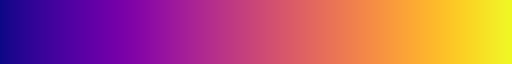

under

bad

over

```python
plt.cm.plasma
```

**tab10**

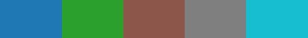

under

bad

over

```python
plt.cm.get_cmap('tab10', 5)
```

**基础函数**

```python
# subplots是最好的画图方式，同时返回fig和ax
fig, ax = plt.subplots(1, 1, figsize=(10, 6))
# 基础参数：linestyle基本是四种，'-', '--', '-.', ':'
# marker有'.', ',', 'o','|', '^', '>','1','2','3','4','8','s','*'
# 颜色可以直接设置任何颜色，比如color='#008080'
# 一个比较好看的plot，linestyle, marker, color, lw是必须的参数
plt.plot([1,2,3], [2,3,4], linestyle='--', color='g',  marker='o',label="test")
plt.plot(df.index, df['equity_curve'], label='equity_curve', linewidth=1, color='k', alpha=0.3)
plt.plot(best_cv_score[0],'-o',label = 'Best cv 5 folds score',color = 'violet',lw = 1,markersize = 5)
plt.plot(cum_profit[0],'-o',label = 'Profit & Loss (bps)',lw = 1,markersize = 3)
# 自定义颜色遍历
color_ = ['r','orange','y','g','b']
for index,key in enumerate(pip.keys):
    plt.plot(np.array(pip.cv_acc_day[key])[0],'-o',label = key,color = color_[index],lw = 1,markersize = 3)
plt.legend(loc=0, fontsize=25) # 画布的不同位置，0是最佳位置，等价于'best'
plt.tick_params(labelsize=25) # 坐标轴字体大小
plt.axhline((y - x).mean(), color="red", linestyle="--") # 画水平线
plt.tight_layout() # 使图片更加紧凑
plt.show()

# sharex和sharey参数，子图共享x轴和y轴，就只用设置一个xlabel或者ylabel
fig, (ax, ax2) = plt.subplots(2, 1, sharex=True, figsize=(12, 9))
plt.subplots_adjust(hspace=0)  # 使图片更加紧凑
ax.plot(df.index, df['equity_curve'], label='equity_curve', linewidth=1, color='k', alpha=0.3)
ax2.plot(df.index, df['equity_curve'], label='equity_curve', linewidth=1, color='k', alpha=0.3)
ax2.set_xlabel('Date', fontsize=25)
ax2.set_ylabel('Equity Curve', fontsize=25)
ax2.tick_params(labelsize=25)
ax2.legend(loc=0, fontsize=25)
ax.set_ylabel('Equity Curve', fontsize=25)
ax.tick_params(labelsize=25)
ax.legend(loc=0, fontsize=25) # legend在画图加了label之后才会显示
ax.set_xticks([0, 250, 500, 750, 1000]) #设置刻度
ax.set_xticklabels(data.index[::40], rotation=30, fontsize='small') #设置刻度对应的值
ax.set_title('This is the title')
ax.set_xlim(['1/1/2007', '1/1/2011'])
ax.set_ylim([600, 2000])
ax.xaxis_date() #设置横轴为时间格式
ax.grid(True) #显示网格线
ax.hlines(2 * sigma, 0, len(mspread), colors='b') #水平线
ax.text(x, y, 'Hello world!', family='monospace', fontsize=10) #图片上加文字
plt.show()

# 实际project中建议一次性打包
ax_params = {
    'title': 'Equity Curve',
    'xlabel': 'Date',
    'ylabel': 'Equity',
    'xticks': [0, 250, 500, 750, 1000],
    'xticklabels': data.index[::40],
    'xlim': ['1/1/2007', '1/1/2011'],
    'ylim': [600, 2000],
    'grid': True,
    'text': (x, y, 'Hello world!', {'family':'monospace', 'fontsize':10})
}
ax.set(**ax_params) # 一次性设置多个参数



# 遍历画法
fig, axes = plt.subplots(2, 2, sharex=True, sharey=True)
for i in range(2):
    for j in range(2):
        axes[i, j].hist(np.random.normal(size=1000), bins=50, color='k', alpha=0.5)
plt.subplots_adjust(wspace=0, hspace=0)
# subplots_adjust参数可以调整子图之间的间距，wspace是宽度，hspace是高度
plt.subplots_adjust(left=None, bottom=None, right=None, top=None, wspace=None, hspace=None)


# 如果是n*1或者1*n，返回一个array of axes，用一个for循环加上ax[i]就可以画图
fig, axs = plt.subplots(len(explain_matrices), 1, figsize=(20, 12))
for i,matrix in enumerate(explain_matrices):
    axs[i].set_title(f'Fold{i} Explain Matrix for First 150 Instances')
    sns.heatmap(matrix[:150], ax=axs[i])
plt.tight_layout()
plt.close()

# 如果是二维的，就用ax[i][j]来画图，或者flatten之后用axs[i]来画图
fig, axs = plt.subplots(5, 2, figsize=(16,16))
axs = axs.flatten() # 展平
k = -1
for i, (mask, j) in enumerate(zip(masks_ , axs)):
    sns.heatmap(mask[:150], ax=j)
    if i%2 == 0:
        k+=1
    j.set_title((f"Fold{k} Mask for First 150 Instances"))
plt.tight_layout()
plt.close()

# savefig保存文件，可以保存成png，pdf，webp等各种格式，以及调整分辨率
# 注意一般dpi=300-500就够了，另外如果不想保存空白边缘，可以加上bbox_inches='tight'，非常常用
plt.savefig('./results/arbitrage.png', dpi=300, bbox_inches='tight')
plt.savefig('./results/arbitrage.pdf', bbox_inches='tight')


### twinx创建右轴对象
# twinx生成的就是一个AxesSubplot对象，因此下面的各种方法和ax的plot是一样的
fig, ax1 = plt.subplots(figsize=[6,4])
ax2 = ax1.twinx() # twinx表示共用x轴，twiny表示共用y轴
# 或者
# ax2 = plt.twinx()
ax2.plot(df['date'], df['equity_curve'], 'y', label='curve(right)', linewidth=1)
ax2.legend(loc=1, fontsize=25)
ax2.tick_params(labelsize=25)
plt.show()
```

**Pandas直接画图**

```python
### series plot
s = pd.Series(np.random.randn(10).cumsum(), index=np.arange(0, 100, 10))
s.plot(color='#cc0000',rot=45, label='...', datetime_format='%Y-%m-%d') #直接series的plot就会把index作为横坐标画进去。默认直接plot是线形图。
s.plot.bar(logy=True) #对数标尺下，纵坐标就会变成什么10^11这类的东西，可以缩小柱状图的一个scale差别。
s.plot.hbar(color='k',alpha=0.7) #此时，index将变成柱状图的刻度，参数基本都一致
s.plot.hist(bins=50)
s.plot.density()
```

该Series对象的索引会被传给matplotlib，并用以绘制X轴。可以通过use_index=False禁用该功能。X轴的刻度和界限可以通过xticks和xlim选项进行调节，Y轴就用yticks和ylim。pandas的大部分绘图方法都有一个可选的ax参数，它可以是一个matplotlib的subplot对象。这使你能够在网格布局中更为灵活地处理subplot的位置。plot参数的完整列表参见下表。

| series的plot参数 | 说明 |
| --- | --- |
| label | 用于图例的标签 |
| ax | 要在其上进行绘制的matplotlib subplot对象。如果没有设置，默认使用当前的 |
| style | 将要传给matplotlib的风格字符串（如'ko--'） |
| alpha | 图表的填充不透明度（0到1之间） |
| kind | 可以是'line', 'bar', 'barh', 'kde' |
| logy | 在Y轴上使用对数标尺 |
| use_index | 将对象的索引用作刻度标签 |
| rot | 旋转刻度标签（0到360） |
| xticks | 用作X轴刻度的值 |
| yticks | 用作Y轴刻度的值 |
| xlim | X轴的界限（例如[0, 10]） |
| ylim | Y轴的界限 |
| grid | 显示轴网格线（默认打开） |

```python
### dataframe plot
df.plot(x='trade_date', y='close', style='y-', grid=True, ax=ax) #dataframe直接plot会每列画个图，横坐标是index，dataframe直接plot比series直接plot的参数多一点，比如可以决定是所有线一起plot还是分别plot。常常用在比如每列是不同时间段的均线，然后直接plot就不用再慢慢的添加画布然后再画到一张图上了。所以可以提前把想画的序列全部放到一个dataframe里面。当然如果指明了x和y的列名，那么x就是横坐标，y就是纵坐标，y可以是一个list画很多折线图。

#以下两种画多层折线图的方法等价：
data[['Close', 'SMA_talib', 'EMA_talib', 'MOM_talib']].plot(ax=ax,legend=True, grid=True)
data.plot(x=data.index, y=['Close', 'SMA_talib', 'EMA_talib', 'MOM_talib'], grid=True, ax=ax, sharex=True)
#当然我忘记了第二个是两个方括号还是一个方括号了。。。

ax = train.plot(x='trade_date', y='close', style='b-', grid=True) #这就是指明行和列，不指明默认x是index
ax = cv.plot(x='trade_date', y='close', style='y-', grid=True, ax=ax)
ax = test.plot(x='trade_date', y='close', style='g-', grid=True, ax=ax)

df.plot.bar() #画出的就是每行索引为刻度下，纵索引数值的分布柱状图
df.plot.barh(color='k',alpha=0.7, stacked=True) #垂直柱状图，stack参数可以画出堆积柱状图！只有dataframe可以。
df.plot.hist(bins=50)
df.plot.density()
df.plot(kind='scatter', x='x', y='roe') #可以指明x，y，上面已经说过了，然后选择kind，dataframe画散点图只能指明kind，尅有df.plot.scatter的东西。其他的哪几种都可以指明kind，跟stata一样方便。kind有line, bar, barh, hist, box, kde, density, area, pie, scatter, hexbin几种。
```

| dataframe的plot参数 | 说明 |
| --- | --- |
| subplots | subplots=True代表将各个DataFrame列绘制到单独的subplot中 |
| sharex | 如果subplots=True，则共用同一个X轴，包括刻度和界限 |
| sharey | 如果subplots=True，则共用同一个Y轴 |
| figsize | 表示图像大小的元组 |
| title | 表示图像标题的字符串 |
| legend | 添加一个subplot图例（默认为True） |
| sort_columns | 以字母表顺序绘制各列，默认使用当前列顺序 |
| kind | 选择line, bar, barh, hist, box, kde, area, scatter, pie, hexbin |
| grid | 网格线 |
| logx, logy | 设置x、y轴是否使用对数指标 |
| xticks, yticks | 接受list，设置x，y轴刻度 |
| xlim，ylim | 接受元组形式，规定x、y轴范围 |
| colormap | str or matplotlib colormap object, default None 设置图的区域颜色，很炫酷，比如'RdYlGn'，'cool' |
| colorbar | If True, plot colorbar，色柱，只对kind为‘scatter’和‘hexbin’有效 |

**各类案例**

```python
# 小案例：github的ML-HFT的画图，自定义颜色，简单for循环，但是完整的配置了颜色，lw，markersize，label等参数，也很好看
sns.set_style("whitegrid")
plt.figure(figsize = (15,6))
color_ = ['r','orange','y','g','b']
for index,key in enumerate(pip.keys):
    plt.plot(np.array(pip.cv_acc_day[key])[0],'-o',label = key,color = color_[index],lw = 1,markersize = 3)
#plot(best_cv_score,'-v',label = 'Best cv 5 folds score',color = 'violet',lw = 1,markersize = 6)
plt.legend(loc = 0)
plt.xlabel('Rolling Window Numbers',size = 15)
plt.ylabel('CV Mean Accuracy',size = 15)
plt.savefig("./images/CV_result.png", dpi = 800)
plt.show()

# 案例：acorr自相关图，xcorr互相关图
x, y = np.random.randn(2, 100)
plt.style.use('seaborn-darkgrid')
fig = plt.figure(figsize=(10, 8))
ax1 = fig.add_subplot(211)
ax1.xcorr(x, y, usevlines=True, maxlags=50, normed=True, lw=2, color='royalblue')
ax1.grid(True, linestyle='--', linewidth=0.5)
ax1.axhline(0, color="grey", lw=1) # 修改为更细的灰色线
ax1.set_title('Cross-correlation between two signals', fontsize=14, fontweight='bold')
ax1.set_ylabel('Cross-correlation', fontsize=12)

ax2 = fig.add_subplot(212, sharex=ax1) # sharex参数共用x轴
ax2.acorr(x, usevlines=True, normed=True, maxlags=50, lw=2, color='darkorange')
ax2.grid(True, linestyle='--', linewidth=0.5)
ax2.axhline(0, color="grey", lw=1) # 修改为更细的灰色线
ax2.set_title('Autocorrelation of signal x', fontsize=14, fontweight='bold')
ax2.set_xlabel('Lag', fontsize=12)
ax2.set_ylabel('Autocorrelation', fontsize=12)

plt.tight_layout()
plt.show()

# 案例：efficient frontier，散点热力柱图
# 一般colorbar只对scatter和hexbin有效，dataframe的plot也有这个参数
plt.style.use('seaborn-dark')
plt.figure(figsize=(9, 5))
# 多种画法，中间的支持cmap参数
plt.scatter(calculated_std, given_ret, color='#660066',alpha=0.7, linewidths=0.5, edgecolors='#680808')
plt.scatter(calculated_std, given_ret, c=sharpe_ratio, cmap='RdYlGn', alpha=0.7, edgecolors='black',marker='o')
plt.scatter(stds, rets, c=sharpe_ratio,cmap='cool', alpha=0.4, edgecolors='blue', marker='o')
plt.plot(calculated_std, given_ret, color='#680808',alpha=0.7, linewidth=2.5, linestyle='dashdot')
plt.plot(stds, rets, color='#660066', linestyle='dashdot') #把点用线连起来，连成一整个区域
plt.colorbar() # 画颜色条

# 案例：contour plot
x1_con = np.linspace(-10,10,1000)
x2_con = np.linspace(-2,2,1000)
x1_mes, x2_mes = np.meshgrid(x1_con,x2_con)
y_con = f(x1_mes,x2_mes)
plt.plot(x1_mes, x2_mes)
plt.contour(x1_mes,x2_mes,y_con,colors='#006600') #contour依次传入x1，x2，y就可以产生等值云图
plt.show()

# 案例：2d直方图
# 准确来说，这虽然是热力图的样式，但不属于热力图。正常的热力图是横纵坐标两个指标，然后热力值为对应参数下的某个指标值
# 但这里不属于heatmap，所以我们也没有用seaborn的heatmap去画，因为这实际上还是一个直方图，还是一个histgram，只不过是二维的，而碰巧二维的histogram和heatmap很像
# 具体来说，使用的是hist2d的函数，而且不用指标值，只用横纵坐标，这里横纵坐标分别是一系列连续型的经度维度值，然后对应那个点的颜色深浅就是对应横纵坐标下的frequency，而不是什么新的指标值。如果有一个小范围内的经度纬度矩形内有大量的数据点，那么对应的颜色就会很深
plt.figure(figsize=(12, 8))
plt.hist2d(df['start_lng'], df['start_lat'],
           bins=[np.arange(116.21, 116.55, 0.005),
                 np.arange(39.76, 40.03, 0.005)])
plt.colorbar() # 画颜色条
plt.savefig("./figures/heatmap_start.png", dpi=600)
plt.show()

# 案例：画金融危机并添加注释
fig = plt.figure()
ax = fig.add_subplot(1, 1, 1)
import pandas as pd
data = pd.read_csv('./examples/stock_px.csv', index_col=0, parse_dates=True)
from datetime import datetime
spx = data['SPX']
spx.plot(ax=ax, style='k-') #直接对series对象进行plot，可以apx.plot(), 指明ax是画到画布上，方便下面调参。
crisis_data = [
    (datetime(2007, 10, 11), 'Peak of bull market'),
    (datetime(2008, 3, 12), 'Bear Stearns Fails'),
    (datetime(2008, 9, 15), 'Lehman Bankruptcy')
]
for date, label in crisis_data:
    ax.annotate(s=label, xy=(date, spx.asof(date) + 75), #asof在pandas里面用于自动取对应横坐标的纵坐标数值。
                xytext=(date, spx.asof(date) + 225),
                arrowprops=dict(facecolor='black', headwidth=4, width=2,
                                headlength=4),
                horizontalalignment='left', verticalalignment='up')
ax.set_xlim(['1/1/2007', '1/1/2011'])
ax.set_ylim([600, 2000])
ax.set_title('Important dates in the 2008-2009 financial crisis')
```

```python
### 案例：自定义colormap，画清晰的颜色渐变的折线图
from matplotlib.colors import LinearSegmentedColormap

colors = ["#b2dfdb", "#66c2a4", "#238b45", "#005824"] # 这是一系列的渐变绿色，由浅到深
teal_cmap = LinearSegmentedColormap.from_list("TealCmap", colors)

# Task 1: Bar plot of daily P&L
daily_pnl = df.groupby('date')['pnl$'].sum()
plt.figure(figsize=(10, 6))
daily_pnl.plot(kind='bar', color='skyblue') # skyblue是一个很好看的浅蓝色
plt.title('Daily P&L')
plt.xlabel('Date')
plt.ylabel('P&L')
plt.xticks(rotation=45)
plt.tight_layout()
plt.show()

# Task 2: Line plot of cumulative daily P&L
cumulative_pnl = daily_pnl.cumsum()
plt.figure(figsize=(10, 6))
cumulative_pnl.plot(color=colors[-1])  # colors[-1]是最深的绿色
plt.title('Cumulative Daily P&L')
plt.xlabel('Date')
plt.ylabel('Cumulative P&L')
plt.xticks(rotation=45)
plt.tight_layout()
plt.show()

# Task 3: Multiple line plot of cumulative daily drawdown by portfolio
drawdown_df = df.pivot_table(index='date', columns='portfolio', values='pnl$', aggfunc='sum').cumsum()
drawdown_df.plot(figsize=(10, 6), colormap=teal_cmap) # 自定义的颜色渐变
plt.title('Cumulative Daily Drawdown by Portfolio')
plt.xlabel('Date')
plt.ylabel('Cumulative Drawdown')
plt.xticks(rotation=45)
plt.legend(title='Portfolio')
plt.tight_layout()
plt.show()

# Task 4: Stacked area chart of daily exposure by market
exposure_df = df.pivot_table(index='date', columns='market', values='exposure$', aggfunc='sum')
exposure_df.plot(kind='area', stacked=True, colormap=teal_cmap) # stack堆叠图
plt.title('Daily Exposure by Market')
plt.xlabel('Date')
plt.ylabel('Exposure')
plt.xticks(rotation=45)
plt.legend(title='Market')
plt.tight_layout()
plt.show()
```

```python
### 案例：可视化训练过程和一个rolling mean同时加上各种坐标标注的过程，来自andrew的RL notebook

import matplotlib.ticker as mticker

def plot_history(reward_history, rolling_window=20, lower_limit=None,
                 upper_limit=None, plot_rw=True, plot_rm=True):

    if lower_limit is None or upper_limit is None:
        rh = reward_history
        xs = [x for x in range(len(reward_history))]
    else:
        rh = reward_history[lower_limit:upper_limit]
        xs = [x for x in range(lower_limit,upper_limit)]

    df = pd.DataFrame(rh)
    rollingMean = df.rolling(rolling_window).mean()

    plt.figure(figsize=(10,7), facecolor='white')

    if plot_rw:
        plt.plot(xs, rh, linewidth=1, color='cyan')
    if plot_rm:
        plt.plot(xs, rollingMean.to_numpy(), linewidth=2, color='magenta')

    text_color = 'black'

    ax = plt.gca()
    ax.set_facecolor('black')
    plt.grid()
#     plt.title("Total Point History", color=text_color, fontsize=40)
    plt.xlabel('Episode', color=text_color, fontsize=30)
    plt.ylabel('Total Points', color=text_color, fontsize=30)
    yNumFmt = mticker.StrMethodFormatter('{x:,}')
    ax.yaxis.set_major_formatter(yNumFmt)
    ax.tick_params(axis='x', colors=text_color)
    ax.tick_params(axis='y', colors=text_color)
    plt.show()
```

```python
### 案例：时间序列预测，原始序列和预测画在一起

# 核心：提前定义一个画图参数字典，后面每个series plot都能用上
# 多个图画到一个画布，最简单的方法第一个df.plot得到ax，然后后面的都用ax = df.plot(ax=ax)，相当于传入ax再返回ax即可
# 最后要调整的话，直接用ax.set，ax.legend，ax.set_title等等

plot_params = dict(
    color="0.75",
    style=".-",
    markeredgecolor="0.25",
    markerfacecolor="0.25",
    legend=False,
)

from statsmodels.tsa.deterministic import DeterministicProcess
n_periods = 100
time_index = pd.date_range(start='2020-01-01', periods=n_periods, freq='D')
series = np.random.randn(n_periods).cumsum()
# index是要做变换的基础时序，order代表阶数
dp = DeterministicProcess(
    index=series.index,  # dates from the training data
    constant=True,       # dummy feature for the bias (y_intercept)
    order=1,             # the time dummy (trend)
    drop=True,           # drop terms if necessary to avoid collinearity
)
# in_sample函数返回一个dataframe，根据index指定的列生成要求的特征，一列叫const，一列叫trend
X = dp.in_sample()
# 上面有constant=True这里就不用加常数项了
# X = sm.add_constant(X) #加上常数项
model = sm.OLS(series, X)
results = model.fit()
results.summary()
# 同样，如果上面有constant=True，要用sklearn的回归，就要指明fit_intercept=False
from sklearn.linear_model import LinearRegression
y = df["NumVehicles"]  # the target
model = LinearRegression(fit_intercept=False)
model.fit(X, y)
y_pred = pd.Series(model.predict(X), index=X.index)

# out_of_sample生成预测
X = dp.out_of_sample(steps=30)
y_fore = pd.Series(model.predict(X), index=X.index)
y_fore.head()
ax = df["2005-05":].plot(title="Tunnel Traffic - Linear Trend Forecast", **plot_params)
ax = y_pred["2005-05":].plot(ax=ax, linewidth=3, label="Trend")
ax = y_fore.plot(ax=ax, linewidth=3, label="Trend Forecast", color="C3")
_ = ax.legend()
ax.set(title="US Food and Beverage Sales", ylabel="Millions of Dollars")
```

```python
### 案例：时间序列周期图periodogram，seasonal plot，预测图

plt.style.use("seaborn-whitegrid")
plt.rc("figure", autolayout=True, figsize=(11, 5))
plt.rc(
    "axes",
    labelweight="bold",
    labelsize="large",
    titleweight="bold",
    titlesize=16,
    titlepad=10,
)
plot_params = dict(
    color="0.75",
    style=".-",
    markeredgecolor="0.25",
    markerfacecolor="0.25",
    legend=False,
)

def seasonal_plot(X, y, period, freq, ax=None):
    if ax is None:
        _, ax = plt.subplots()
    palette = sns.color_palette("husl", n_colors=X[period].nunique(),)
    ax = sns.lineplot(
        x=freq,
        y=y,
        hue=period,
        data=X,
        ci=False,
        ax=ax,
        palette=palette,
        legend=False,
    )
    ax.set_title(f"Seasonal Plot ({period}/{freq})")
    for line, name in zip(ax.lines, X[period].unique()):
        y_ = line.get_ydata()[-1]
        ax.annotate(
            name,
            xy=(1, y_),
            xytext=(6, 0),
            color=line.get_color(),
            xycoords=ax.get_yaxis_transform(),
            textcoords="offset points",
            size=14,
            va="center",
        )
    return ax


def plot_periodogram(ts, detrend='linear', ax=None):
    from scipy.signal import periodogram
    fs = pd.Timedelta("365D") / pd.Timedelta("1D")
    freqencies, spectrum = periodogram(
        ts,
        fs=fs,
        detrend=detrend,
        window="boxcar",
        scaling='spectrum',
    )
    if ax is None:
        _, ax = plt.subplots()
    ax.step(freqencies, spectrum, color="purple")
    ax.set_xscale("log")
    ax.set_xticks([1, 2, 4, 6, 12, 26, 52, 104])
    ax.set_xticklabels(
        [
            "Annual (1)",
            "Semiannual (2)",
            "Quarterly (4)",
            "Bimonthly (6)",
            "Monthly (12)",
            "Biweekly (26)",
            "Weekly (52)",
            "Semiweekly (104)",
        ],
        rotation=30,
    )
    ax.ticklabel_format(axis="y", style="sci", scilimits=(0, 0))
    ax.set_ylabel("Variance")
    ax.set_title("Periodogram")
    return ax

X = df.copy()

# days within a week
X["day"] = X.index.dayofweek  # the x-axis (freq)
X["week"] = X.index.week  # the seasonal period (period)

# days within a year
X["dayofyear"] = X.index.dayofyear
X["year"] = X.index.year
fig, (ax0, ax1) = plt.subplots(2, 1, figsize=(11, 6))
# freq对应的列是x轴，period对应的列是hue
seasonal_plot(X, y="NumVehicles", period="week", freq="day", ax=ax0)
seasonal_plot(X, y="NumVehicles", period="year", freq="dayofyear", ax=ax1)

plot_periodogram(df.NumVehicles)

# 预测图，和上一个案例类似
from sklearn.linear_model import LinearRegression
from statsmodels.tsa.deterministic import CalendarFourier, DeterministicProcess

fourier = CalendarFourier(freq="A", order=10)  # 10 sin/cos pairs for "A"nnual seasonality

dp = DeterministicProcess(
    index=df.index,
    constant=True,               # dummy feature for bias (y-intercept)
    order=1,                     # trend (order 1 means linear)
    seasonal=True,               # weekly seasonality (indicators)
    additional_terms=[fourier],  # annual seasonality (fourier)
    drop=True,                   # drop terms to avoid collinearity
)

X = dp.in_sample()  # create features for dates in tunnel.index
y = df["NumVehicles"]
model = LinearRegression(fit_intercept=False)
_ = model.fit(X, y)
y_pred = pd.Series(model.predict(X), index=y.index)
X_fore = dp.out_of_sample(steps=90)
y_fore = pd.Series(model.predict(X_fore), index=X_fore.index)

ax = y.plot(color='0.25', style='.', title="Tunnel Traffic - Seasonal Forecast")
ax = y_pred.plot(ax=ax, label="Seasonal")
ax = y_fore.plot(ax=ax, label="Seasonal Forecast", color='C3')
_ = ax.legend()
```

```python
### 案例：时序lagplot
# Set Matplotlib defaults
from statsmodels.graphics.tsaplots import plot_pacf
from scipy.signal import periodogram

plt.style.use("seaborn-whitegrid")
plt.rc("figure", autolayout=True, figsize=(11, 4))
plt.rc(
    "axes",
    labelweight="bold",
    labelsize="large",
    titleweight="bold",
    titlesize=16,
    titlepad=10,
)
plot_params = dict(
    color="0.75",
    style=".-",
    markeredgecolor="0.25",
    markerfacecolor="0.25",
)

def lagplot(x, y=None, lag=1, standardize=False, ax=None, **kwargs):
    from matplotlib.offsetbox import AnchoredText
    x_ = x.shift(lag)
    if standardize:
        x_ = (x_ - x_.mean()) / x_.std()
    if y is not None:
        y_ = (y - y.mean()) / y.std() if standardize else y
    else:
        y_ = x
    corr = y_.corr(x_)
    if ax is None:
        fig, ax = plt.subplots()
    scatter_kws = dict(
        alpha=0.75,
        s=3,
    )
    line_kws = dict(color='C3', )
    ax = sns.regplot(x=x_,
                     y=y_,
                     scatter_kws=scatter_kws,
                     line_kws=line_kws,
                     lowess=True,
                     ax=ax,
                     **kwargs)
    at = AnchoredText(
        f"{corr:.2f}",
        prop=dict(size="large"),
        frameon=True,
        loc="upper left",
    )
    at.patch.set_boxstyle("square, pad=0.0")
    ax.add_artist(at)
    ax.set(title=f"Lag {lag}", xlabel=x_.name, ylabel=y_.name)
    return ax

# 非常好用，能画出一系列的lag图，然后每个图的title是lag的数字
def plot_lags(x,
              y=None,
              lags=6,
              leads=None,
              nrows=1,
              lagplot_kwargs={},
              **kwargs):
    import math
    kwargs.setdefault('nrows', nrows)
    orig = leads is not None
    leads = leads or 0
    kwargs.setdefault('ncols', math.ceil((lags + orig + leads) / nrows))
    kwargs.setdefault('figsize', (kwargs['ncols'] * 2, nrows * 2 + 0.5))
    fig, axs = plt.subplots(sharex=True, sharey=True, squeeze=False, **kwargs)
    for ax, k in zip(fig.get_axes(), range(kwargs['nrows'] * kwargs['ncols'])):
        k -= leads + orig
        if k + 1 <= lags:
            ax = lagplot(x, y, shift=k + 1, ax=ax, **lagplot_kwargs)
            title = f"Lag {k + 1}" if k + 1 >= 0 else f"Lead {-k - 1}"
            ax.set_title(title, fontdict=dict(fontsize=14))
            ax.set(xlabel="", ylabel="")
        else:
            ax.axis('off')
    plt.setp(axs[-1, :], xlabel=x.name)
    plt.setp(axs[:, 0], ylabel=y.name if y is not None else x.name)
    fig.tight_layout(w_pad=0.1, h_pad=0.1)
    return fig

flu_trends = pd.read_csv("flu-trends.csv")

# 画12张lag图，图如果太多记得指定行数
_ = plot_lags(flu_trends.FluVisits, lags=12, nrows=2)
onpromotion = df.loc[:, 'onpromotion'].squeeze().rename('onpromotion')
plot_lags(x=onpromotion.loc[onpromotion > 1], y=y_deseason.loc[onpromotion > 1], lags=3, leads=3, nrows=1)

# 内置PACF会用阴影表示95%置信区间，超出就选择这个lag
_ = plot_pacf(flu_trends.FluVisits, lags=12)

# 默认对target y做lag
def make_lags(ts, lags, lead_time=1, name='y'):
    return pd.concat(
        {
            f'{name}_lag_{i}': ts.shift(i)
            for i in range(lead_time, lags + lead_time)
        },
        axis=1)

def make_leads(ts, leads, name='y'):
    return pd.concat(
        {f'{name}_lead_{i}': ts.shift(-i)
         for i in reversed(range(leads))},
        axis=1)

X = make_lags(flu_trends.FluVisits, lags=4)
X = X.fillna(0.0)

# Create target series and data splits
# 时间序列所以必须shuffle=False
y = flu_trends.FluVisits.copy()
X_train, X_test, y_train, y_test = train_test_split(X, y, test_size=60, shuffle=False)

# Fit and predict
model = LinearRegression()  # `fit_intercept=True` since we didn't use DeterministicProcess
model.fit(X_train, y_train)
y_pred = pd.Series(model.predict(X_train), index=y_train.index)
y_fore = pd.Series(model.predict(X_test), index=y_test.index)
ax = y_train.plot(**plot_params)
ax = y_test.plot(**plot_params)
ax = y_pred.plot(ax=ax)
_ = y_fore.plot(ax=ax, color='C3')

# 进一步plot，发现存在滞后一步的问题
ax = y_test.plot(**plot_params)
_ = y_fore.plot(ax=ax, color='C3')

# dataframe去plot两个轴的方法，来看是否趋势一致，可以当leading indicator
ax = flu_trends.plot(
    y=["FluCough", "FluVisits"],
    secondary_y="FluCough",
)

# 添加leading indicator，做lag特征，然后再做预测
search_terms = ["FluContagious", "FluCough", "FluFever", "InfluenzaA", "TreatFlu", "IHaveTheFlu", "OverTheCounterFlu", "HowLongFlu"]

# Create three lags for each search term
X0 = make_lags(flu_trends[search_terms], lags=3)
X0.columns = [' '.join(col).strip() for col in X0.columns.values]

# Create four lags for the target, as before
X1 = make_lags(flu_trends['FluVisits'], lags=4)

# Combine to create the training data
X = pd.concat([X0, X1], axis=1).fillna(0.0)

X_train, X_test, y_train, y_test = train_test_split(X, y, test_size=60, shuffle=False)

model = LinearRegression()
model.fit(X_train, y_train)
y_pred = pd.Series(model.predict(X_train), index=y_train.index)
y_fore = pd.Series(model.predict(X_test), index=y_test.index)

ax = y_test.plot(**plot_params)
_ = y_fore.plot(ax=ax, color='C3')
```

```python
def plot_multistep(y, every=1, ax=None, palette_kwargs=None):
    palette_kwargs_ = dict(palette='husl', n_colors=16, desat=None)
    if palette_kwargs is not None:
        palette_kwargs_.update(palette_kwargs)
    palette = sns.color_palette(**palette_kwargs_)
    if ax is None:
        fig, ax = plt.subplots()
    ax.set_prop_cycle(plt.cycler('color', palette))
    for date, preds in y[::every].iterrows():
        preds.index = pd.period_range(start=date, periods=len(preds))
        preds.plot(ax=ax)
    return ax

def make_lags(ts, lags, lead_time=1):
    return pd.concat(
        {
            f'y_lag_{i}': ts.shift(i)
            for i in range(lead_time, lags + lead_time)
        },
        axis=1)

# Four weeks of lag features
y = flu_trends.FluVisits.copy()
X = make_lags(y, lags=4).fillna(0.0)


def make_multistep_target(ts, steps):
    return pd.concat(
        {f'y_step_{i + 1}': ts.shift(-i)
         for i in range(steps)},
        axis=1)

# lag特征没有的可以填0可以drop，但target的未来值没有直接drop
# Eight-week forecast
y = make_multistep_target(y, steps=8).dropna()

# Shifting has created indexes that don't match. Only keep times for
# which we have both targets and features.
y, X = y.align(X, join='inner', axis=0)

# Create splits
X_train, X_test, y_train, y_test = train_test_split(X, y, test_size=0.25, shuffle=False)

model = LinearRegression()
model.fit(X_train, y_train)

y_fit = pd.DataFrame(model.predict(X_train), index=X_train.index, columns=y.columns)
y_pred = pd.DataFrame(model.predict(X_test), index=X_test.index, columns=y.columns)

train_rmse = mean_squared_error(y_train, y_fit, squared=False)
test_rmse = mean_squared_error(y_test, y_pred, squared=False)
print((f"Train RMSE: {train_rmse:.2f}\n" f"Test RMSE: {test_rmse:.2f}"))

palette = dict(palette='husl', n_colors=64)
fig, (ax1, ax2) = plt.subplots(2, 1, figsize=(11, 6))
ax1 = flu_trends.FluVisits[y_fit.index].plot(**plot_params, ax=ax1)
ax1 = plot_multistep(y_fit, ax=ax1, palette_kwargs=palette)
_ = ax1.legend(['FluVisits (train)', 'Forecast'])
ax2 = flu_trends.FluVisits[y_pred.index].plot(**plot_params, ax=ax2)
ax2 = plot_multistep(y_pred, ax=ax2, palette_kwargs=palette)
_ = ax2.legend(['FluVisits (test)', 'Forecast'])
```

```python
### 案例：绘制资金曲线
def draw_equity_curve_mat(df, data_dict, date_col=None, right_axis=None, pic_size=[16, 9], font_size=25,
                          log=False, chg=False, title=None, y_label='净值'):
    """
    :param df: 包含净值数据的df
    :param data_dict: 要展示的数据字典格式：｛图片上显示的名字:df中的列名｝
    :param date_col: 时间列的名字，如果为None将用索引作为时间列
    :param right_axis: 右轴数据 ｛图片上显示的名字:df中的列名｝
    :param pic_size: 图片的尺寸
    :param font_size: 字体大小
    :param chg: datadict中的数据是否为涨跌幅，True表示涨跌幅，False表示净值
    :param log: 是都要算对数收益率
    :param title: 标题
    :param y_label: Y轴的标签
    :return:
    """
    # 复制数据
    draw_df = df.copy()
    # 模块基础设置
    # 字体设置，是一个list，如果能找到第一个微软雅黑就不找第二个，第二个是苹果自带字体
    plt.rcParams['font.sans-serif'] = ['SimHei', 'Arial Unicode MS']  # 定义使用的字体，是个数组。
    # 是否显示负数
    plt.rcParams['axes.unicode_minus'] = False
    # matplotlib的style调整，很多的style
    # plt.style.use('dark_background')

    plt.figure(figsize=(pic_size[0], pic_size[1]))
    # 获取时间轴
    if date_col:
        time_data = draw_df[date_col]
    else:
        time_data = draw_df.index
    # 绘制左轴数据
    for key in data_dict:
        if chg:
            draw_df[data_dict[key]] = (draw_df[data_dict[key]] + 1).fillna(1).cumprod()
        if log:
            draw_df[data_dict[key]] = np.log(draw_df[data_dict[key]].apply(float))
        plt.plot(time_data, draw_df[data_dict[key]], linewidth=2, label=str(key))
    # 设置坐标轴信息等
    plt.ylabel(y_label, fontsize=font_size)
    plt.legend(loc=2, fontsize=font_size)
    plt.tick_params(labelsize=font_size)
    plt.grid()
    if title:
        plt.title(title, fontsize=font_size)

    # 绘制右轴数据
    if right_axis:
        # 生成右轴
        ax_r = plt.twinx()
        # 获取数据
        key = list(right_axis.keys())[0]
        ax_r.plot(time_data, draw_df[right_axis[key]], 'y', linewidth=1, label=str(key))
        # 设置坐标轴信息等
        ax_r.set_ylabel(key, fontsize=font_size)
        ax_r.legend(loc=1, fontsize=font_size)
        ax_r.tick_params(labelsize=font_size)
    plt.show()
```

**其他**

```python
# annotate函数加注释
ax.annotate(s='some texts', xy=(datetime(2021,5,27), spx.asof(datetime(2021,5,27)) + 75), #asof在pandas里面用于自动取对应横坐标的纵坐标数值。
            xytext=(date, spx.asof(date) + 225),
            arrowprops=dict(facecolor='black', headwidth=4, width=2,
                            headlength=4),
            horizontalalignment='left', verticalalignment='top')
    # 第一个参数s=label代表我们要注释的内容
    # xy：箭头指向的位置
    # asof函数用来取对应date这个横坐标点的标普500值，如果刚好这个点对应的值是NaN
    # 那么就会给出这个值之前最近一个不是NaN的值，这样确保了我们的x和y坐标都是有效的数字
    # xytext：注释的文字所处的位置
    # arrowprops：箭头的风格和种类
    # horizontalalignment控制X方向上，文本位于左右还是居中显示
    # verticalalignment则是控制y方向上，文本位于上下还是居中显示

### set_major_formatter：matplotlib时间格式修正
# 经常x轴时间轴要么就是排布太密集，要么没识别时间格式，出来乱七八糟
from matplotlib.dates import date2num, DateFormatter
ax.set_xticks(range(0, len(data.index), 40)) #设置刻度，这里40步长
ax.set_xticklabels(data.index[::40]) #设置刻度对应的值
ax.xaxis.set_major_formatter(DateFormatter("%Y-%m-%d"))  # 格式化X轴的时间，使用dateformatter
```

**使用ipywidgets在Jupyter notebook搭建交互式matplotlib**

```python
import ipywidgets as widgets
output = widgets.Output()
# create some x data
x = np.linspace(0, 2 * np.pi, 100)
# default line color
initial_color = '#FF00DD'
def draw(freq: int, color: str):
    global output
    with output:
        y = np.sin(freq * x)
        plt.plot(x, y, color=color)
        output.clear_output() # remove the output created last time
        plt.show()

# create some control elements
int_slider = widgets.IntSlider(value=1, min=0, max=10, step=1, description='freq')
color_picker = widgets.ColorPicker(value=initial_color, description='pick a color')
# callback functions
def update(change):
    """redraw line (update plot)"""
    global color_picker
    draw(change.new, color_picker.value)

def line_color(change):
    """set line color"""
    global int_slider
    draw(int_slider.value, change.new)

# connect callbacks and traits
int_slider.observe(update, 'value')
color_picker.observe(line_color, 'value')
draw(int_slider.value, color_picker.value)
widgets.VBox([int_slider, color_picker, output])
```

### **Seaborn**

**初始设置**

```python
import seaborn as sns

# 设置字体，便于类似confusion matrix的数字显示均匀
# set方法已经废弃，用set_theme
# set_theme相对于set_style，提供更加全面的图形样式配置，包括风格，颜色和字体等，而style只是整体的图形背景和网格线样式
# 已有的风格五种：white, dark, whitegrid, darkgrid, ticks
sns.set_theme(style="whitegrid", palette='muted', font_scale=1.2)
sns.set_theme(style="darkgrid", palette="pastel", font_scale=1.1)

# 前面是配置图形样式，set_palette专门定义图中主要线条、点的颜色
# 已有的颜色主题：deep, muted, bright, pastel, dark, colorblind
sns.set_palette("pastel")

# 自定义调色板
HAPPY_COLORS_PALETTE = ["#01BEFE", "#FFDD00", "#FF7D00", "#FF006D", "#93D30C", "#8F00FF"]
sns.set_palette(sns.color_palette(HAPPY_COLORS_PALETTE))
sns.set_palette(["#9b59b6", "#3498db", "#95a5a6", "#e74c3c", "#34495e", "#2ecc71"])
```

```python
### heatmap vs clustermap
# heatmap：主要根据元素值表现元素深浅
sns.heatmap(1 - pvalues, xticklabels=stock_list, yticklabels=stock_list, cmap='RdYlGn_r', mask=(pvalues == 1))
# 从dataframe画热力度corr matrix，设置好index和col的名字，画图会显示，然后
data = confusion_matrix(testy, yhat_test)
df_cm = pd.DataFrame(data, columns=np.unique(testy), index = np.unique(testy))
df_cm.index.name = 'Actual'
df_cm.columns.name = 'Predicted'
plt.figure(figsize = (12, 10))
# sns.set_theme(font_scale=1.4)#for label size
# fmt='d'是整数，.2f是两位小数
sns.heatmap(df, annot=True, fmt=".2f", cmap="coolwarm", cbar=True, annot_kws={"size": 10}) # 加色条
sns.heatmap(df_cm, cmap="Blues", annot=True, fmt='d', annot_kws={"size": 19}) # 带标记和色条的热力图
sns.heatmap(df_cm, annot=True, fmt='d', annot_kws={"size": 19},yticklabels=[...]) # 指定yticklabels的名字

# clustermap：热力图+hierarchical clustering
# 主要用于探索数据潜在分组或模式，聚类算法会自动重排矩阵的行和列，相似的行和列会被放在一起
sns.clustermap(X_train.corr(), figsize=(5,5))
sns.clustermap(method='single', metric='euclidean', data=df, cmap='Blues', figsize=(10, 10)) #指定聚类方法和距离度量方法
```

```python
### relplot vs lmplot
# relplot：关系图relational plot，可以画散点图，或者折线图
# 功能很强大，支持按照一个或多个分类变量来分层展示更多维度的数据
# 实际原理是使用了FacetGrid，FacetGrid是一个多面板的画布，可以在一个画布上画多个图，每个图都是一个小的facet
# 通过使用FacetGrid来实现多个图的分层展示，只做具有多个面板的图形
tips = sns.load_dataset("tips")
tips.head()
sns.relplot(data=tips, x="total_bill", y="tip", hue="day") # 不同分类下的散点图
sns.relplot(data=tips, x="total_bill", y="tip", hue="day", col="time") # col参数在横向创建多个subplots
# row参数在纵向创建多个subplots，因此sex列有两个值，time列三个值，那就是两行三列的图
sns.relplot(data=tips, x="total_bill", y="tip", hue="day", col="time", row="sex")
# 如果col变量有很多值，那么可以用col_wrap参数来控制每行的图的数量，下面这里就是每行两个图
sns.relplot(data=tips, x="total_bill", y="tip", hue="time", col="day", col_wrap=2)

# 更复杂的情况：size参数可以控制点的大小，style参数可以控制点的形状，palette参数可以控制颜色
# 因此下面图根据time产生subplot，不同time的图不同颜色，每个图中，不同的size用不同的点大小，不同的sex用不同的点形状
sns.relplot(
    data=tips, x="total_bill", y="tip", col="time",
    hue="time", size="size", style="sex",
    palette=["b", "r"], sizes=(10, 100)
)

# 以上都是散点格式，下面是折线图格式
fmri = sns.load_dataset("fmri")
fmri.head()
# 默认情况会返回mean和95%置信区间
sns.relplot(
    data=fmri, x="timepoint", y="signal", col="region",
    hue="event", style="event", kind="line",
)
# 可以自己调大小
sns.relplot(
    data=fmri,
    x="timepoint", y="signal",
    hue="event", style="event", col="region",
    height=4, aspect=.7, kind="line"
)

# 其他的一些例子
sns.relplot(x="curb_weight", y="price", data=df, marker="*")
# 常用手段：把几列通过melt变成一个categorical列，然后用relplot画出来
features = ["YearBuilt", "MoSold", "ScreenPorch"]
sns.relplot(
    x="value", y="SalePrice", col="variable", data=df.melt(id_vars="SalePrice", value_vars=features), facet_kws=dict(sharex=False),
)


g = sns.relplot(
    data=flights,
    x="month", y="passengers", col="year", hue="year",
    kind="line", palette="crest", linewidth=4, zorder=5,
    col_wrap=3, height=2, aspect=1.5, legend=False,
)

sns.set_theme(style="whitegrid")
planets = sns.load_dataset("planets")
cmap = sns.cubehelix_palette(rot=-.2, as_cmap=True)
g = sns.relplot(
    data=planets,
    x="distance", y="orbital_period",
    hue="year", size="mass",
    palette=cmap, sizes=(10, 200),
)
g.set(xscale="log", yscale="log")
g.ax.xaxis.grid(True, "minor", linewidth=.25)
g.ax.yaxis.grid(True, "minor", linewidth=.25)
g.despine(left=True, bottom=True)

# lmplot与regplot：线性回归散点图，等于regplot+FacetGrid
# 点比较多的话就是考虑散点+回归线+置信区间打阴影
sns.lmplot(x="horsepower", y="price", hue="fuel_type", data=df)
sns.set_theme(color_codes=True)
sns.regplot(x='beta', y='cross_return_excess', data=df, marker="*")
sns.lmplot(x='beta', y='cross_return_excess', data=df,x_jitter=.01) #类似
sns.lmplot(x='beta', y='cross_return_excess', data=df,
           order=2, ci=None, scatter_kws={"s": 80}) #二阶拟合
sns.lmplot(x='beta', y='cross_return_excess', data=df,
        order=3, scatter_kws={"s": 80}, x_jitter=.01) #三阶拟合
# 可以考虑seaborn的jointplot，既有主图又有各自的分布放在图的外面，一般是最好看
sns.jointplot(x='beta', y='cross_return_excess', ci=None,data=df, kind='reg')

### scatterplot
sns.scatterplot(data=tips, x="total_bill", y="tip")
sns.scatterplot(data=tips, x="total_bill", y="tip", hue="time")
sns.scatterplot(data=tips, x="total_bill", y="tip", hue="time", style="time") # hue+style双分类，这里hue和style一样，所以两类颜色和点型都不一样
sns.scatterplot(data=tips, x="total_bill", y="tip", hue="day", style="time") # 此时是四类颜色，两类点型
# 如果hue是数值型，那么会自动分类
sns.scatterplot(data=tips, x="total_bill", y="tip", hue="size", palette="deep")
# size参数可以控制点的大小，指定size参数为numeric则会自动根据数值大小调整点的大小
sns.scatterplot(data=tips, x="total_bill", y="tip", hue="size", size="size")
# sizes参数可以控制点的大小范围，legend='full'代表所有unique value都要显示在图例里面
sns.scatterplot(data=tips, x="total_bill", y="tip", hue="size", size="size",sizes=(20, 200), legend="full")

### swarmplot，叫做categorical scatterplot，类别散点图
# 传统散点图是两个numeric特征，swarmplot是一个numeric和一个categorical特征
# 横轴是分类特征，然后纵轴显示数值特征的分布
sns.swarmplot(data=tips, x="day", y="total_bill")
sns.swarmplot(data=tips, x="total_bill", y="day", hue="day", legend=False)
sns.swarmplot(data=tips, x="total_bill", y="day", hue="size") # 同理，hue如果传入数值型，会自动分类
sns.swarmplot(data=tips, x="total_bill", y="day", hue="size", palette="deep")
ns.swarmplot(data=tips, x="total_bill", y="size", orient="h", size=3)


### catplot：categorical plots，类别图
# kind: strip, swarm, box, violin, boxen, point, bar, or count
df = sns.load_dataset("titanic")
# y是类别，默认散点图
sns.catplot(data=df, x="age", y="class")
sns.catplot(data=df, x="age", y="class", kind="box")
sns.catplot(data=df, x="age", y="class", hue="sex", kind="boxen")
sns.catplot(data=df, x="age", y="class", hue="sex", kind="violin", bw_adjust=.5, cut=0, split=True,)
# 和relplot一样，catplot也可以用col和row来分多张图，hue分颜色，height等来调整大小
sns.catplot(data=df, x="class", y="survived", col="sex", kind="bar", height=4, aspect=.6, palette="Blues_d")
sns.catplot(x='day', y='tip_pct', hue='time', col='smoker', kind='bar', data=tips[tips.tip_pct < 1])
sns.catplot(x='day', y='tip_pct', row='time', col='smoker', kind='bar', data=tips[tips.tip_pct < 1])
sns.catplot(x='tip_pct', y='day', kind='box', data=tips[tips.tip_pct < 0.5])


### lineplot
sns.set_theme(style="darkgrid")
fmri = sns.load_dataset("fmri")
# Plot the responses for different events and regions
plt.figure(figsize=(10,6))
# 同理，hue和style都是类别变量，可以分颜色和形状
sns.lineplot(x="timepoint", y="signal", hue="region", style="event", data=fmri)
# 如果传入的x是index
sns.lineplot(x=fmri.index, y="signal", hue="region", style="event", data=fmri)
# markers和dashes控制点和线的样式，err_style和err_kws控制误差线的样式（这里画了error bar）
sns.lineplot(x="timepoint", y="signal", hue="region", style="event",
             data=fmri, markers=True, dashes=False, err_style="bars", err_kws={'capsize': 3, 'elinewidth': 1.5, 'capthick': 1.5})
# 只画局部，可以加label参数
plt.figure(figsize=(14,6))
plt.title("Daily Global Streams of Popular Songs in 2017-2018")
sns.lineplot(data=df['Shape of You'], label="Shape of You")
sns.lineplot(data=df['Despacito'], label="Despacito")
plt.xlabel("Date")


### barplot
plt.figure(figsize=(10,6))
plt.title("Average Arrival Delay for Spirit Airlines Flights, by Month")
sns.barplot(x='day', y='orderid', data=day_num_df)
# 指明hue参数即一列的categorical变量可以实现compare型的多条柱状图
# orient参数可以控制横竖，palette参数可以控制颜色，但x和y记得互换名字
sns.barplot(x='tip_pct', y='day', hue='time', data=tips, palette="Blues_d", orient='h')
plt.ylabel("Arrival delay (in minutes)")
```

```python
### histplot：直方图显示数值型数据的分布
plt.figure(figsize=(10,6))
plt.title("Distribution of Arrival Delay")
sns.histplot(x='tip_pct', data=tips, bins=10, kde=True)
# hue分颜色，multiple代表不同的分布图是做堆叠还是并列，stack代表堆叠（两个直方图堆一起方便对比），dodge代表并列
sns.histplot(x='tip_pct', data=tips, bins=10, kde=True, hue='time', multiple='stack')

### kdeplot
sns.kdeplot(data=tips['tip_pct'], shade=True) # shade代表是否填充颜色，现在已经deprecated，用fill代替
sns.kdeplot(data=tips['tip_pct'], fill=True)
sns.kdeplot(data=iris_data, x='Petal Length (cm)', hue='Species', fill=True)

# joinplot
sns.set_theme(style="darkgrid")
tips = sns.load_dataset("tips")
sns.jointplot(x='total_bill', y="tip", data=tips, kind="kde")
g = sns.jointplot(x="total_bill", y="tip", data=tips, kind="reg", truncate=False,
                  xlim=(0, 60), ylim=(0, 12), color="m", height=7)
```

**画图案例**

```python
# 以下介绍函数的案例都可以直接跑，是document的官方案例

# 聚会规模与小费的一个堆叠柱状图案例
tips = pd.read_csv('examples/tips.csv')
party_counts = pd.crosstab(tips['day'], tips['size']) #crosstab这里相当于取了两列研究他们的tabular关系，一列做为横坐标，另一列作为纵坐标建立面板数据。
# 由于1个人和6个人的情况比较少，去掉
party_counts = party_counts.loc[:, 2:5] #只取size是2到5的，注意这里的pandas的索引似乎包括右边。
print(party_counts)
party_pcts = party_counts.div(party_counts.sum(1), axis=0)  # 对每一行进行归一化
print(party_pcts)
party_pcts.plot.bar() #直接用pandas画图
tips['tip_pct'] = tips['tip'] / (tips['total_bill'] - tips['tip'])
print(tips.head())
sns.barplot(x='tip_pct', y='day', data=tips, orient='h') #用sns画图，好看很多
sns.barplot(x='tip_pct', y='day', hue='time', data=tips, orient='h')
sns.set(style="whitegrid")
tips['tip_pct'].plot.hist(bins=50)
tips['tip_pct'].plot.density()

comp1 = np.random.normal(0, 1, size=200)
comp2 = np.random.normal(10, 2, size=200)
values = pd.Series(np.concatenate([comp1, comp2])) #concatenate把两个series合并起来
sns.distplot(values, bins=100, color='k') #直方图和kernel一并出现

macro = pd.read_csv('examples/macrodata.csv')
data = macro[['cpi', 'm1', 'tbilrate', 'unemp']]
trans_data = np.log(data).diff().dropna() #即取对数，然后做差表示百分比变化，然后丢掉缺失值
print(trans_data[-5:])
sns.regplot('m1', 'unemp', data=trans_data) #regplot就是既有散点，又有回归线，还有置信区间，就是project3东明那个
plt.title('Changes in log %s versus log %s' % ('m1', 'unemp'))
sns.pairplot(trans_data, diag_kind='kde', plot_kws={'alpha': 0.2}) #画散布图矩阵



# distplot属于一种deprecate的用法，但主要目的是对numerical变量画bin加kernel，以便于看出数据分布
sns.distplot(start_end_distance)

# pairplot
# hue对应categorical的列，要求其他的列都是numerical型
# sns的对象本就可以直接savefig，语句一样
pairplot = sns.pairplot(train, hue="Class")
pairplot.savefig("./figures/pairplot.png", dpi=1000)
# 更换flare参数更换可视化，详情见document
pairplot = sns.pairplot(train, hue="Class",palette="flare")
# 内置案例
sns.set_theme(style="ticks")
df = sns.load_dataset("penguins")
sns.pairplot(df, hue="species")

# 如果hue参数不是discrete的class，而是连续型，那画出来是大小和深度不一的散点
# Scatterplot with continuous hues and sizes
sns.set_theme(style="whitegrid")
planets = sns.load_dataset("planets")
cmap = sns.cubehelix_palette(rot=-.2, as_cmap=True)
g = sns.relplot(
    data=planets,
    x="distance", y="orbital_period",
    hue="year", size="mass",
    palette=cmap, sizes=(10, 200),
)
g.set(xscale="log", yscale="log")
g.ax.xaxis.grid(True, "minor", linewidth=.25)
g.ax.yaxis.grid(True, "minor", linewidth=.25)
g.despine(left=True, bottom=True)





# small multiple time series
sns.set_theme(style="dark")
flights = sns.load_dataset("flights")
# Plot each year's time series in its own facet
g = sns.relplot(
    data=flights,
    x="month", y="passengers", col="year", hue="year",
    kind="line", palette="crest", linewidth=4, zorder=5,
    col_wrap=3, height=2, aspect=1.5, legend=False,
)
# Iterate over each subplot to customize further
for year, ax in g.axes_dict.items():
    # Add the title as an annotation within the plot
    ax.text(.8, .85, year, transform=ax.transAxes, fontweight="bold")
    # Plot every year's time series in the background
    sns.lineplot(
        data=flights, x="month", y="passengers", units="year",
        estimator=None, color=".7", linewidth=1, ax=ax,
    )
# Reduce the frequency of the x axis ticks
ax.set_xticks(ax.get_xticks()[::2])
# Tweak the supporting aspects of the plot
g.set_titles("")
g.set_axis_labels("", "Passengers")
g.tight_layout()

# boxplot and stripplot
# seaborn与plt结合的例子，方便控制画布大小，调整x，y轴和一些
sns.set_theme(style="ticks")
# Initialize the figure with a logarithmic x axis
f, ax = plt.subplots(figsize=(9, 6))
ax.set_xscale("log")
# Load the example planets dataset
planets = sns.load_dataset("planets")
# Plot the orbital period with horizontal boxes
sns.boxplot(x="distance", y="method", data=planets,
            whis=[0, 100], width=.6, palette="vlag")
# Add in points to show each observation
sns.stripplot(x="distance", y="method", data=planets,
              size=4, color=".3", linewidth=0)
# Tweak the visual presentation
ax.xaxis.grid(True)
ax.set(ylabel="")
sns.despine(trim=True, left=True)


# countplot
sns.countplot()
```

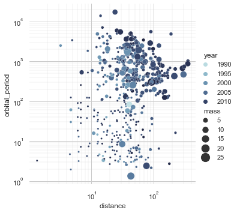

```python
# relplot案例
import seaborn as sns
sns.set_theme(style="whitegrid")
planets = sns.load_dataset("planets")
cmap = sns.cubehelix_palette(rot=-.2, as_cmap=True)
g = sns.relplot(
    data=planets,
    x="distance", y="orbital_period",
    hue="year", size="mass",
    palette=cmap, sizes=(10, 200),
)
g.set(xscale="log", yscale="log")
g.ax.xaxis.grid(True, "minor", linewidth=.25)
g.ax.yaxis.grid(True, "minor", linewidth=.25)
g.despine(left=True, bottom=True)
```

### **Plotly**

**基本函数**

```python
# 最常用接口：go.Figure
import plotly.graph_objects as go

# 创建一个线图
fig = go.Figure()
fig = go.Figure(data=go.Scatter(x=[1, 2, 3, 4], y=[10, 11, 12, 13], mode='markers'))
fig = go.Figure(data=go.Bar(x = ['A', 'B', 'C', 'D'], y=[2, 3, 1]))


btc_daily = btc.resample('D').mean()
eth_daily = eth.resample('D').mean()

# add_trace：生成Figure对象后，可以通过add_trace方法添加新的图层
fig = go.Figure()
fig.add_trace(go.Scatter(x=btc_daily.index, y=btc_daily['Close'], mode='lines', name='BTC Close Price'))
fig.add_trace(go.Scatter(x=eth_daily.index, y=eth_daily['Close'], mode='lines', name='ETH Close Price', yaxis='y2'))

# fig.add_trace(go.Scatter(x=dates, y=max_drawdown, name='Max Drawdown', fill='tozeroy', fillcolor='rgba(255, 0, 0, 0.3)', line=dict(color='rgba(255, 0, 0, 0)'), yaxis='y2'))

fig.update_layout(title='BTC and ETH Close Price (Daily)',
                  xaxis_title='Date',
                  yaxis_title='BTC Price',
                  yaxis=dict(title='BTC Price', side='left', showgrid=False),
                  yaxis2=dict(title='ETH Price', overlaying='y', side='right', showgrid=False))
fig.show()
```

```python
# 案例：对dataframe多列画图
# 略微繁琐，需要创建fig对象后，for循环逐个add trace
from plotly.subplots import make_subplots

data = {
    'Date': ['2021-01-01', '2021-01-02', '2021-01-03', '2021-01-04'],
    'Column1': [10, 15, 13, 17],
    'Column2': [16, 5, 11, 9],
    'Column3': [7, 14, 6, 15]
}
df = pd.DataFrame(data)
df['Date'] = pd.to_datetime(df['Date'])

fig = make_subplots(specs=[[{"secondary_y": False}]])
for column in df.columns[1:]:  # 跳过第一列（日期列）
    fig.add_trace(go.Scatter(x=df['Date'], y=df[column], name=column), secondary_y=False)

fig.update_layout(
    title_text='Multiple Columns Plot',
    xaxis_title='Date',
    yaxis_title='Values'
)
fig.show()
```

```python
### 简易案例：绘制资金曲线和最大回撤

import plotly.graph_objects as go
np.random.seed(42)
dates = pd.date_range('2020-01-01', periods=100)
equity_curve = np.random.normal(0.001, 0.02, 100).cumsum() + 100
max_drawdown = -np.abs(np.random.normal(0, 0.05, 100).cumsum())

fig = go.Figure()

# 添加资金曲线为折线图，使用左侧Y轴
fig.add_trace(go.Scatter(x=dates, y=equity_curve, name='Equity Curve', mode='lines', line=dict(color='blue')))

# 添加最大回撤为填充区域图，使用右侧Y轴
fig.add_trace(go.Scatter(x=dates, y=max_drawdown, name='Max Drawdown', fill='tozeroy', fillcolor='rgba(255, 0, 0, 0.3)', line=dict(color='rgba(255, 0, 0, 0)'), yaxis='y2'))

# 设置图表布局，包括双Y轴
fig.update_layout(title='Equity Curve and Max Drawdown',
                  xaxis_title='Date',
                  yaxis_title='Equity Curve',
                  yaxis=dict(title='Equity Curve', side='left', showgrid=False),
                  yaxis2=dict(title='Max Drawdown (%)', overlaying='y', side='right', showgrid=False))

# 显示图表
fig.show()
```

```python
### plotly express是plotly的高级接口，可以用很少的代码完成很复杂的图
import plotly.express as px


df = px.data.iris()
fig = px.scatter(df, x="sepal_width", y="sepal_length", color="species")

dates = pd.date_range(start="2023-01-01", periods=100)
assets = [f"Asset_{i}" for i in range(1, 11)]  # 10个资产
data = np.random.randn(100, 10).cumsum(axis=0) / 100 + 1
df = pd.DataFrame(data, columns=assets, index=dates).reset_index().melt(id_vars='index', var_name='Asset', value_name='Cumulative Return')
# 折线图，color是类别变量（类似seaborn的hue），color_continuous_scale是颜色渐变
# plotly的颜色渐变方案，可以参考https://plotly.com/python/builtin-colorscales/，提供sequential, diverging, cyclical, qualitative四种类别
# 最常见用的：Viridis, Cividis, Inferno, Magma, Plasma, Warm, Cool, Rainbow, Picnic, Portland, Jet, Turbo, Plotly3, Electric
fig = px.line(df, x='index', y='Cumulative Return', color='Asset',
              color_continuous_scale='Viridis',  # 使用颜色渐变
              title='Cumulative Returns of 10 Assets Over Time')


# 自定义选项：颜色，大小，布局，图例
fig.update_layout(
    title='Return Plot',
    xaxis_title='Date',
    yaxis_title='Cumulative Return',
    legend_title='legend',
    coloraxis_showscale=True,  # 显示颜色条
    width=1000,
    height=600, # 图的大小，这大小与matplotlib是figsize=(10, 6)是一样的
)

# 设置对数坐标轴，科学计数法，保留一位小数（默认是用类似50k，50u这种格式代表10-3和10-6）
fig.update_layout(title='RV Estimators for BAC (trade)',
                  xaxis_title='q',
                  yaxis_title='RV',
                  yaxis=dict(
                    type='log',
                    tickformat='.1e'
                    )
                  )

# 保存图像
fig.write_html("path/to/file.html")
fig.write_image("path/to/file.png") # 需要安装kaleido

fig.show()
```

```python
### 案例：px.line画好看的折线图（可以单轴，也可以双轴）

# 设置了透明背景，嵌入到vscode很好看，注释掉就是白色背景
# 全部diy，包括颜色，线型，线宽，marker，图例，标题，坐标轴，背景色，字体颜色，网格线，渲染模式

import plotly.express as px

merged = pd.merge(btc[['Close']].apply(partial(log_return, periods=1)), eth[['Close']].apply(partial(log_return, periods=1)), left_index=True, right_index=True, suffixes=('_BTC', '_ETH'))
corr_time = merged.groupby(merged.index.date).apply(lambda x: x['Close_BTC'].corr(x['Close_ETH']))
corr_time.name = 'Correlation'

fig = px.line(corr_time,
              title='Daily Correlation between BTC and ETH Log Returns',
              labels={'value': 'Correlation', 'index': 'Date'}, # 确保这里的标签与你的数据对应
              line_shape='spline', # 使用曲线代替直线
              render_mode='svg') # SVG渲染模式可以提高线条的质量

fig.update_layout({
    'plot_bgcolor': 'rgba(0,0,0,0)', # 透明背景
    'paper_bgcolor': 'rgba(0,0,0,0)', # 透明纸张背景
    'font_color': "grey", # 字体颜色
    'title_font_color': 'grey', # 标题的字体颜色
    'legend_title_text': 'Asset', # 图例标题
    # 'legend_bgcolor': 'rgba(255,255,255,0.5)' # 图例背景色，半透明
})

fig.update_xaxes(showgrid=True, gridwidth=1, gridcolor='LightGrey')
fig.update_yaxes(showgrid=True, gridwidth=1, gridcolor='LightGrey')

fig.update_traces(line=dict(width=2.5, color='RoyalBlue'), marker=dict(size=8),
                  selector=dict(type='scatter', mode='lines+markers'))

fig.show()
```

```python
# 其他接口
import plotly.figure_factory as ff
from plotly import tools
import chart_studio.plotly as py

# 建议提前初始化笔记本模式，让图表可以嵌入到notebook中
from plotly.offline import init_notebook_mode, iplot
# 联网环境可以设置connected=True，离线环境设置connected=False
init_notebook_mode(connected=True)

# 画直方图，如果直接用plot会创建一个HTML并浏览器打开，而iplot直接在notebook中嵌入图表
random_walk = np.random.normal(loc=0, scale=0.01, size=1000)
fig = ff.create_distplot([random_walk],['Random Walk'],bin_size=0.001)
iplot(fig, filename='Basic Distplot')

# 也可以先生成go对象，然后用iplot画图
data = [go.Scatter(x=[1, 2, 3], y=[4, 5, 6])]
iplot(data)
```

```python
### 案例：使用plotly绘制资金曲线
# 这里是通过offline模式绘制，也可以通过plotly.express绘制，前者生成html文件，后者生成交互式图表
import plotly.graph_objs as go
from plotly.offline import plot
from plotly.subplots import make_subplots

def draw_equity_curve_plotly(df, data_dict, date_col=None, right_axis=None, pic_size=[1500, 800], log=False, chg=False,
                             title=None, path='pic.html', show=True):
    """
    绘制策略曲线
    :param df: 包含净值数据的df
    :param data_dict: 要展示的数据字典格式：｛图片上显示的名字:df中的列名｝
    :param date_col: 时间列的名字，如果为None将用索引作为时间列
    :param right_axis: 右轴数据 ｛图片上显示的名字:df中的列名｝
    :param pic_size: 图片的尺寸
    :param chg: datadict中的数据是否为涨跌幅，True表示涨跌幅，False表示净值
    :param log: 是都要算对数收益率
    :param title: 标题
    :param path: 图片路径
    :param show: 是否打开图片
    :return:
    """
    draw_df = df.copy()

    # 设置时间序列
    if date_col:
        time_data = draw_df[date_col]
    else:
        time_data = draw_df.index

    # 绘制左轴数据
    fig = make_subplots(specs=[[{"secondary_y": True}]])
    for key in data_dict:
        if chg:
            draw_df[data_dict[key]] = (draw_df[data_dict[key]] + 1).fillna(1).cumprod()
        fig.add_trace(go.Scatter(x=time_data, y=draw_df[data_dict[key]], name=key, ))

    # 绘制右轴数据
    if right_axis:
        # for key in list(right_axis.keys()):
        key = list(right_axis.keys())[0]
        fig.add_trace(go.Scatter(x=time_data, y=draw_df[right_axis[key]], name=key + '(右轴)',
                                 marker=dict(color='rgba(220, 220, 220, 0.8)'), yaxis='y2'))  # 标明设置一个不同于trace1的一个坐标轴
    fig.update_layout(template="none", width=pic_size[0], height=pic_size[1], title_text=title, hovermode='x')
    # 是否转为log坐标系
    if log:
        fig.update_layout(yaxis_type="log")
    plot(figure_or_data=fig, filename=path, auto_open=False)

    # 打开图片的html文件，需要判断系统的类型
    if show:
        res = os.system('start ' + path)
        if res != 0:
            os.system('open ' + path)

# 传入一个df，指定两列
data_dict = {
    '策略净值': 'equity_curve',
    '基准净值': 'benchmark',
}
draw_equity_curve_plotly(df, data_dict, date_col='交易日期', right_axis={'指数涨跌幅': '指数涨跌幅'}, log=True)

# 测试样例
np.random.seed(0)
dates = pd.date_range('20230101', periods=6)
df = pd.DataFrame(np.random.randn(6,3), index=dates, columns=list('ABC'))
df['A'] = df['A'].cumsum() + 100
df['B'] = df['B'].cumsum() + 200
df['C'] = df['C'].cumsum() + 300

# 测试调用
data_dict = {
    'equity_curve': 'A',
    'benchmark': 'B',
}
draw_equity_curve_plotly(df, data_dict, right_axis={'C': 'C'}, log=True, title="Equity Curve Example", path='example_plot.html', show=False)
```

**Plot double axis line charts**

```python
# dark version

df_compare = rebate_fill.groupby('msg_dt').apply(lambda x: x[['addingpnl_realizable']].sum())
df_compare['Virtu Opportunity'] = rebate_fill.groupby('msg_dt').apply(lambda x: x[(x['virtuTrade'])&(x['type']=='NBBO_NOT_CHANGE')][['addingpnl_realizable']].sum())
df_compare = df_compare.reset_index().dropna()

# color: gold, cyan, magenta

# 创建图表
fig = go.Figure()

# 添加第一个数据系列
fig.add_trace(
    go.Scatter(
        x=df_compare['msg_dt'],
        y=df_compare['addingpnl_realizable'],
        name='Total Adjusted Opportunity',
        yaxis='y1',
        mode='lines+markers',
        line=dict(color='cyan'),
        marker=dict(color='cyan')
    )
)

# 添加第二个数据系列
fig.add_trace(
    go.Scatter(
        x=df_compare['msg_dt'],
        y=df_compare['Virtu Opportunity'],
        name='Virtu Opportunity',
        yaxis='y2',
        mode='lines+markers',
        line=dict(color='gold'),
        marker=dict(color='gold')
    )
)

# 更新布局
fig.update_layout(
    title='Total Adjusted Opportunity vs Virtu Opportunity',
    xaxis=dict(
        title='Date',
        color='white',
        gridcolor='rgba(255, 255, 255, 0.1)',
        gridwidth=1
    ),
    yaxis=dict(
        title='Total Adjusted Opportunity',
        titlefont=dict(
            color='cyan'
        ),
        tickfont=dict(
            color='cyan'
        ),
        gridcolor='rgba(255, 255, 255, 0.1)',
        gridwidth=1
    ),
    yaxis2=dict(
        title='Virtu Opportunity',
        titlefont=dict(
            color='gold'
        ),
        tickfont=dict(
            color='gold'
        ),
        overlaying='y',
        side='right',
        gridcolor='rgba(255, 255, 255, 0.1)',
        gridwidth=1
    ),
    legend=dict(
        x=0.01,
        y=0.99,
        bgcolor='rgba(255, 255, 255, 0.1)',
        font=dict(color='white')
    ),
    plot_bgcolor='black',
    paper_bgcolor='black',
    font=dict(color='white'),
    width=900,
    height=500,
    margin=dict(l=20,r=20,t=80,b=20)
)

output_to_loop(fig)

fig.show()
```

```python
# light version
import plotly.graph_objects as go
import pandas as pd
# Create traces
trace1 = go.Scatter(
    x=df_compare['msg_dt'],
    y=df_compare['addingpnl_realizable'],
    mode='lines+markers',
    name='Total Adjusted Opportunity',
    line=dict(color='blue')
)

trace2 = go.Scatter(
    x=df_compare['msg_dt'],
    y=df_compare['Virtu Opportunity'],
    mode='lines+markers',
    name='Virtu Opportunity',
    line=dict(color='red'),
    yaxis='y2'
)

# Create layout
layout = go.Layout(
    title='SLV Total Adjusted Opportunity vs Virtu Opportunity',
    xaxis=dict(title='Date'),
    yaxis=dict(title='Total Adjusted Opportunity', titlefont=dict(color='blue'), tickfont=dict(color='blue')),
    yaxis2=dict(title='Virtu Opportunity', titlefont=dict(color='red'), tickfont=dict(color='red'), overlaying='y', side='right'),
    legend=dict(x=0.1, y=1.1, orientation='h'),
    width=900,
    height=500,
    margin=dict(l=20,r=20,t=80,b=20),
)

# Create figure
fig = go.Figure(data=[trace1, trace2], layout=layout)
output_to_loop(fig)

# Show plot
fig.show()
```

Histogram plot with hues

```python
import plotly.graph_objects as go
import pandas as pd

def plot_histogram(dataframe, series_name, type_name):
    fig = go.Figure()

    # Clip the series to the 1st and 99th percentiles
    dataframe['clipped_series'] = dataframe[series_name].clip(dataframe[series_name].quantile(.01), dataframe[series_name].quantile(.99))

    # Get unique types
    types = dataframe[type_name].unique()

    # Add a histogram for each type
    for t in types:
        filtered_df = dataframe[dataframe[type_name] == t]
        fig.add_trace(go.Histogram(x=filtered_df['clipped_series'], name=str(t), nbinsx=100))

    # Calculate quantiles
    quantile = dataframe['clipped_series'].quantile([.01, .25, .5, .75, .99]).round(4).to_list()

    # Update layout
    fig.update_layout(
        title='Quantile 1%: {} 25%: {} 50%: {} 75%: {} 99%: {}'.format(quantile[0], quantile[1], quantile[2], quantile[3], quantile[4]),
        xaxis_title='Delay (ms)',
        yaxis_title='Count',
        barmode='stack', # group, stack, overlay
        width=1000,
        height=600,
        # template='simple_white'
    )

    fig.update_traces(opacity=0.75)
    # output_to_loop(fig)
    fig.show()

plot_histogram(merge, 'delay1', 'core')
```